# Factor Analysis for Detector Dog C-BARQ for Combined Phase 1 and Phase 2 Data

Version 1.0 of Combined Factor Analysis (No Chasing Data)

Liz Hare, PhD

lizhare@gmail.co

2023-02-13

# 1 Imputation of Missing Items

Categorical missing values using multiple Correspondence Analysis (also called Missing Fuzzy Average method) Josseet al (2010)

# 2 Pre-Imputation Tests for Data Suitability for Factor Analysis

## 2.1 Bartlett’s Test of Sphericity

This function tests whether a correlation matrix is significantly different from an identity matrix (Bartlett, 1951). If the Bartlett’s test is not significant, the correlation matrix is not suitable for factor analysis because the variables show too little covariance.

**Not computed because assumes normally distributed items. EFAtools::BARTLETT documentation suggests using KMO instead.**

Edit: Adding analysis because Watkins does it for ordinal data in his book

This is a test that the matrix is an identity matrix. This would mean that the correlations were not significantly different from 0. If it’s not significant, the matrix is not suitable because the variables show too little covariance.

The chi-squared for the Bartlett test is 8.7140532^{4} with 2485, p = 0.

## 2.2 Kaiser-Meyer-Olkin Criterion (KMO)

From EFAtools::KMO documentation:

> The KMO represents the degree to which each observed variable is predicted by the other variables in the dataset and with this indicates the suitability for factor analysis

The numeric version of the dataset is used because stats::cor is used to find the correlation and it requires numeric input. Used option for Spearman correlation because of ordered variables.

```
## ℹ 'x' was not a correlation matrix. Correlations are found from entered raw data.
```

[1] 0.8573538

# 3 Post-Imputation Tests for Data Suitability for Factor Analysis

## 3.1 Bartlett’s Test of Sphericity

This is a test that the matrix is an identity matrix. This would mean that the correlations were not significantly different from 0. If it’s not significant, the matrix is not suitable because the variables show too little covariance.

The chi-squared for the Bartlett test is 7.6351525^{4} with 2485, p = 0.

## 3.2 Kaiser-Meyer-Olkin Criterion (KMO)

From EFAtools::KMO documentation:

> The KMO represents the degree to which each observed variable is predicted by the other variables in the dataset and with this indicates the suitability for factor analysis

The numeric version of the dataset is used because stats::cor is used to find the correlation and it requires numeric input. Used option for Spearman correlation because of ordered variables.

```
## ℹ 'x' was not a correlation matrix. Correlations are found from entered raw data.
```

[1] 0.8573538

# 4 Between-Item Correlations

## 4.1 Pre-Imputation

For factor analysis, it is recommended that some of the item correlationsshould be between 0.3 and 0.9. Polyserial correlations were computed using the `lavCor` function in the `lavaan` package in R with options for ordered factors and pairwise handling of missing values. Pairwise deletion of missing values means that individuals with some missing data are not dropped; their data is used when available.

The minimum correlation in this data set is -0.7255448. The maximum correlation in this data set is 0.8886088.

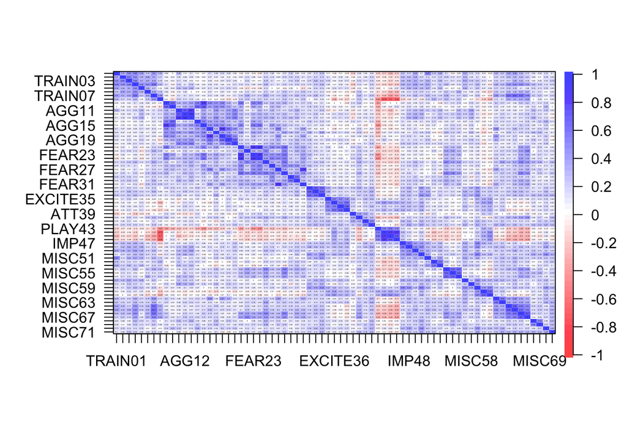

## Post-Imputation The post imputation polyserial correlation was also computed using the `lavcor` function, but with no setting for missing values since they were imputed and cor.smooth = TRUE to avoid having a non-positive-definite matrix to work on in future steps.

The minimum correlation was -0.699402. The maximum correlation was 0.8866018.

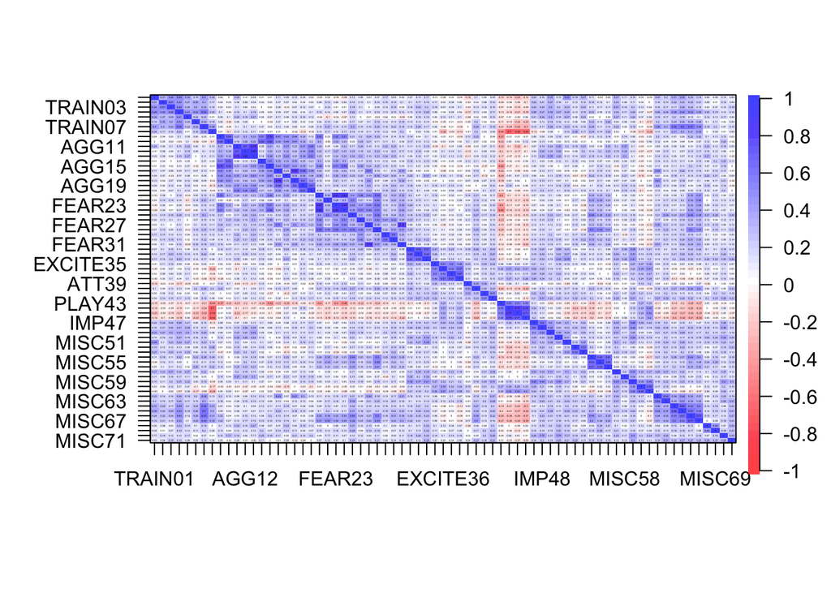

# Estimating Number of Factors

## 4.2 Parallel method

From the EFAtools documentation:

> Various methods for performing parallel analysis. This function uses future_lapply for which a parallel processing plan can be selected. To do so, call library(future) and, for example, plan(multisession); see examples.

Settings Used:  
- n.obs = 1175 - eigen_type = “EFA” - fa = “fa” (factor analysis not PCA) - fm = “wls” (weighted least squares because pa gave errors and weighted recommended for ordinal data. - use = “all.obs” (since we have imputed missing values, we can use all data points) - cor = “poly” (use polychoric correlation matrix) - n.iter = 100 (run for 100 iterations)

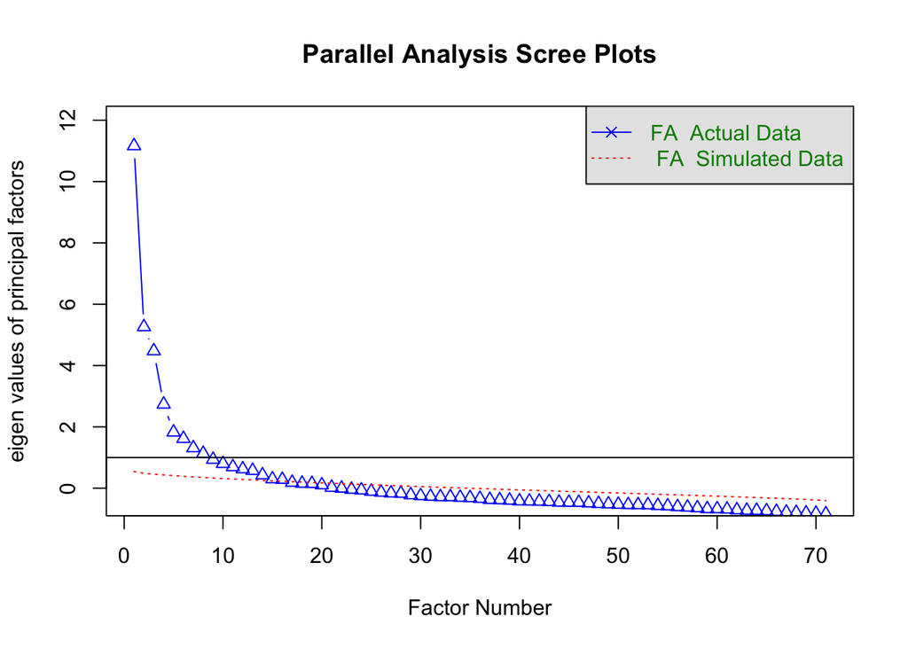

The suggested number of factors is 16.

## 4.3 Minimum Average Partial

MAP is recommended as a way to find the number of factors when the items are ordinal. The lowest value indicates the best number of factors.

| Number of Factors | MAP value |
| --- | --- |
| 1 | 0.0238 |
| 2 | 0.0199 |
| 3 | 0.0155 |
| 4 | 0.0140 |
| 5 | 0.0133 |
| 6 | 0.0125 |
| 7 | 0.0119 |
| 8 | 0.0116 |
| 9 | 0.0116 |
| 10 | 0.0113 |
| 11 | 0.0113 |
| 12 | 0.0111 |
| 13 | 0.0108 |
| 14 | 0.0110 |
| 15 | 0.0112 |
| 16 | 0.0114 |
| 17 | 0.0117 |

# 5 Factor Analyses

Testing analyses from 11 - 17 factors, since parallel analysis suggested 16 and MAP suggested 13.

## 5.1 11 Factors

### 5.1.1 11 Factors Model Fit

Although the chi-square test of goodness of fit is sensitive to departures from normality like the C-BARQ items, Hopper et al (2008) recommend always reporting it.

- chi-square: 4.0151188^{4}
- degrees of freedom: 1759
- P-value for chi-square = 0

Tucker-Lewis Index of Factoring Reliability/Non-Norm Fit Index: 0.260856. Should be > 0.9; need reference)

### 5.1.2 11 Factor Model Communalities

|  | fanal11.communality |
| --- | --- |
| TRAIN01 | 0.40 |
| TRAIN02 | 0.30 |
| TRAIN03 | 0.34 |
| TRAIN04 | 0.49 |
| TRAIN05 | 0.33 |
| TRAIN06 | 0.25 |
| TRAIN07 | 0.49 |
| TRAIN08 | 0.52 |
| AGG09 | 0.57 |
| AGG10 | 0.49 |
| AGG11 | 0.57 |
| AGG12 | 0.56 |
| AGG13 | 0.63 |
| AGG14 | 0.38 |
| AGG15 | 0.59 |
| AGG16 | 0.55 |
| AGG17 | 0.44 |
| AGG18 | 0.54 |
| AGG19 | 0.50 |
| AGG20 | 0.42 |
| FEAR21 | 0.62 |
| FEAR22 | 0.32 |
| FEAR23 | 0.61 |
| FEAR24 | 0.64 |
| FEAR25 | 0.44 |
| FEAR26 | 0.38 |
| FEAR27 | 0.44 |
| FEAR28 | 0.56 |
| FEAR29 | 0.30 |
| FEAR30 | 0.38 |
| FEAR31 | 0.39 |
| SEPR32 | 0.50 |
| SEPR33 | 0.43 |
| SEPR34 | 0.47 |
| EXCITE35 | 0.40 |
| EXCITE36 | 0.47 |
| EXCITE37 | 0.42 |
| EXCITE38 | 0.45 |
| ATT39 | 0.26 |
| ATT40 | 0.28 |
| ATT41 | 0.27 |
| ATT42 | 0.31 |
| PLAY43 | 0.49 |
| PLAY44 | 0.60 |
| PLAY45 | 0.58 |
| PLAY46 | 0.57 |
| IMP47 | 0.39 |
| IMP48 | 0.38 |
| IMP49 | 0.35 |
| MISC50 | 0.30 |
| MISC51 | 0.33 |
| MISC52 | 0.32 |
| MISC53 | 0.35 |
| MISC54 | 0.45 |
| MISC55 | 0.42 |
| MISC56 | 0.37 |
| MISC57 | 0.32 |
| MISC58 | 0.26 |
| MISC59 | 0.47 |
| MISC60 | 0.35 |
| MISC61 | 0.45 |
| MISC62 | 0.43 |
| MISC63 | 0.33 |
| MISC64 | 0.41 |
| MISC65 | 0.50 |
| MISC66 | 0.56 |
| MISC67 | 0.51 |
| MISC68 | 0.28 |
| MISC69 | 0.29 |
| MISC70 | 0.29 |
| MISC71 | 0.28 |

#### 5.1.2.1 How many communalities < 0.40?

There are 32 items with communality < 0.40.

|  | fanal11.communality | item |
| --- | --- | --- |
| TRAIN01 | 0.40 | TRAIN01 |
| TRAIN02 | 0.30 | TRAIN02 |
| TRAIN03 | 0.34 | TRAIN03 |
| TRAIN05 | 0.33 | TRAIN05 |
| TRAIN06 | 0.25 | TRAIN06 |
| AGG14 | 0.38 | AGG14 |
| FEAR22 | 0.32 | FEAR22 |
| FEAR26 | 0.38 | FEAR26 |
| FEAR29 | 0.30 | FEAR29 |
| FEAR30 | 0.38 | FEAR30 |
| FEAR31 | 0.39 | FEAR31 |
| EXCITE35 | 0.40 | EXCITE35 |
| ATT39 | 0.26 | ATT39 |
| ATT40 | 0.28 | ATT40 |
| ATT41 | 0.27 | ATT41 |
| ATT42 | 0.31 | ATT42 |
| IMP47 | 0.39 | IMP47 |
| IMP48 | 0.38 | IMP48 |
| IMP49 | 0.35 | IMP49 |
| MISC50 | 0.30 | MISC50 |
| MISC51 | 0.33 | MISC51 |
| MISC52 | 0.32 | MISC52 |
| MISC53 | 0.35 | MISC53 |
| MISC56 | 0.37 | MISC56 |
| MISC57 | 0.32 | MISC57 |
| MISC58 | 0.26 | MISC58 |
| MISC60 | 0.35 | MISC60 |
| MISC63 | 0.33 | MISC63 |
| MISC68 | 0.28 | MISC68 |
| MISC69 | 0.29 | MISC69 |
| MISC70 | 0.29 | MISC70 |
| MISC71 | 0.28 | MISC71 |

### 5.1.3 11 Factor Model Loadings

### 5.1.4 11 Factor Model Loadings

|  | WLS3 | WLS1 | WLS2 | WLS5 | WLS9 | WLS4 | WLS6 | WLS10 | WLS7 | WLS8 | WLS11 |
| --- | --- | --- | --- | --- | --- | --- | --- | --- | --- | --- | --- |
| TRAIN01 | -0.07 | 0.57 | -0.10 | -0.09 | 0.05 | 0.01 | 0.04 | -0.06 | 0.08 | 0.02 | -0.07 |
| TRAIN02 | 0.05 | 0.55 | 0.02 | -0.04 | -0.04 | -0.04 | 0.01 | 0.07 | -0.04 | 0.14 | 0.00 |
| TRAIN03 | -0.04 | 0.55 | 0.00 | -0.07 | -0.02 | -0.01 | 0.10 | 0.07 | 0.01 | 0.10 | 0.00 |
| TRAIN04 | 0.02 | 0.65 | -0.05 | 0.08 | -0.02 | 0.02 | 0.01 | 0.01 | -0.01 | -0.02 | 0.03 |
| TRAIN05 | -0.04 | 0.49 | 0.04 | -0.04 | 0.03 | 0.17 | -0.04 | 0.08 | 0.02 | -0.14 | -0.09 |
| TRAIN06 | -0.06 | 0.41 | -0.10 | 0.13 | 0.04 | -0.06 | 0.05 | -0.02 | -0.12 | 0.08 | 0.05 |
| TRAIN07 | 0.00 | 0.46 | -0.22 | 0.10 | 0.11 | -0.07 | 0.08 | 0.00 | -0.01 | -0.04 | 0.18 |
| TRAIN08 | 0.02 | 0.10 | -0.66 | 0.04 | -0.06 | 0.02 | 0.00 | 0.01 | 0.06 | 0.02 | 0.04 |
| AGG09 | 0.63 | 0.05 | 0.05 | -0.02 | 0.21 | 0.07 | 0.02 | -0.06 | -0.01 | -0.14 | -0.11 |
| AGG10 | 0.46 | -0.01 | 0.08 | -0.12 | 0.27 | 0.05 | 0.11 | -0.03 | -0.01 | -0.06 | -0.25 |
| AGG11 | 0.02 | 0.02 | -0.09 | 0.00 | 0.02 | 0.69 | 0.06 | -0.06 | 0.08 | 0.02 | -0.05 |
| AGG12 | 0.08 | -0.03 | -0.09 | 0.06 | 0.03 | 0.71 | -0.02 | 0.08 | -0.03 | -0.01 | 0.06 |
| AGG13 | 0.11 | 0.03 | -0.04 | 0.05 | 0.04 | 0.72 | -0.04 | 0.07 | 0.01 | 0.02 | -0.02 |
| AGG14 | 0.41 | -0.02 | -0.03 | 0.00 | 0.24 | -0.07 | 0.12 | 0.00 | 0.09 | -0.09 | -0.24 |
| AGG15 | 0.63 | 0.03 | 0.02 | -0.09 | 0.17 | 0.14 | 0.02 | -0.07 | -0.02 | -0.06 | -0.15 |
| AGG16 | 0.10 | 0.02 | 0.01 | 0.01 | 0.68 | 0.04 | -0.05 | -0.03 | -0.03 | 0.01 | -0.02 |
| AGG17 | 0.28 | 0.06 | 0.07 | 0.18 | 0.12 | 0.20 | 0.19 | 0.05 | -0.25 | 0.01 | -0.22 |
| AGG18 | 0.07 | 0.01 | 0.06 | -0.04 | 0.68 | 0.07 | 0.00 | -0.03 | 0.01 | 0.00 | -0.05 |
| AGG19 | -0.06 | -0.01 | 0.11 | 0.01 | 0.55 | 0.29 | 0.08 | 0.08 | -0.12 | 0.05 | -0.01 |
| AGG20 | -0.15 | -0.08 | 0.01 | 0.01 | 0.36 | 0.46 | 0.09 | 0.00 | -0.01 | 0.12 | 0.02 |
| FEAR21 | 0.71 | -0.01 | -0.02 | 0.08 | -0.06 | 0.05 | 0.00 | 0.04 | -0.01 | 0.11 | 0.10 |
| FEAR22 | 0.10 | -0.01 | -0.08 | 0.23 | -0.01 | 0.05 | 0.08 | 0.03 | -0.04 | 0.17 | 0.27 |
| FEAR23 | 0.71 | -0.04 | -0.01 | 0.11 | -0.01 | 0.00 | 0.01 | 0.03 | 0.00 | 0.05 | 0.09 |
| FEAR24 | 0.72 | -0.06 | -0.10 | 0.06 | -0.02 | 0.03 | -0.02 | 0.06 | 0.01 | 0.10 | 0.10 |
| FEAR25 | 0.20 | 0.09 | -0.03 | 0.40 | -0.01 | 0.09 | 0.03 | 0.05 | 0.03 | 0.06 | 0.15 |
| FEAR26 | 0.36 | 0.04 | 0.06 | 0.01 | 0.01 | 0.07 | 0.11 | 0.00 | 0.06 | 0.35 | 0.03 |
| FEAR27 | 0.20 | -0.04 | -0.01 | 0.18 | 0.41 | -0.04 | -0.13 | 0.02 | 0.13 | 0.23 | 0.05 |
| FEAR28 | 0.38 | 0.03 | 0.03 | 0.35 | -0.05 | 0.03 | 0.06 | 0.04 | -0.07 | 0.20 | 0.20 |
| FEAR29 | 0.06 | 0.11 | -0.02 | 0.01 | 0.07 | 0.01 | 0.16 | 0.02 | 0.07 | 0.46 | -0.10 |
| FEAR30 | 0.02 | 0.08 | 0.03 | 0.11 | 0.08 | 0.09 | 0.20 | -0.04 | 0.06 | 0.46 | 0.00 |
| FEAR31 | 0.11 | -0.02 | -0.04 | 0.19 | 0.33 | -0.06 | -0.08 | 0.03 | 0.15 | 0.29 | 0.11 |
| SEPR32 | 0.06 | -0.05 | 0.00 | -0.02 | 0.00 | -0.01 | 0.69 | 0.09 | -0.07 | 0.06 | 0.04 |
| SEPR33 | -0.06 | 0.04 | -0.01 | -0.02 | -0.01 | 0.03 | 0.64 | 0.04 | 0.00 | 0.07 | 0.03 |
| SEPR34 | -0.02 | 0.06 | 0.00 | 0.10 | -0.05 | 0.00 | 0.64 | -0.01 | 0.04 | -0.01 | -0.11 |
| EXCITE35 | 0.07 | -0.01 | -0.09 | -0.07 | 0.01 | -0.08 | 0.14 | 0.59 | 0.02 | -0.04 | 0.02 |
| EXCITE36 | 0.01 | 0.04 | 0.20 | 0.02 | -0.03 | 0.00 | -0.01 | 0.60 | -0.06 | -0.01 | 0.00 |
| EXCITE37 | -0.02 | 0.04 | -0.03 | -0.03 | 0.02 | 0.06 | 0.02 | 0.65 | -0.02 | -0.01 | -0.03 |
| EXCITE38 | -0.06 | 0.01 | 0.09 | 0.07 | -0.01 | 0.08 | -0.06 | 0.63 | 0.00 | 0.04 | -0.06 |
| ATT39 | 0.15 | -0.27 | -0.12 | -0.14 | 0.10 | -0.20 | 0.19 | 0.27 | 0.10 | -0.02 | 0.11 |
| ATT40 | 0.11 | -0.03 | -0.28 | 0.10 | 0.10 | -0.12 | 0.24 | 0.13 | 0.08 | 0.03 | 0.09 |
| ATT41 | -0.06 | -0.17 | -0.07 | 0.01 | 0.06 | 0.01 | 0.18 | 0.18 | 0.33 | -0.03 | 0.14 |
| ATT42 | -0.05 | -0.05 | -0.09 | 0.12 | 0.13 | -0.01 | 0.17 | 0.19 | 0.32 | -0.02 | 0.05 |
| PLAY43 | -0.40 | -0.05 | 0.48 | 0.08 | -0.02 | -0.07 | -0.07 | 0.08 | 0.06 | 0.01 | 0.06 |
| PLAY44 | -0.05 | 0.00 | 0.74 | 0.01 | 0.08 | -0.05 | 0.01 | 0.08 | -0.04 | 0.02 | 0.01 |
| PLAY45 | 0.03 | -0.08 | 0.71 | -0.03 | 0.03 | -0.11 | -0.03 | 0.05 | 0.02 | 0.01 | 0.02 |
| PLAY46 | 0.02 | -0.01 | 0.69 | -0.02 | -0.05 | 0.00 | 0.03 | 0.05 | -0.07 | -0.03 | -0.11 |
| IMP47 | 0.07 | 0.31 | 0.31 | -0.01 | -0.01 | 0.03 | 0.03 | 0.13 | 0.30 | 0.08 | -0.04 |
| IMP48 | 0.03 | 0.24 | 0.22 | 0.01 | 0.02 | 0.17 | 0.06 | 0.11 | 0.31 | 0.07 | 0.05 |
| IMP49 | 0.04 | 0.41 | 0.05 | 0.02 | -0.02 | 0.18 | -0.07 | 0.14 | 0.20 | 0.08 | -0.06 |
| MISC50 | -0.02 | 0.14 | 0.08 | 0.18 | -0.06 | 0.19 | 0.20 | 0.11 | 0.15 | -0.08 | -0.07 |
| MISC51 | -0.09 | 0.26 | -0.10 | 0.03 | 0.02 | 0.06 | 0.24 | 0.03 | 0.20 | -0.09 | -0.15 |
| MISC52 | -0.01 | 0.00 | -0.26 | -0.02 | 0.00 | 0.06 | -0.03 | 0.06 | 0.47 | 0.16 | -0.04 |
| MISC53 | -0.13 | 0.12 | -0.19 | -0.09 | -0.05 | 0.19 | 0.02 | 0.02 | 0.43 | 0.13 | -0.08 |
| MISC54 | 0.02 | 0.06 | -0.10 | 0.51 | 0.03 | 0.02 | 0.03 | 0.02 | -0.02 | 0.16 | 0.09 |
| MISC55 | 0.02 | -0.06 | 0.03 | 0.62 | 0.02 | 0.04 | 0.02 | -0.02 | -0.07 | 0.07 | 0.01 |
| MISC56 | 0.02 | 0.01 | -0.02 | 0.53 | -0.02 | 0.16 | -0.01 | -0.05 | -0.02 | 0.05 | 0.07 |
| MISC57 | -0.07 | 0.25 | 0.08 | -0.03 | 0.00 | 0.15 | 0.13 | 0.12 | 0.23 | -0.08 | 0.07 |
| MISC58 | 0.00 | 0.03 | 0.12 | -0.01 | -0.05 | 0.38 | 0.25 | -0.14 | 0.08 | -0.12 | 0.14 |
| MISC59 | 0.03 | 0.14 | 0.29 | 0.02 | -0.05 | 0.10 | 0.35 | 0.02 | 0.27 | -0.06 | 0.15 |
| MISC60 | 0.03 | 0.03 | 0.31 | 0.00 | -0.07 | -0.05 | 0.09 | 0.18 | 0.24 | -0.16 | 0.16 |
| MISC61 | 0.07 | -0.02 | 0.41 | -0.08 | -0.05 | 0.01 | 0.18 | 0.20 | 0.14 | -0.22 | 0.11 |
| MISC62 | -0.02 | 0.20 | -0.03 | 0.06 | 0.47 | -0.07 | -0.02 | 0.05 | 0.17 | -0.06 | 0.20 |
| MISC63 | 0.03 | 0.19 | -0.03 | 0.16 | 0.19 | -0.02 | -0.06 | 0.14 | 0.24 | -0.09 | 0.17 |
| MISC64 | -0.03 | 0.32 | -0.22 | 0.14 | 0.18 | -0.08 | 0.14 | -0.04 | 0.01 | -0.12 | 0.16 |
| MISC65 | -0.04 | 0.37 | -0.18 | 0.12 | 0.25 | -0.10 | 0.13 | -0.05 | 0.09 | -0.05 | 0.18 |
| MISC66 | 0.20 | 0.30 | -0.16 | 0.25 | 0.05 | -0.08 | 0.12 | -0.06 | 0.02 | 0.01 | 0.26 |
| MISC67 | 0.19 | 0.20 | -0.17 | 0.17 | 0.09 | -0.01 | 0.14 | -0.06 | 0.01 | 0.00 | 0.34 |
| MISC68 | -0.06 | 0.07 | 0.02 | 0.45 | 0.03 | 0.07 | 0.04 | 0.08 | 0.05 | -0.12 | -0.28 |
| MISC69 | 0.01 | -0.02 | -0.07 | 0.45 | 0.04 | -0.01 | 0.07 | 0.06 | 0.18 | -0.18 | -0.20 |
| MISC70 | 0.08 | 0.02 | 0.14 | 0.05 | 0.10 | 0.07 | 0.15 | -0.02 | 0.37 | -0.08 | -0.01 |
| MISC71 | 0.02 | 0.01 | 0.02 | 0.34 | -0.04 | -0.10 | 0.14 | -0.05 | 0.32 | -0.08 | -0.03 |

### 5.1.5 11 Factor Model Largest Loading Per Item

Largest Loading Per Item and Associated Factors, Sorted by Factor

|  | largest | maximum | itemNames | itemDescriptions |
| --- | --- | --- | --- | --- |
| 34 | WLS1 | 0.41 | IMP49 | Is difficult to interrupt or distract when doing things s/he wants to do |
| 36 | WLS1 | 0.26 | MISC51 | Escapes or would escape from home, yard or kennel given the chance |
| 42 | WLS1 | 0.25 | MISC57 | Pulls excessively hard when on leash |
| 49 | WLS1 | 0.32 | MISC64 | When working, is easily distracted or preoccupied by odors/engages in persistent sniffing of ground or objects |
| 50 | WLS1 | 0.37 | MISC65 | Has difficulty shifting attention away from interesting or distracting stimuli (e.g., other dogs, odor, people, small animals, etc.) |
| 51 | WLS1 | 0.30 | MISC66 | Is distracted or nervous in new, unfamiliar environments, has difficulty maintaining focus on work |
| 64 | WLS1 | 0.57 | TRAIN01 | Is hard to recall when off the leash |
| 65 | WLS1 | 0.55 | TRAIN02 | Is slow to obey a ‘sit’ command |
| 66 | WLS1 | 0.55 | TRAIN03 | Is slow to obey a ‘stay’ command |
| 67 | WLS1 | 0.65 | TRAIN04 | Has difficulty attending/listening to things you say or do |
| 68 | WLS1 | 0.49 | TRAIN05 | Is slow to respond to corrections or reprimands: thick-skinned |
| 69 | WLS1 | 0.41 | TRAIN06 | Is slow to learn new tricks or tasks |
| 70 | WLS1 | 0.46 | TRAIN07 | Unfocused; is easily distracted by interesting sights, sounds or smells |
| 71 | WLS1 | 0.10 | TRAIN08 | Is uninterested in ‘fetching’ or attempting to fetch sticks, toys, balls, or objects |
| 13 | WLS10 | 0.27 | ATT39 | Displays a strong attachment for you or another familiar person |
| 17 | WLS10 | 0.59 | EXCITE35 | Excitable when you first arrive home, or at the dog’s kennel, after a brief absence |
| 18 | WLS10 | 0.60 | EXCITE36 | Excitable when playing with you or other familiar persons |
| 19 | WLS10 | 0.65 | EXCITE37 | Excitable just before being taken out for a walk |
| 20 | WLS10 | 0.63 | EXCITE38 | Excitable just before being taken out for work or training |
| 22 | WLS11 | 0.27 | FEAR22 | In response to sudden or loud noises (e.g., gun fire, car backfire, road drills, objects being dropped, etc.) |
| 52 | WLS11 | 0.34 | MISC67 | Is slow to recover after being distracted, startled, or frightened/takes a long time to resume work |
| 32 | WLS2 | 0.31 | IMP47 | Impulsive; doesn’t seem to think before s/he acts |
| 45 | WLS2 | 0.31 | MISC60 | Playful, puppyish, boisterous |
| 46 | WLS2 | 0.41 | MISC61 | Active, energetic, always on the go |
| 57 | WLS2 | 0.48 | PLAY43 | Eagerly engages in play with new/unfamiliar people |
| 58 | WLS2 | 0.74 | PLAY44 | Highly toy focused; attention riveted on tug toy/balls when these are held by handler or other person |
| 59 | WLS2 | 0.71 | PLAY45 | Eagerly initiates play sessions; brings objects/toys to you/the handler and retrieves them when thrown |
| 60 | WLS2 | 0.69 | PLAY46 | Hunts persistently for thrown or hidden toys/objects, not easily distracted from this task |
| 1 | WLS3 | 0.63 | AGG09 | Barks, growls, attempts to bite when approached directly by an unfamiliar person while being walked/exercised on a leash |
| 2 | WLS3 | 0.46 | AGG10 | Barks, etc. when unfamiliar persons approach the dog when s/he is in his/her kennel |
| 6 | WLS3 | 0.41 | AGG14 | When strangers walk past when the dog is in his/her home run or kennel |
| 7 | WLS3 | 0.63 | AGG15 | When an unfamiliar person tries to touch or pet the dog |
| 9 | WLS3 | 0.28 | AGG17 | When stared at directly by you or another familiar person |
| 21 | WLS3 | 0.71 | FEAR21 | When an unfamiliar person approaches the dog when s/he is away from his/her normal home environment or kennel |
| 23 | WLS3 | 0.71 | FEAR23 | When an unfamiliar person visits your home or approaches the dog when in his/her home kennel |
| 24 | WLS3 | 0.72 | FEAR24 | When an unfamiliar person tries to touch or pet the dog |
| 26 | WLS3 | 0.36 | FEAR26 | When examined/treated by a veterinarian |
| 28 | WLS3 | 0.38 | FEAR28 | When first exposed to unfamiliar situations (e.g., novel environments, first visit to the veterinarian, etc.) |
| 3 | WLS4 | 0.69 | AGG11 | Barks, etc. when toys, bones or other objects are taken away by you or another familiar person |
| 4 | WLS4 | 0.71 | AGG12 | When you or another familiar person approaches the dog directly while s/he is eating |
| 5 | WLS4 | 0.72 | AGG13 | When his/her food is taken away by you or another familiar person |
| 12 | WLS4 | 0.46 | AGG20 | When approached while playing with/chewing a favorite toy, bone, object, etc. by another familiar dog |
| 43 | WLS4 | 0.38 | MISC58 | Urinates against objects/furnishings indoors |
| 25 | WLS5 | 0.40 | FEAR25 | In response to strange or unfamiliar objects on or near sidewalks or walkways (e.g., plastic trash bags, leaves, litter, flags flapping, etc. |
| 39 | WLS5 | 0.51 | MISC54 | Reluctant to/nervous about crossing grates or other unfamiliar surfaces |
| 40 | WLS5 | 0.62 | MISC55 | Reluctant to/nervous about crossing shiny or slippery floors |
| 41 | WLS5 | 0.53 | MISC56 | Nervous or frightened when ascending or descending some types of stairs |
| 53 | WLS5 | 0.45 | MISC68 | Chases own tail/hind end |
| 54 | WLS5 | 0.45 | MISC69 | Chases/follows shadows, light spots, etc. |
| 56 | WLS5 | 0.34 | MISC71 | Licks people or objects excessively |
| 14 | WLS6 | 0.24 | ATT40 | Unwilling to leave your side, even when working, reluctant to work at a distance from you/the handler |
| 35 | WLS6 | 0.20 | MISC50 | Displays repetitive behavior (circling, pacing, barking, tail-chasing, etc.) |
| 44 | WLS6 | 0.35 | MISC59 | Hyperactive, restless, has trouble settling down |
| 61 | WLS6 | 0.69 | SEPR32 | Restlessness/agitation/pacing when left alone |
| 62 | WLS6 | 0.64 | SEPR33 | Barking or whining when left alone |
| 63 | WLS6 | 0.64 | SEPR34 | Chewing/scratching at doors, floor, fencing, etc., when left alone |
| 15 | WLS7 | 0.33 | ATT41 | Tends to nudge or paw you (or others) for attention |
| 16 | WLS7 | 0.32 | ATT42 | Becomes agitated (whines, jumps up, tries to intervene) when attention is given to another person or animal |
| 33 | WLS7 | 0.31 | IMP48 | Becomes frustrated/impatient in a wide range of situations |
| 37 | WLS7 | 0.47 | MISC52 | Begs persistently for food when people are eating |
| 38 | WLS7 | 0.43 | MISC53 | Steals food |
| 48 | WLS7 | 0.24 | MISC63 | Becomes highly excited and/or distracted when encountering unfamiliar people |
| 55 | WLS7 | 0.37 | MISC70 | Barks persistently when alarmed or excited |
| 29 | WLS8 | 0.46 | FEAR29 | When having nails trimmed, or feet touched/handled |
| 30 | WLS8 | 0.46 | FEAR30 | When groomed or bathed |
| 8 | WLS9 | 0.68 | AGG16 | When approached directly by an unfamiliar dog while being walked/exercised on a leash |
| 10 | WLS9 | 0.68 | AGG18 | When barked, growled, or lunged at by another dog |
| 11 | WLS9 | 0.55 | AGG19 | Towards other familiar dogs |
| 27 | WLS9 | 0.41 | FEAR27 | When approached directly by an unfamiliar dog |
| 31 | WLS9 | 0.33 | FEAR31 | When barked, growled, or lunged at by an unfamiliar dog |
| 47 | WLS9 | 0.47 | MISC62 | Becomes highly excited and/or distracted when encountering unfamiliar dogs |

## 5.2 12 Factors

### 5.2.1 12 Factors Model Fit

Although the chi-square test of goodness of fit is sensitive to departures from normality like the C-BARQ items, Hopper et al (2008) recommend always reporting it.

- chi-square: 3.9323964^{4}
- degrees of freedom: 1699
- P-value for chi-square = 0

Tucker-Lewis Index of Factoring Reliability/Non-Norm Fit Index: 0.2495929. Should be > 0.9; need reference)

### 5.2.2 12 Factor Model Communalities

|  | fanal12.communality |
| --- | --- |
| TRAIN01 | 0.40 |
| TRAIN02 | 0.30 |
| TRAIN03 | 0.35 |
| TRAIN04 | 0.50 |
| TRAIN05 | 0.33 |
| TRAIN06 | 0.26 |
| TRAIN07 | 0.49 |
| TRAIN08 | 0.53 |
| AGG09 | 0.58 |
| AGG10 | 0.50 |
| AGG11 | 0.57 |
| AGG12 | 0.56 |
| AGG13 | 0.64 |
| AGG14 | 0.39 |
| AGG15 | 0.59 |
| AGG16 | 0.55 |
| AGG17 | 0.45 |
| AGG18 | 0.54 |
| AGG19 | 0.50 |
| AGG20 | 0.42 |
| FEAR21 | 0.62 |
| FEAR22 | 0.32 |
| FEAR23 | 0.62 |
| FEAR24 | 0.65 |
| FEAR25 | 0.44 |
| FEAR26 | 0.38 |
| FEAR27 | 0.49 |
| FEAR28 | 0.56 |
| FEAR29 | 0.33 |
| FEAR30 | 0.40 |
| FEAR31 | 0.43 |
| SEPR32 | 0.51 |
| SEPR33 | 0.44 |
| SEPR34 | 0.48 |
| EXCITE35 | 0.40 |
| EXCITE36 | 0.48 |
| EXCITE37 | 0.42 |
| EXCITE38 | 0.45 |
| ATT39 | 0.27 |
| ATT40 | 0.30 |
| ATT41 | 0.27 |
| ATT42 | 0.31 |
| PLAY43 | 0.49 |
| PLAY44 | 0.61 |
| PLAY45 | 0.59 |
| PLAY46 | 0.58 |
| IMP47 | 0.40 |
| IMP48 | 0.38 |
| IMP49 | 0.35 |
| MISC50 | 0.31 |
| MISC51 | 0.33 |
| MISC52 | 0.33 |
| MISC53 | 0.35 |
| MISC54 | 0.46 |
| MISC55 | 0.42 |
| MISC56 | 0.37 |
| MISC57 | 0.32 |
| MISC58 | 0.26 |
| MISC59 | 0.48 |
| MISC60 | 0.35 |
| MISC61 | 0.45 |
| MISC62 | 0.43 |
| MISC63 | 0.34 |
| MISC64 | 0.44 |
| MISC65 | 0.51 |
| MISC66 | 0.57 |
| MISC67 | 0.52 |
| MISC68 | 0.28 |
| MISC69 | 0.30 |
| MISC70 | 0.29 |
| MISC71 | 0.28 |

#### 5.2.2.1 How many communalities < 0.40?

There are 30 items with communality < 0.40.

|  | fanal12.communality | item |
| --- | --- | --- |
| TRAIN01 | 0.40 | TRAIN01 |
| TRAIN02 | 0.30 | TRAIN02 |
| TRAIN03 | 0.35 | TRAIN03 |
| TRAIN05 | 0.33 | TRAIN05 |
| TRAIN06 | 0.26 | TRAIN06 |
| AGG14 | 0.39 | AGG14 |
| FEAR22 | 0.32 | FEAR22 |
| FEAR26 | 0.38 | FEAR26 |
| FEAR29 | 0.33 | FEAR29 |
| FEAR30 | 0.40 | FEAR30 |
| ATT39 | 0.27 | ATT39 |
| ATT40 | 0.30 | ATT40 |
| ATT41 | 0.27 | ATT41 |
| ATT42 | 0.31 | ATT42 |
| IMP47 | 0.40 | IMP47 |
| IMP48 | 0.38 | IMP48 |
| IMP49 | 0.35 | IMP49 |
| MISC50 | 0.31 | MISC50 |
| MISC51 | 0.33 | MISC51 |
| MISC52 | 0.33 | MISC52 |
| MISC53 | 0.35 | MISC53 |
| MISC56 | 0.37 | MISC56 |
| MISC57 | 0.32 | MISC57 |
| MISC58 | 0.26 | MISC58 |
| MISC60 | 0.35 | MISC60 |
| MISC63 | 0.34 | MISC63 |
| MISC68 | 0.28 | MISC68 |
| MISC69 | 0.30 | MISC69 |
| MISC70 | 0.29 | MISC70 |
| MISC71 | 0.28 | MISC71 |

### 5.2.3 12 Factor Model Loadings

### 5.2.4 12 Factor Model Loadings

|  | WLS8 | WLS2 | WLS11 | WLS4 | WLS6 | WLS1 | WLS12 | WLS10 | WLS5 | WLS7 | WLS3 | WLS9 |
| --- | --- | --- | --- | --- | --- | --- | --- | --- | --- | --- | --- | --- |
| TRAIN01 | -0.12 | -0.11 | 0.52 | 0.00 | 0.04 | 0.09 | 0.03 | -0.05 | -0.06 | 0.07 | 0.07 | 0.04 |
| TRAIN02 | 0.09 | -0.01 | 0.52 | -0.06 | 0.03 | 0.02 | -0.01 | 0.07 | -0.04 | -0.04 | -0.04 | 0.11 |
| TRAIN03 | -0.01 | -0.03 | 0.51 | -0.03 | 0.12 | 0.04 | 0.01 | 0.07 | -0.06 | 0.00 | -0.05 | 0.07 |
| TRAIN04 | 0.03 | -0.08 | 0.59 | 0.01 | 0.04 | 0.14 | 0.00 | 0.01 | 0.07 | -0.02 | -0.02 | -0.03 |
| TRAIN05 | -0.11 | 0.02 | 0.45 | 0.17 | -0.03 | 0.06 | 0.01 | 0.08 | 0.00 | 0.02 | 0.12 | -0.10 |
| TRAIN06 | 0.00 | -0.12 | 0.37 | -0.07 | 0.07 | 0.09 | 0.07 | -0.02 | 0.10 | -0.13 | -0.10 | 0.06 |
| TRAIN07 | 0.00 | -0.18 | 0.33 | -0.04 | 0.05 | 0.39 | 0.05 | 0.00 | 0.05 | -0.03 | -0.02 | 0.03 |
| TRAIN08 | 0.05 | -0.66 | 0.08 | 0.02 | 0.01 | 0.08 | -0.04 | 0.02 | 0.03 | 0.05 | -0.05 | 0.01 |
| AGG09 | 0.39 | 0.06 | 0.02 | 0.10 | -0.01 | 0.08 | 0.15 | -0.06 | 0.00 | -0.01 | 0.44 | -0.05 |
| AGG10 | 0.17 | 0.10 | -0.03 | 0.08 | 0.06 | -0.02 | 0.19 | -0.02 | -0.06 | 0.00 | 0.51 | 0.04 |
| AGG11 | -0.01 | -0.10 | 0.04 | 0.69 | 0.07 | -0.07 | 0.02 | -0.06 | 0.02 | 0.08 | 0.03 | 0.03 |
| AGG12 | 0.09 | -0.09 | -0.02 | 0.71 | -0.02 | 0.01 | 0.03 | 0.07 | 0.04 | -0.03 | -0.03 | -0.01 |
| AGG13 | 0.05 | -0.02 | 0.02 | 0.73 | -0.06 | 0.01 | 0.01 | 0.07 | 0.04 | 0.02 | 0.08 | 0.06 |
| AGG14 | 0.16 | -0.01 | -0.04 | -0.05 | 0.08 | 0.01 | 0.17 | 0.00 | 0.05 | 0.09 | 0.47 | 0.01 |
| AGG15 | 0.39 | 0.03 | 0.01 | 0.17 | -0.01 | 0.01 | 0.12 | -0.07 | -0.05 | -0.01 | 0.44 | 0.01 |
| AGG16 | 0.02 | 0.00 | 0.01 | 0.04 | -0.03 | 0.06 | 0.66 | -0.03 | 0.00 | -0.05 | 0.13 | -0.01 |
| AGG17 | 0.10 | 0.08 | 0.03 | 0.21 | 0.14 | -0.02 | 0.05 | 0.05 | 0.19 | -0.24 | 0.34 | 0.12 |
| AGG18 | -0.03 | 0.05 | 0.00 | 0.07 | 0.02 | 0.03 | 0.65 | -0.02 | -0.04 | -0.01 | 0.16 | -0.01 |
| AGG19 | -0.10 | 0.11 | -0.01 | 0.29 | 0.09 | 0.01 | 0.52 | 0.08 | 0.00 | -0.13 | 0.05 | 0.03 |
| AGG20 | -0.15 | 0.02 | -0.07 | 0.46 | 0.08 | -0.01 | 0.34 | 0.00 | -0.01 | -0.01 | -0.04 | 0.12 |
| FEAR21 | 0.70 | -0.03 | 0.00 | 0.06 | 0.03 | 0.02 | 0.00 | 0.02 | 0.03 | -0.02 | 0.08 | 0.07 |
| FEAR22 | 0.24 | -0.05 | -0.05 | 0.06 | 0.07 | 0.20 | 0.01 | 0.02 | 0.13 | -0.05 | -0.24 | 0.14 |
| FEAR23 | 0.70 | -0.03 | -0.02 | 0.00 | 0.04 | 0.01 | 0.06 | 0.02 | 0.07 | -0.01 | 0.09 | 0.00 |
| FEAR24 | 0.71 | -0.11 | -0.04 | 0.04 | 0.01 | 0.01 | 0.04 | 0.05 | 0.01 | 0.00 | 0.08 | 0.04 |
| FEAR25 | 0.28 | -0.01 | 0.05 | 0.11 | 0.02 | 0.18 | 0.00 | 0.04 | 0.32 | 0.01 | -0.10 | 0.07 |
| FEAR26 | 0.35 | 0.07 | 0.04 | 0.08 | 0.08 | -0.01 | 0.02 | 0.00 | -0.03 | 0.07 | 0.03 | 0.35 |
| FEAR27 | 0.30 | -0.06 | 0.02 | -0.07 | -0.05 | -0.09 | 0.52 | 0.01 | 0.13 | 0.10 | -0.13 | 0.09 |
| FEAR28 | 0.47 | 0.05 | 0.00 | 0.05 | 0.05 | 0.16 | -0.03 | 0.03 | 0.24 | -0.09 | -0.12 | 0.18 |
| FEAR29 | -0.01 | 0.03 | 0.07 | 0.02 | 0.08 | 0.00 | 0.01 | 0.02 | -0.02 | 0.08 | 0.08 | 0.54 |
| FEAR30 | 0.01 | 0.08 | 0.04 | 0.10 | 0.13 | 0.06 | 0.03 | -0.04 | 0.05 | 0.06 | -0.01 | 0.52 |
| FEAR31 | 0.26 | -0.08 | 0.03 | -0.09 | -0.01 | -0.07 | 0.44 | 0.02 | 0.12 | 0.11 | -0.23 | 0.15 |
| SEPR32 | 0.08 | -0.02 | -0.05 | -0.02 | 0.70 | 0.00 | 0.02 | 0.08 | -0.04 | -0.08 | 0.00 | 0.05 |
| SEPR33 | -0.03 | -0.03 | 0.04 | 0.01 | 0.64 | 0.02 | 0.00 | 0.03 | -0.02 | -0.01 | -0.03 | 0.07 |
| SEPR34 | -0.05 | -0.02 | 0.07 | -0.03 | 0.65 | -0.04 | -0.04 | -0.01 | 0.12 | 0.03 | 0.08 | 0.01 |
| EXCITE35 | 0.09 | -0.09 | 0.00 | -0.08 | 0.16 | 0.01 | 0.02 | 0.58 | -0.06 | 0.02 | 0.00 | -0.06 |
| EXCITE36 | 0.01 | 0.22 | 0.02 | 0.02 | -0.03 | 0.04 | -0.07 | 0.60 | 0.02 | -0.05 | 0.02 | 0.03 |
| EXCITE37 | 0.00 | -0.03 | 0.05 | 0.06 | 0.03 | -0.03 | 0.02 | 0.64 | -0.02 | -0.01 | -0.01 | -0.01 |
| EXCITE38 | -0.02 | 0.09 | 0.04 | 0.08 | -0.04 | -0.09 | 0.00 | 0.62 | 0.08 | 0.00 | -0.05 | 0.02 |
| ATT39 | 0.08 | -0.05 | -0.33 | -0.16 | 0.12 | 0.19 | 0.02 | 0.27 | -0.15 | 0.11 | 0.10 | 0.05 |
| ATT40 | 0.03 | -0.20 | -0.14 | -0.08 | 0.16 | 0.30 | 0.00 | 0.13 | 0.06 | 0.08 | 0.12 | 0.15 |
| ATT41 | -0.05 | -0.02 | -0.20 | 0.04 | 0.15 | 0.19 | 0.01 | 0.18 | -0.01 | 0.32 | -0.05 | 0.01 |
| ATT42 | -0.05 | -0.07 | -0.08 | 0.00 | 0.16 | 0.12 | 0.11 | 0.19 | 0.11 | 0.30 | -0.01 | 0.01 |
| PLAY43 | -0.29 | 0.48 | -0.04 | -0.07 | -0.07 | -0.02 | -0.02 | 0.08 | 0.07 | 0.05 | -0.21 | -0.01 |
| PLAY44 | -0.05 | 0.74 | 0.00 | -0.04 | 0.00 | -0.01 | 0.06 | 0.08 | 0.00 | -0.04 | 0.00 | 0.02 |
| PLAY45 | 0.01 | 0.72 | -0.07 | -0.10 | -0.04 | -0.02 | 0.01 | 0.04 | -0.04 | 0.03 | 0.02 | 0.02 |
| PLAY46 | -0.03 | 0.68 | 0.01 | 0.00 | 0.02 | -0.12 | -0.06 | 0.05 | 0.01 | -0.06 | 0.10 | -0.02 |
| IMP47 | 0.08 | 0.29 | 0.32 | 0.02 | 0.06 | -0.05 | 0.04 | 0.12 | 0.01 | 0.29 | -0.01 | 0.05 |
| IMP48 | 0.05 | 0.22 | 0.23 | 0.16 | 0.07 | 0.06 | 0.03 | 0.10 | 0.01 | 0.30 | -0.05 | 0.06 |
| IMP49 | 0.02 | 0.05 | 0.39 | 0.17 | -0.06 | 0.01 | -0.01 | 0.14 | 0.04 | 0.20 | 0.03 | 0.09 |
| MISC50 | -0.01 | 0.05 | 0.15 | 0.17 | 0.23 | -0.03 | -0.03 | 0.10 | 0.20 | 0.13 | 0.01 | -0.09 |
| MISC51 | -0.15 | -0.11 | 0.25 | 0.05 | 0.25 | -0.01 | 0.02 | 0.03 | 0.08 | 0.19 | 0.12 | -0.06 |
| MISC52 | -0.05 | -0.21 | -0.01 | 0.06 | -0.07 | 0.04 | -0.03 | 0.06 | 0.00 | 0.47 | 0.04 | 0.20 |
| MISC53 | -0.14 | -0.18 | 0.13 | 0.17 | 0.02 | -0.05 | -0.05 | 0.02 | -0.04 | 0.43 | 0.00 | 0.14 |
| MISC54 | 0.08 | -0.05 | -0.01 | 0.04 | -0.02 | 0.21 | -0.01 | 0.02 | 0.41 | -0.04 | -0.08 | 0.23 |
| MISC55 | 0.09 | 0.04 | -0.08 | 0.04 | 0.01 | 0.08 | 0.03 | -0.02 | 0.54 | -0.10 | -0.08 | 0.10 |
| MISC56 | 0.09 | 0.00 | -0.03 | 0.17 | -0.03 | 0.14 | -0.03 | -0.06 | 0.44 | -0.05 | -0.10 | 0.08 |
| MISC57 | -0.03 | 0.06 | 0.24 | 0.14 | 0.16 | 0.08 | 0.02 | 0.12 | -0.01 | 0.21 | -0.07 | -0.11 |
| MISC58 | 0.05 | 0.10 | 0.03 | 0.37 | 0.28 | 0.07 | -0.02 | -0.15 | -0.02 | 0.07 | -0.10 | -0.15 |
| MISC59 | 0.08 | 0.28 | 0.13 | 0.09 | 0.37 | 0.12 | -0.03 | 0.01 | 0.00 | 0.24 | -0.09 | -0.08 |
| MISC60 | 0.08 | 0.32 | 0.01 | -0.04 | 0.11 | 0.14 | -0.07 | 0.17 | -0.01 | 0.23 | -0.08 | -0.17 |
| MISC61 | 0.08 | 0.40 | -0.03 | 0.02 | 0.19 | 0.08 | -0.05 | 0.19 | -0.07 | 0.13 | -0.01 | -0.23 |
| MISC62 | -0.02 | 0.00 | 0.12 | -0.05 | -0.03 | 0.33 | 0.43 | 0.05 | 0.02 | 0.14 | -0.03 | -0.05 |
| MISC63 | 0.01 | 0.03 | 0.09 | 0.01 | -0.10 | 0.36 | 0.12 | 0.13 | 0.12 | 0.22 | 0.00 | -0.02 |
| MISC64 | -0.12 | -0.13 | 0.15 | -0.03 | 0.05 | 0.50 | 0.04 | -0.03 | 0.08 | 0.00 | 0.11 | 0.03 |
| MISC65 | -0.09 | -0.12 | 0.22 | -0.06 | 0.07 | 0.45 | 0.15 | -0.05 | 0.06 | 0.07 | 0.04 | 0.06 |
| MISC66 | 0.21 | -0.10 | 0.16 | -0.04 | 0.07 | 0.44 | -0.01 | -0.06 | 0.15 | 0.00 | -0.03 | 0.09 |
| MISC67 | 0.22 | -0.11 | 0.07 | 0.04 | 0.09 | 0.47 | 0.02 | -0.06 | 0.06 | -0.01 | -0.07 | 0.06 |
| MISC68 | -0.13 | 0.00 | 0.09 | 0.05 | 0.05 | -0.10 | 0.02 | 0.09 | 0.48 | 0.03 | 0.17 | -0.06 |
| MISC69 | -0.02 | -0.10 | 0.01 | -0.03 | 0.10 | -0.06 | 0.07 | 0.06 | 0.47 | 0.15 | 0.12 | -0.16 |
| MISC70 | 0.05 | 0.13 | 0.03 | 0.07 | 0.17 | 0.03 | 0.12 | -0.03 | 0.08 | 0.34 | 0.06 | -0.09 |
| MISC71 | 0.00 | 0.04 | -0.02 | -0.09 | 0.12 | 0.13 | -0.07 | -0.06 | 0.33 | 0.30 | 0.06 | -0.02 |

### 5.2.5 12 Factor Model Largest Loading Per Item

Largest Loading Per Item and Associated Factors, Sorted by Factor

|  | largest | maximum | itemNames | itemDescriptions |
| --- | --- | --- | --- | --- |
| 14 | WLS1 | 0.30 | ATT40 | Unwilling to leave your side, even when working, reluctant to work at a distance from you/the handler |
| 48 | WLS1 | 0.36 | MISC63 | Becomes highly excited and/or distracted when encountering unfamiliar people |
| 49 | WLS1 | 0.50 | MISC64 | When working, is easily distracted or preoccupied by odors/engages in persistent sniffing of ground or objects |
| 50 | WLS1 | 0.45 | MISC65 | Has difficulty shifting attention away from interesting or distracting stimuli (e.g., other dogs, odor, people, small animals, etc.) |
| 51 | WLS1 | 0.44 | MISC66 | Is distracted or nervous in new, unfamiliar environments, has difficulty maintaining focus on work |
| 52 | WLS1 | 0.47 | MISC67 | Is slow to recover after being distracted, startled, or frightened/takes a long time to resume work |
| 70 | WLS1 | 0.39 | TRAIN07 | Unfocused; is easily distracted by interesting sights, sounds or smells |
| 71 | WLS1 | 0.08 | TRAIN08 | Is uninterested in ‘fetching’ or attempting to fetch sticks, toys, balls, or objects |
| 13 | WLS10 | 0.27 | ATT39 | Displays a strong attachment for you or another familiar person |
| 17 | WLS10 | 0.58 | EXCITE35 | Excitable when you first arrive home, or at the dog’s kennel, after a brief absence |
| 18 | WLS10 | 0.60 | EXCITE36 | Excitable when playing with you or other familiar persons |
| 19 | WLS10 | 0.64 | EXCITE37 | Excitable just before being taken out for a walk |
| 20 | WLS10 | 0.62 | EXCITE38 | Excitable just before being taken out for work or training |
| 32 | WLS11 | 0.32 | IMP47 | Impulsive; doesn’t seem to think before s/he acts |
| 34 | WLS11 | 0.39 | IMP49 | Is difficult to interrupt or distract when doing things s/he wants to do |
| 42 | WLS11 | 0.24 | MISC57 | Pulls excessively hard when on leash |
| 64 | WLS11 | 0.52 | TRAIN01 | Is hard to recall when off the leash |
| 65 | WLS11 | 0.52 | TRAIN02 | Is slow to obey a ‘sit’ command |
| 66 | WLS11 | 0.51 | TRAIN03 | Is slow to obey a ‘stay’ command |
| 67 | WLS11 | 0.59 | TRAIN04 | Has difficulty attending/listening to things you say or do |
| 68 | WLS11 | 0.45 | TRAIN05 | Is slow to respond to corrections or reprimands: thick-skinned |
| 69 | WLS11 | 0.37 | TRAIN06 | Is slow to learn new tricks or tasks |
| 8 | WLS12 | 0.66 | AGG16 | When approached directly by an unfamiliar dog while being walked/exercised on a leash |
| 10 | WLS12 | 0.65 | AGG18 | When barked, growled, or lunged at by another dog |
| 11 | WLS12 | 0.52 | AGG19 | Towards other familiar dogs |
| 27 | WLS12 | 0.52 | FEAR27 | When approached directly by an unfamiliar dog |
| 31 | WLS12 | 0.44 | FEAR31 | When barked, growled, or lunged at by an unfamiliar dog |
| 47 | WLS12 | 0.43 | MISC62 | Becomes highly excited and/or distracted when encountering unfamiliar dogs |
| 45 | WLS2 | 0.32 | MISC60 | Playful, puppyish, boisterous |
| 46 | WLS2 | 0.40 | MISC61 | Active, energetic, always on the go |
| 57 | WLS2 | 0.48 | PLAY43 | Eagerly engages in play with new/unfamiliar people |
| 58 | WLS2 | 0.74 | PLAY44 | Highly toy focused; attention riveted on tug toy/balls when these are held by handler or other person |
| 59 | WLS2 | 0.72 | PLAY45 | Eagerly initiates play sessions; brings objects/toys to you/the handler and retrieves them when thrown |
| 60 | WLS2 | 0.68 | PLAY46 | Hunts persistently for thrown or hidden toys/objects, not easily distracted from this task |
| 1 | WLS3 | 0.44 | AGG09 | Barks, growls, attempts to bite when approached directly by an unfamiliar person while being walked/exercised on a leash |
| 2 | WLS3 | 0.51 | AGG10 | Barks, etc. when unfamiliar persons approach the dog when s/he is in his/her kennel |
| 6 | WLS3 | 0.47 | AGG14 | When strangers walk past when the dog is in his/her home run or kennel |
| 7 | WLS3 | 0.44 | AGG15 | When an unfamiliar person tries to touch or pet the dog |
| 9 | WLS3 | 0.34 | AGG17 | When stared at directly by you or another familiar person |
| 3 | WLS4 | 0.69 | AGG11 | Barks, etc. when toys, bones or other objects are taken away by you or another familiar person |
| 4 | WLS4 | 0.71 | AGG12 | When you or another familiar person approaches the dog directly while s/he is eating |
| 5 | WLS4 | 0.73 | AGG13 | When his/her food is taken away by you or another familiar person |
| 12 | WLS4 | 0.46 | AGG20 | When approached while playing with/chewing a favorite toy, bone, object, etc. by another familiar dog |
| 43 | WLS4 | 0.37 | MISC58 | Urinates against objects/furnishings indoors |
| 25 | WLS5 | 0.32 | FEAR25 | In response to strange or unfamiliar objects on or near sidewalks or walkways (e.g., plastic trash bags, leaves, litter, flags flapping, etc. |
| 39 | WLS5 | 0.41 | MISC54 | Reluctant to/nervous about crossing grates or other unfamiliar surfaces |
| 40 | WLS5 | 0.54 | MISC55 | Reluctant to/nervous about crossing shiny or slippery floors |
| 41 | WLS5 | 0.44 | MISC56 | Nervous or frightened when ascending or descending some types of stairs |
| 53 | WLS5 | 0.48 | MISC68 | Chases own tail/hind end |
| 54 | WLS5 | 0.47 | MISC69 | Chases/follows shadows, light spots, etc. |
| 56 | WLS5 | 0.33 | MISC71 | Licks people or objects excessively |
| 35 | WLS6 | 0.23 | MISC50 | Displays repetitive behavior (circling, pacing, barking, tail-chasing, etc.) |
| 36 | WLS6 | 0.25 | MISC51 | Escapes or would escape from home, yard or kennel given the chance |
| 44 | WLS6 | 0.37 | MISC59 | Hyperactive, restless, has trouble settling down |
| 61 | WLS6 | 0.70 | SEPR32 | Restlessness/agitation/pacing when left alone |
| 62 | WLS6 | 0.64 | SEPR33 | Barking or whining when left alone |
| 63 | WLS6 | 0.65 | SEPR34 | Chewing/scratching at doors, floor, fencing, etc., when left alone |
| 15 | WLS7 | 0.32 | ATT41 | Tends to nudge or paw you (or others) for attention |
| 16 | WLS7 | 0.30 | ATT42 | Becomes agitated (whines, jumps up, tries to intervene) when attention is given to another person or animal |
| 33 | WLS7 | 0.30 | IMP48 | Becomes frustrated/impatient in a wide range of situations |
| 37 | WLS7 | 0.47 | MISC52 | Begs persistently for food when people are eating |
| 38 | WLS7 | 0.43 | MISC53 | Steals food |
| 55 | WLS7 | 0.34 | MISC70 | Barks persistently when alarmed or excited |
| 21 | WLS8 | 0.70 | FEAR21 | When an unfamiliar person approaches the dog when s/he is away from his/her normal home environment or kennel |
| 22 | WLS8 | 0.24 | FEAR22 | In response to sudden or loud noises (e.g., gun fire, car backfire, road drills, objects being dropped, etc.) |
| 23 | WLS8 | 0.70 | FEAR23 | When an unfamiliar person visits your home or approaches the dog when in his/her home kennel |
| 24 | WLS8 | 0.71 | FEAR24 | When an unfamiliar person tries to touch or pet the dog |
| 28 | WLS8 | 0.47 | FEAR28 | When first exposed to unfamiliar situations (e.g., novel environments, first visit to the veterinarian, etc.) |
| 26 | WLS9 | 0.35 | FEAR26 | When examined/treated by a veterinarian |
| 29 | WLS9 | 0.54 | FEAR29 | When having nails trimmed, or feet touched/handled |
| 30 | WLS9 | 0.52 | FEAR30 | When groomed or bathed |

## 5.3 13 Factors

### 5.3.1 13 Factors Model Fit

Although the chi-square test of goodness of fit is sensitive to departures from normality like the C-BARQ items, Hopper et al (2008) recommend always reporting it.

- chi-square: 3.8619342^{4}
- degrees of freedom: 1640
- P-value for chi-square = 0

Tucker-Lewis Index of Factoring Reliability/Non-Norm Fit Index: 0.2354747. Should be > 0.9; need reference)

### 5.3.2 13 Factor Model Communalities

|  | fanal13.communality |
| --- | --- |
| TRAIN01 | 0.40 |
| TRAIN02 | 0.31 |
| TRAIN03 | 0.37 |
| TRAIN04 | 0.50 |
| TRAIN05 | 0.33 |
| TRAIN06 | 0.26 |
| TRAIN07 | 0.50 |
| TRAIN08 | 0.53 |
| AGG09 | 0.58 |
| AGG10 | 0.51 |
| AGG11 | 0.57 |
| AGG12 | 0.56 |
| AGG13 | 0.65 |
| AGG14 | 0.40 |
| AGG15 | 0.60 |
| AGG16 | 0.56 |
| AGG17 | 0.46 |
| AGG18 | 0.55 |
| AGG19 | 0.50 |
| AGG20 | 0.42 |
| FEAR21 | 0.62 |
| FEAR22 | 0.33 |
| FEAR23 | 0.62 |
| FEAR24 | 0.65 |
| FEAR25 | 0.44 |
| FEAR26 | 0.38 |
| FEAR27 | 0.50 |
| FEAR28 | 0.56 |
| FEAR29 | 0.33 |
| FEAR30 | 0.40 |
| FEAR31 | 0.44 |
| SEPR32 | 0.51 |
| SEPR33 | 0.44 |
| SEPR34 | 0.48 |
| EXCITE35 | 0.40 |
| EXCITE36 | 0.48 |
| EXCITE37 | 0.42 |
| EXCITE38 | 0.45 |
| ATT39 | 0.27 |
| ATT40 | 0.31 |
| ATT41 | 0.27 |
| ATT42 | 0.31 |
| PLAY43 | 0.49 |
| PLAY44 | 0.61 |
| PLAY45 | 0.59 |
| PLAY46 | 0.58 |
| IMP47 | 0.40 |
| IMP48 | 0.38 |
| IMP49 | 0.36 |
| MISC50 | 0.32 |
| MISC51 | 0.33 |
| MISC52 | 0.34 |
| MISC53 | 0.35 |
| MISC54 | 0.48 |
| MISC55 | 0.46 |
| MISC56 | 0.41 |
| MISC57 | 0.32 |
| MISC58 | 0.26 |
| MISC59 | 0.48 |
| MISC60 | 0.35 |
| MISC61 | 0.45 |
| MISC62 | 0.43 |
| MISC63 | 0.34 |
| MISC64 | 0.45 |
| MISC65 | 0.52 |
| MISC66 | 0.57 |
| MISC67 | 0.52 |
| MISC68 | 0.32 |
| MISC69 | 0.31 |
| MISC70 | 0.31 |
| MISC71 | 0.28 |

#### 5.3.2.1 How many communalities < 0.40?

There are 28 items with communality < 0.40.

|  | fanal13.communality | item |
| --- | --- | --- |
| TRAIN01 | 0.40 | TRAIN01 |
| TRAIN02 | 0.31 | TRAIN02 |
| TRAIN03 | 0.37 | TRAIN03 |
| TRAIN05 | 0.33 | TRAIN05 |
| TRAIN06 | 0.26 | TRAIN06 |
| FEAR22 | 0.33 | FEAR22 |
| FEAR26 | 0.38 | FEAR26 |
| FEAR29 | 0.33 | FEAR29 |
| FEAR30 | 0.40 | FEAR30 |
| ATT39 | 0.27 | ATT39 |
| ATT40 | 0.31 | ATT40 |
| ATT41 | 0.27 | ATT41 |
| ATT42 | 0.31 | ATT42 |
| IMP47 | 0.40 | IMP47 |
| IMP48 | 0.38 | IMP48 |
| IMP49 | 0.36 | IMP49 |
| MISC50 | 0.32 | MISC50 |
| MISC51 | 0.33 | MISC51 |
| MISC52 | 0.34 | MISC52 |
| MISC53 | 0.35 | MISC53 |
| MISC57 | 0.32 | MISC57 |
| MISC58 | 0.26 | MISC58 |
| MISC60 | 0.35 | MISC60 |
| MISC63 | 0.34 | MISC63 |
| MISC68 | 0.32 | MISC68 |
| MISC69 | 0.31 | MISC69 |
| MISC70 | 0.31 | MISC70 |
| MISC71 | 0.28 | MISC71 |

### 5.3.3 13 Factor Model Loadings

### 5.3.4 13 Factor Model Loadings

|  | WLS2 | WLS12 | WLS1 | WLS4 | WLS6 | WLS5 | WLS13 | WLS10 | WLS8 | WLS3 | WLS7 | WLS11 | WLS9 |
| --- | --- | --- | --- | --- | --- | --- | --- | --- | --- | --- | --- | --- | --- |
| TRAIN01 | -0.11 | -0.12 | 0.14 | 0.00 | 0.04 | -0.09 | 0.47 | -0.05 | 0.02 | 0.06 | 0.06 | 0.05 | 0.06 |
| TRAIN02 | -0.04 | 0.04 | 0.01 | -0.09 | 0.04 | 0.08 | 0.52 | 0.09 | 0.01 | 0.02 | 0.02 | -0.07 | 0.08 |
| TRAIN03 | -0.07 | -0.05 | 0.02 | -0.07 | 0.13 | 0.06 | 0.52 | 0.10 | 0.02 | 0.01 | 0.07 | -0.07 | 0.04 |
| TRAIN04 | -0.06 | 0.05 | 0.22 | 0.03 | 0.03 | 0.00 | 0.52 | 0.00 | -0.01 | -0.05 | -0.04 | 0.12 | -0.01 |
| TRAIN05 | 0.02 | -0.11 | 0.11 | 0.17 | -0.04 | -0.08 | 0.40 | 0.09 | 0.00 | 0.10 | 0.01 | 0.10 | -0.08 |
| TRAIN06 | -0.11 | 0.00 | 0.11 | -0.07 | 0.07 | 0.13 | 0.34 | -0.02 | 0.07 | -0.10 | -0.11 | 0.02 | 0.04 |
| TRAIN07 | -0.14 | 0.03 | 0.48 | 0.00 | 0.04 | 0.00 | 0.25 | -0.02 | 0.03 | -0.07 | -0.06 | 0.07 | 0.04 |
| TRAIN08 | -0.66 | 0.04 | 0.08 | 0.01 | 0.01 | 0.05 | 0.07 | 0.02 | -0.04 | -0.04 | 0.06 | 0.01 | 0.01 |
| AGG09 | 0.04 | 0.28 | 0.08 | 0.09 | -0.02 | 0.00 | 0.01 | -0.04 | 0.11 | 0.53 | -0.02 | 0.03 | -0.04 |
| AGG10 | 0.07 | 0.05 | -0.03 | 0.05 | 0.05 | -0.04 | -0.01 | 0.00 | 0.15 | 0.60 | 0.00 | 0.00 | 0.05 |
| AGG11 | -0.09 | 0.00 | -0.06 | 0.70 | 0.06 | -0.04 | 0.02 | -0.07 | 0.01 | 0.02 | 0.05 | 0.06 | 0.04 |
| AGG12 | -0.08 | 0.07 | 0.01 | 0.72 | -0.02 | 0.06 | -0.03 | 0.07 | 0.03 | -0.02 | -0.02 | -0.01 | -0.02 |
| AGG13 | -0.01 | 0.04 | 0.02 | 0.74 | -0.07 | 0.02 | 0.00 | 0.06 | 0.00 | 0.06 | 0.00 | 0.05 | 0.06 |
| AGG14 | -0.04 | 0.05 | -0.01 | -0.08 | 0.06 | 0.03 | -0.03 | 0.02 | 0.13 | 0.55 | 0.08 | 0.08 | 0.02 |
| AGG15 | 0.00 | 0.25 | -0.02 | 0.14 | -0.01 | 0.01 | 0.03 | -0.05 | 0.09 | 0.56 | 0.01 | -0.04 | 0.01 |
| AGG16 | -0.01 | -0.01 | 0.06 | 0.03 | -0.03 | 0.03 | 0.02 | -0.02 | 0.63 | 0.21 | -0.03 | -0.01 | -0.01 |
| AGG17 | 0.11 | 0.06 | 0.03 | 0.23 | 0.12 | 0.09 | 0.00 | 0.04 | 0.01 | 0.31 | -0.29 | 0.14 | 0.13 |
| AGG18 | 0.04 | -0.05 | 0.04 | 0.06 | 0.02 | -0.02 | 0.01 | -0.01 | 0.62 | 0.23 | 0.01 | 0.00 | 0.00 |
| AGG19 | 0.10 | -0.11 | 0.00 | 0.29 | 0.09 | 0.04 | 0.00 | 0.08 | 0.50 | 0.09 | -0.10 | -0.03 | 0.02 |
| AGG20 | 0.02 | -0.15 | -0.03 | 0.45 | 0.08 | 0.06 | -0.05 | 0.01 | 0.33 | -0.02 | 0.02 | -0.05 | 0.09 |
| FEAR21 | -0.03 | 0.64 | 0.02 | 0.07 | 0.03 | 0.08 | -0.01 | 0.02 | -0.02 | 0.15 | -0.03 | -0.02 | 0.07 |
| FEAR22 | -0.07 | 0.18 | 0.11 | 0.03 | 0.08 | 0.36 | -0.01 | 0.04 | 0.03 | -0.14 | 0.03 | -0.14 | 0.06 |
| FEAR23 | -0.04 | 0.63 | 0.01 | 0.01 | 0.05 | 0.10 | -0.02 | 0.02 | 0.04 | 0.18 | -0.02 | 0.02 | 0.00 |
| FEAR24 | -0.10 | 0.66 | 0.02 | 0.06 | 0.01 | 0.03 | -0.05 | 0.04 | 0.02 | 0.15 | -0.02 | 0.00 | 0.05 |
| FEAR25 | 0.00 | 0.25 | 0.17 | 0.11 | 0.02 | 0.33 | 0.02 | 0.04 | -0.01 | -0.07 | 0.00 | 0.12 | 0.03 |
| FEAR26 | 0.09 | 0.34 | 0.02 | 0.10 | 0.08 | 0.03 | 0.03 | -0.01 | 0.00 | 0.05 | 0.05 | -0.04 | 0.34 |
| FEAR27 | -0.03 | 0.37 | -0.03 | -0.02 | -0.05 | 0.03 | -0.01 | -0.02 | 0.48 | -0.13 | 0.04 | 0.15 | 0.13 |
| FEAR28 | 0.04 | 0.39 | 0.10 | 0.03 | 0.06 | 0.40 | 0.02 | 0.04 | -0.03 | -0.03 | -0.04 | -0.04 | 0.11 |
| FEAR29 | 0.06 | 0.01 | 0.04 | 0.04 | 0.07 | 0.02 | 0.05 | 0.01 | -0.01 | 0.04 | 0.04 | -0.02 | 0.52 |
| FEAR30 | 0.10 | 0.01 | 0.06 | 0.11 | 0.13 | 0.15 | 0.03 | -0.05 | 0.02 | -0.02 | 0.06 | -0.04 | 0.48 |
| FEAR31 | -0.06 | 0.33 | -0.02 | -0.05 | -0.01 | 0.08 | 0.01 | 0.00 | 0.41 | -0.23 | 0.07 | 0.10 | 0.17 |
| SEPR32 | -0.02 | 0.07 | 0.00 | -0.02 | 0.69 | 0.00 | -0.04 | 0.08 | 0.03 | 0.01 | -0.06 | -0.03 | 0.04 |
| SEPR33 | -0.03 | -0.04 | 0.02 | 0.01 | 0.63 | 0.01 | 0.04 | 0.03 | 0.01 | -0.03 | 0.01 | -0.01 | 0.06 |
| SEPR34 | -0.02 | -0.05 | -0.02 | -0.03 | 0.64 | 0.03 | 0.05 | -0.02 | -0.04 | 0.05 | 0.00 | 0.15 | 0.03 |
| EXCITE35 | -0.10 | 0.09 | 0.01 | -0.08 | 0.16 | -0.06 | -0.01 | 0.58 | 0.02 | 0.00 | 0.02 | 0.00 | -0.05 |
| EXCITE36 | 0.22 | -0.01 | 0.03 | 0.02 | -0.03 | 0.03 | 0.01 | 0.59 | -0.06 | 0.01 | -0.05 | 0.00 | 0.02 |
| EXCITE37 | -0.04 | -0.01 | -0.04 | 0.05 | 0.03 | -0.02 | 0.04 | 0.64 | 0.03 | -0.01 | -0.01 | 0.01 | -0.01 |
| EXCITE38 | 0.07 | -0.03 | -0.12 | 0.06 | -0.04 | 0.09 | 0.05 | 0.62 | 0.01 | -0.04 | 0.02 | 0.03 | 0.01 |
| ATT39 | -0.03 | 0.08 | 0.20 | -0.15 | 0.12 | -0.12 | -0.33 | 0.26 | 0.00 | 0.10 | 0.10 | -0.08 | 0.06 |
| ATT40 | -0.15 | 0.05 | 0.36 | -0.04 | 0.14 | -0.01 | -0.19 | 0.10 | -0.03 | 0.06 | 0.02 | 0.08 | 0.16 |
| ATT41 | -0.01 | -0.02 | 0.19 | 0.05 | 0.14 | -0.04 | -0.23 | 0.16 | 0.00 | -0.07 | 0.29 | 0.05 | 0.03 |
| ATT42 | -0.05 | -0.01 | 0.15 | 0.01 | 0.14 | 0.00 | -0.11 | 0.17 | 0.09 | -0.05 | 0.25 | 0.17 | 0.04 |
| PLAY43 | 0.49 | -0.21 | -0.02 | -0.06 | -0.07 | 0.02 | -0.05 | 0.06 | 0.00 | -0.27 | 0.05 | 0.04 | -0.02 |
| PLAY44 | 0.75 | -0.03 | -0.01 | -0.03 | 0.00 | -0.02 | 0.00 | 0.07 | 0.05 | -0.01 | -0.04 | 0.00 | 0.02 |
| PLAY45 | 0.72 | 0.02 | -0.03 | -0.09 | -0.04 | -0.04 | -0.06 | 0.04 | 0.01 | 0.02 | 0.02 | -0.02 | 0.02 |
| PLAY46 | 0.67 | -0.05 | -0.13 | 0.00 | 0.02 | -0.01 | 0.03 | 0.05 | -0.06 | 0.10 | -0.05 | 0.01 | -0.02 |
| IMP47 | 0.28 | 0.10 | -0.02 | 0.02 | 0.06 | -0.05 | 0.29 | 0.12 | 0.03 | 0.00 | 0.26 | 0.12 | 0.07 |
| IMP48 | 0.21 | 0.05 | 0.07 | 0.16 | 0.07 | 0.00 | 0.21 | 0.10 | 0.02 | -0.03 | 0.29 | 0.07 | 0.06 |
| IMP49 | 0.06 | 0.06 | 0.08 | 0.20 | -0.07 | -0.08 | 0.32 | 0.12 | -0.02 | -0.02 | 0.14 | 0.16 | 0.12 |
| MISC50 | 0.07 | 0.04 | 0.03 | 0.20 | 0.22 | 0.00 | 0.09 | 0.08 | -0.05 | -0.05 | 0.06 | 0.26 | -0.04 |
| MISC51 | -0.12 | -0.13 | 0.04 | 0.05 | 0.24 | -0.07 | 0.20 | 0.02 | 0.00 | 0.09 | 0.14 | 0.21 | -0.02 |
| MISC52 | -0.24 | -0.09 | 0.00 | 0.03 | -0.07 | 0.06 | 0.00 | 0.08 | -0.03 | 0.08 | 0.47 | 0.02 | 0.19 |
| MISC53 | -0.19 | -0.14 | -0.06 | 0.15 | 0.01 | -0.05 | 0.13 | 0.03 | -0.05 | 0.00 | 0.41 | 0.06 | 0.15 |
| MISC54 | -0.07 | -0.02 | 0.10 | -0.02 | -0.02 | 0.59 | 0.02 | 0.04 | 0.00 | 0.00 | 0.03 | 0.02 | 0.12 |
| MISC55 | 0.00 | -0.02 | -0.06 | -0.04 | 0.02 | 0.68 | -0.02 | 0.01 | 0.03 | 0.03 | -0.02 | 0.09 | -0.01 |
| MISC56 | -0.04 | -0.02 | 0.01 | 0.10 | -0.03 | 0.61 | 0.02 | -0.03 | -0.02 | 0.01 | 0.03 | 0.04 | -0.02 |
| MISC57 | 0.04 | -0.03 | 0.08 | 0.12 | 0.16 | -0.02 | 0.22 | 0.12 | 0.03 | -0.05 | 0.22 | 0.05 | -0.10 |
| MISC58 | 0.08 | 0.01 | 0.03 | 0.35 | 0.28 | 0.05 | 0.05 | -0.13 | -0.01 | -0.03 | 0.12 | -0.06 | -0.18 |
| MISC59 | 0.27 | 0.08 | 0.12 | 0.09 | 0.36 | 0.00 | 0.11 | 0.01 | -0.03 | -0.06 | 0.26 | 0.05 | -0.08 |
| MISC60 | 0.30 | 0.07 | 0.12 | -0.05 | 0.10 | -0.01 | 0.00 | 0.17 | -0.06 | -0.05 | 0.24 | 0.03 | -0.17 |
| MISC61 | 0.38 | 0.06 | 0.05 | 0.00 | 0.19 | -0.06 | -0.02 | 0.20 | -0.04 | 0.04 | 0.16 | -0.01 | -0.22 |
| MISC62 | 0.01 | 0.00 | 0.36 | -0.04 | -0.04 | 0.02 | 0.08 | 0.04 | 0.40 | 0.00 | 0.14 | 0.04 | -0.04 |
| MISC63 | 0.03 | -0.01 | 0.37 | 0.01 | -0.11 | 0.12 | 0.05 | 0.13 | 0.10 | 0.02 | 0.22 | 0.08 | -0.03 |
| MISC64 | -0.08 | -0.10 | 0.58 | 0.01 | 0.03 | 0.03 | 0.07 | -0.05 | 0.01 | 0.05 | -0.04 | 0.08 | 0.04 |
| MISC65 | -0.08 | -0.07 | 0.52 | -0.03 | 0.06 | 0.03 | 0.14 | -0.06 | 0.12 | 0.01 | 0.04 | 0.07 | 0.06 |
| MISC66 | -0.07 | 0.18 | 0.47 | -0.03 | 0.06 | 0.21 | 0.11 | -0.07 | -0.03 | -0.01 | 0.00 | 0.02 | 0.05 |
| MISC67 | -0.10 | 0.17 | 0.46 | 0.04 | 0.09 | 0.21 | 0.04 | -0.06 | 0.02 | -0.02 | 0.04 | -0.09 | 0.01 |
| MISC68 | 0.06 | -0.04 | 0.01 | 0.11 | 0.02 | 0.09 | -0.01 | 0.04 | -0.02 | 0.02 | -0.13 | 0.51 | 0.01 |
| MISC69 | -0.07 | 0.03 | 0.00 | 0.00 | 0.07 | 0.15 | -0.06 | 0.02 | 0.03 | 0.04 | 0.03 | 0.47 | -0.10 |
| MISC70 | 0.08 | -0.02 | -0.03 | 0.01 | 0.16 | 0.11 | 0.06 | 0.00 | 0.11 | 0.16 | 0.38 | 0.07 | -0.10 |
| MISC71 | 0.05 | 0.01 | 0.15 | -0.09 | 0.10 | 0.17 | -0.06 | -0.07 | -0.09 | 0.03 | 0.22 | 0.29 | 0.00 |

### 5.3.5 13 Factor Model Largest Loading Per Item

Largest Loading Per Item and Associated Factors, Sorted by Factor

|  | largest | maximum | itemNames | itemDescriptions |
| --- | --- | --- | --- | --- |
| 14 | WLS1 | 0.36 | ATT40 | Unwilling to leave your side, even when working, reluctant to work at a distance from you/the handler |
| 48 | WLS1 | 0.37 | MISC63 | Becomes highly excited and/or distracted when encountering unfamiliar people |
| 49 | WLS1 | 0.58 | MISC64 | When working, is easily distracted or preoccupied by odors/engages in persistent sniffing of ground or objects |
| 50 | WLS1 | 0.52 | MISC65 | Has difficulty shifting attention away from interesting or distracting stimuli (e.g., other dogs, odor, people, small animals, etc.) |
| 51 | WLS1 | 0.47 | MISC66 | Is distracted or nervous in new, unfamiliar environments, has difficulty maintaining focus on work |
| 52 | WLS1 | 0.46 | MISC67 | Is slow to recover after being distracted, startled, or frightened/takes a long time to resume work |
| 70 | WLS1 | 0.48 | TRAIN07 | Unfocused; is easily distracted by interesting sights, sounds or smells |
| 71 | WLS1 | 0.08 | TRAIN08 | Is uninterested in ‘fetching’ or attempting to fetch sticks, toys, balls, or objects |
| 13 | WLS10 | 0.26 | ATT39 | Displays a strong attachment for you or another familiar person |
| 17 | WLS10 | 0.58 | EXCITE35 | Excitable when you first arrive home, or at the dog’s kennel, after a brief absence |
| 18 | WLS10 | 0.59 | EXCITE36 | Excitable when playing with you or other familiar persons |
| 19 | WLS10 | 0.64 | EXCITE37 | Excitable just before being taken out for a walk |
| 20 | WLS10 | 0.62 | EXCITE38 | Excitable just before being taken out for work or training |
| 35 | WLS11 | 0.26 | MISC50 | Displays repetitive behavior (circling, pacing, barking, tail-chasing, etc.) |
| 53 | WLS11 | 0.51 | MISC68 | Chases own tail/hind end |
| 54 | WLS11 | 0.47 | MISC69 | Chases/follows shadows, light spots, etc. |
| 56 | WLS11 | 0.29 | MISC71 | Licks people or objects excessively |
| 21 | WLS12 | 0.64 | FEAR21 | When an unfamiliar person approaches the dog when s/he is away from his/her normal home environment or kennel |
| 23 | WLS12 | 0.63 | FEAR23 | When an unfamiliar person visits your home or approaches the dog when in his/her home kennel |
| 24 | WLS12 | 0.66 | FEAR24 | When an unfamiliar person tries to touch or pet the dog |
| 32 | WLS13 | 0.29 | IMP47 | Impulsive; doesn’t seem to think before s/he acts |
| 34 | WLS13 | 0.32 | IMP49 | Is difficult to interrupt or distract when doing things s/he wants to do |
| 64 | WLS13 | 0.47 | TRAIN01 | Is hard to recall when off the leash |
| 65 | WLS13 | 0.52 | TRAIN02 | Is slow to obey a ‘sit’ command |
| 66 | WLS13 | 0.52 | TRAIN03 | Is slow to obey a ‘stay’ command |
| 67 | WLS13 | 0.52 | TRAIN04 | Has difficulty attending/listening to things you say or do |
| 68 | WLS13 | 0.40 | TRAIN05 | Is slow to respond to corrections or reprimands: thick-skinned |
| 69 | WLS13 | 0.34 | TRAIN06 | Is slow to learn new tricks or tasks |
| 45 | WLS2 | 0.30 | MISC60 | Playful, puppyish, boisterous |
| 46 | WLS2 | 0.38 | MISC61 | Active, energetic, always on the go |
| 57 | WLS2 | 0.49 | PLAY43 | Eagerly engages in play with new/unfamiliar people |
| 58 | WLS2 | 0.75 | PLAY44 | Highly toy focused; attention riveted on tug toy/balls when these are held by handler or other person |
| 59 | WLS2 | 0.72 | PLAY45 | Eagerly initiates play sessions; brings objects/toys to you/the handler and retrieves them when thrown |
| 60 | WLS2 | 0.67 | PLAY46 | Hunts persistently for thrown or hidden toys/objects, not easily distracted from this task |
| 1 | WLS3 | 0.53 | AGG09 | Barks, growls, attempts to bite when approached directly by an unfamiliar person while being walked/exercised on a leash |
| 2 | WLS3 | 0.60 | AGG10 | Barks, etc. when unfamiliar persons approach the dog when s/he is in his/her kennel |
| 6 | WLS3 | 0.55 | AGG14 | When strangers walk past when the dog is in his/her home run or kennel |
| 7 | WLS3 | 0.56 | AGG15 | When an unfamiliar person tries to touch or pet the dog |
| 9 | WLS3 | 0.31 | AGG17 | When stared at directly by you or another familiar person |
| 3 | WLS4 | 0.70 | AGG11 | Barks, etc. when toys, bones or other objects are taken away by you or another familiar person |
| 4 | WLS4 | 0.72 | AGG12 | When you or another familiar person approaches the dog directly while s/he is eating |
| 5 | WLS4 | 0.74 | AGG13 | When his/her food is taken away by you or another familiar person |
| 12 | WLS4 | 0.45 | AGG20 | When approached while playing with/chewing a favorite toy, bone, object, etc. by another familiar dog |
| 43 | WLS4 | 0.35 | MISC58 | Urinates against objects/furnishings indoors |
| 22 | WLS5 | 0.36 | FEAR22 | In response to sudden or loud noises (e.g., gun fire, car backfire, road drills, objects being dropped, etc.) |
| 25 | WLS5 | 0.33 | FEAR25 | In response to strange or unfamiliar objects on or near sidewalks or walkways (e.g., plastic trash bags, leaves, litter, flags flapping, etc. |
| 28 | WLS5 | 0.40 | FEAR28 | When first exposed to unfamiliar situations (e.g., novel environments, first visit to the veterinarian, etc.) |
| 39 | WLS5 | 0.59 | MISC54 | Reluctant to/nervous about crossing grates or other unfamiliar surfaces |
| 40 | WLS5 | 0.68 | MISC55 | Reluctant to/nervous about crossing shiny or slippery floors |
| 41 | WLS5 | 0.61 | MISC56 | Nervous or frightened when ascending or descending some types of stairs |
| 36 | WLS6 | 0.24 | MISC51 | Escapes or would escape from home, yard or kennel given the chance |
| 44 | WLS6 | 0.36 | MISC59 | Hyperactive, restless, has trouble settling down |
| 61 | WLS6 | 0.69 | SEPR32 | Restlessness/agitation/pacing when left alone |
| 62 | WLS6 | 0.63 | SEPR33 | Barking or whining when left alone |
| 63 | WLS6 | 0.64 | SEPR34 | Chewing/scratching at doors, floor, fencing, etc., when left alone |
| 15 | WLS7 | 0.29 | ATT41 | Tends to nudge or paw you (or others) for attention |
| 16 | WLS7 | 0.25 | ATT42 | Becomes agitated (whines, jumps up, tries to intervene) when attention is given to another person or animal |
| 33 | WLS7 | 0.29 | IMP48 | Becomes frustrated/impatient in a wide range of situations |
| 37 | WLS7 | 0.47 | MISC52 | Begs persistently for food when people are eating |
| 38 | WLS7 | 0.41 | MISC53 | Steals food |
| 42 | WLS7 | 0.22 | MISC57 | Pulls excessively hard when on leash |
| 55 | WLS7 | 0.38 | MISC70 | Barks persistently when alarmed or excited |
| 8 | WLS8 | 0.63 | AGG16 | When approached directly by an unfamiliar dog while being walked/exercised on a leash |
| 10 | WLS8 | 0.62 | AGG18 | When barked, growled, or lunged at by another dog |
| 11 | WLS8 | 0.50 | AGG19 | Towards other familiar dogs |
| 27 | WLS8 | 0.48 | FEAR27 | When approached directly by an unfamiliar dog |
| 31 | WLS8 | 0.41 | FEAR31 | When barked, growled, or lunged at by an unfamiliar dog |
| 47 | WLS8 | 0.40 | MISC62 | Becomes highly excited and/or distracted when encountering unfamiliar dogs |
| 26 | WLS9 | 0.34 | FEAR26 | When examined/treated by a veterinarian |
| 29 | WLS9 | 0.52 | FEAR29 | When having nails trimmed, or feet touched/handled |
| 30 | WLS9 | 0.48 | FEAR30 | When groomed or bathed |

## 5.4 14 Factors

### 5.4.1 14 Factors Model Fit

Although the chi-square test of goodness of fit is sensitive to departures from normality like the C-BARQ items, Hopper et al (2008) recommend always reporting it.

- chi-square: 3.8201018^{4}
- degrees of freedom: 1582
- P-value for chi-square = 0

Tucker-Lewis Index of Factoring Reliability/Non-Norm Fit Index: 0.2146935. Should be > 0.9; need reference)

### 5.4.2 14 Factor Model Communalities

|  | fanal14.communality |
| --- | --- |
| TRAIN01 | 0.40 |
| TRAIN02 | 0.33 |
| TRAIN03 | 0.38 |
| TRAIN04 | 0.50 |
| TRAIN05 | 0.33 |
| TRAIN06 | 0.28 |
| TRAIN07 | 0.50 |
| TRAIN08 | 0.53 |
| AGG09 | 0.58 |
| AGG10 | 0.51 |
| AGG11 | 0.57 |
| AGG12 | 0.57 |
| AGG13 | 0.65 |
| AGG14 | 0.40 |
| AGG15 | 0.60 |
| AGG16 | 0.56 |
| AGG17 | 0.46 |
| AGG18 | 0.55 |
| AGG19 | 0.50 |
| AGG20 | 0.42 |
| FEAR21 | 0.62 |
| FEAR22 | 0.33 |
| FEAR23 | 0.62 |
| FEAR24 | 0.65 |
| FEAR25 | 0.44 |
| FEAR26 | 0.39 |
| FEAR27 | 0.50 |
| FEAR28 | 0.56 |
| FEAR29 | 0.34 |
| FEAR30 | 0.40 |
| FEAR31 | 0.44 |
| SEPR32 | 0.51 |
| SEPR33 | 0.44 |
| SEPR34 | 0.48 |
| EXCITE35 | 0.41 |
| EXCITE36 | 0.48 |
| EXCITE37 | 0.43 |
| EXCITE38 | 0.46 |
| ATT39 | 0.30 |
| ATT40 | 0.34 |
| ATT41 | 0.32 |
| ATT42 | 0.33 |
| PLAY43 | 0.49 |
| PLAY44 | 0.61 |
| PLAY45 | 0.59 |
| PLAY46 | 0.58 |
| IMP47 | 0.40 |
| IMP48 | 0.39 |
| IMP49 | 0.36 |
| MISC50 | 0.32 |
| MISC51 | 0.34 |
| MISC52 | 0.34 |
| MISC53 | 0.35 |
| MISC54 | 0.48 |
| MISC55 | 0.46 |
| MISC56 | 0.41 |
| MISC57 | 0.32 |
| MISC58 | 0.26 |
| MISC59 | 0.48 |
| MISC60 | 0.36 |
| MISC61 | 0.46 |
| MISC62 | 0.44 |
| MISC63 | 0.35 |
| MISC64 | 0.45 |
| MISC65 | 0.52 |
| MISC66 | 0.57 |
| MISC67 | 0.52 |
| MISC68 | 0.32 |
| MISC69 | 0.31 |
| MISC70 | 0.31 |
| MISC71 | 0.29 |

#### 5.4.2.1 How many communalities < 0.40?

There are 26 items with communality < 0.40.

|  | fanal14.communality | item |
| --- | --- | --- |
| TRAIN01 | 0.40 | TRAIN01 |
| TRAIN02 | 0.33 | TRAIN02 |
| TRAIN03 | 0.38 | TRAIN03 |
| TRAIN05 | 0.33 | TRAIN05 |
| TRAIN06 | 0.28 | TRAIN06 |
| FEAR22 | 0.33 | FEAR22 |
| FEAR26 | 0.39 | FEAR26 |
| FEAR29 | 0.34 | FEAR29 |
| ATT39 | 0.30 | ATT39 |
| ATT40 | 0.34 | ATT40 |
| ATT41 | 0.32 | ATT41 |
| ATT42 | 0.33 | ATT42 |
| IMP48 | 0.39 | IMP48 |
| IMP49 | 0.36 | IMP49 |
| MISC50 | 0.32 | MISC50 |
| MISC51 | 0.34 | MISC51 |
| MISC52 | 0.34 | MISC52 |
| MISC53 | 0.35 | MISC53 |
| MISC57 | 0.32 | MISC57 |
| MISC58 | 0.26 | MISC58 |
| MISC60 | 0.36 | MISC60 |
| MISC63 | 0.35 | MISC63 |
| MISC68 | 0.32 | MISC68 |
| MISC69 | 0.31 | MISC69 |
| MISC70 | 0.31 | MISC70 |
| MISC71 | 0.29 | MISC71 |

### 5.4.3 14 Factor Model Loadings

### 5.4.4 14 Factor Model Loadings

|  | WLS2 | WLS12 | WLS4 | WLS1 | WLS13 | WLS5 | WLS6 | WLS3 | WLS10 | WLS8 | WLS9 | WLS7 | WLS14 | WLS11 |
| --- | --- | --- | --- | --- | --- | --- | --- | --- | --- | --- | --- | --- | --- | --- |
| TRAIN01 | -0.13 | -0.11 | -0.01 | 0.19 | 0.41 | -0.11 | 0.04 | 0.06 | -0.02 | 0.02 | 0.09 | -0.12 | 0.10 | 0.05 |
| TRAIN02 | 0.00 | 0.03 | -0.07 | -0.03 | 0.58 | 0.08 | 0.02 | 0.02 | 0.05 | 0.00 | 0.04 | 0.00 | -0.02 | -0.07 |
| TRAIN03 | -0.04 | -0.06 | -0.05 | 0.00 | 0.56 | 0.06 | 0.11 | 0.02 | 0.07 | 0.02 | 0.02 | 0.00 | 0.04 | -0.07 |
| TRAIN04 | -0.05 | 0.05 | 0.03 | 0.22 | 0.52 | 0.00 | 0.03 | -0.05 | -0.01 | -0.01 | -0.02 | -0.07 | -0.02 | 0.12 |
| TRAIN05 | 0.04 | -0.11 | 0.18 | 0.10 | 0.41 | -0.08 | -0.04 | 0.11 | 0.06 | 0.00 | -0.09 | -0.03 | 0.01 | 0.11 |
| TRAIN06 | -0.06 | 0.00 | -0.05 | 0.05 | 0.43 | 0.14 | 0.05 | -0.09 | -0.08 | 0.07 | -0.02 | 0.04 | -0.16 | 0.02 |
| TRAIN07 | -0.14 | 0.04 | -0.01 | 0.45 | 0.25 | 0.00 | 0.03 | -0.07 | -0.03 | 0.02 | 0.04 | 0.04 | -0.07 | 0.06 |
| TRAIN08 | -0.67 | 0.04 | 0.00 | 0.09 | 0.05 | 0.05 | 0.01 | -0.04 | 0.03 | -0.04 | 0.02 | 0.01 | 0.04 | 0.01 |
| AGG09 | 0.05 | 0.28 | 0.09 | 0.07 | 0.03 | 0.00 | -0.02 | 0.53 | -0.06 | 0.10 | -0.05 | 0.03 | -0.02 | 0.03 |
| AGG10 | 0.08 | 0.05 | 0.05 | -0.04 | 0.00 | -0.04 | 0.05 | 0.60 | -0.01 | 0.14 | 0.05 | 0.01 | -0.02 | 0.00 |
| AGG11 | -0.09 | 0.00 | 0.69 | -0.03 | 0.00 | -0.04 | 0.07 | 0.02 | -0.06 | 0.01 | 0.06 | -0.04 | 0.07 | 0.07 |
| AGG12 | -0.07 | 0.07 | 0.72 | -0.02 | 0.00 | 0.06 | -0.02 | -0.02 | 0.05 | 0.02 | -0.03 | 0.03 | -0.03 | -0.01 |
| AGG13 | 0.00 | 0.04 | 0.74 | 0.02 | 0.01 | 0.02 | -0.06 | 0.06 | 0.05 | -0.01 | 0.07 | 0.00 | -0.01 | 0.05 |
| AGG14 | -0.03 | 0.04 | -0.08 | -0.03 | -0.01 | 0.04 | 0.06 | 0.56 | 0.01 | 0.13 | 0.02 | 0.07 | 0.04 | 0.08 |
| AGG15 | -0.02 | 0.25 | 0.12 | 0.03 | -0.02 | 0.00 | 0.00 | 0.56 | -0.02 | 0.09 | 0.04 | -0.08 | 0.05 | -0.03 |
| AGG16 | 0.00 | -0.01 | 0.04 | 0.06 | 0.04 | 0.04 | -0.03 | 0.22 | -0.03 | 0.62 | -0.02 | 0.02 | -0.03 | -0.01 |
| AGG17 | 0.09 | 0.07 | 0.21 | 0.08 | -0.07 | 0.09 | 0.15 | 0.30 | 0.08 | 0.02 | 0.14 | -0.17 | -0.22 | 0.14 |
| AGG18 | 0.05 | -0.05 | 0.07 | 0.03 | 0.03 | -0.02 | 0.01 | 0.23 | -0.03 | 0.61 | -0.01 | 0.03 | -0.01 | 0.00 |
| AGG19 | 0.09 | -0.10 | 0.28 | 0.04 | -0.03 | 0.04 | 0.10 | 0.09 | 0.10 | 0.50 | 0.03 | -0.08 | -0.05 | -0.03 |
| AGG20 | 0.03 | -0.15 | 0.46 | -0.05 | -0.01 | 0.06 | 0.07 | -0.01 | -0.02 | 0.33 | 0.08 | 0.06 | -0.02 | -0.05 |
| FEAR21 | -0.03 | 0.63 | 0.07 | 0.02 | 0.00 | 0.08 | 0.03 | 0.15 | 0.02 | -0.02 | 0.07 | 0.03 | -0.03 | -0.02 |
| FEAR22 | -0.06 | 0.17 | 0.04 | 0.08 | 0.02 | 0.36 | 0.07 | -0.14 | 0.03 | 0.02 | 0.05 | 0.07 | 0.01 | -0.15 |
| FEAR23 | -0.03 | 0.63 | 0.01 | 0.00 | -0.01 | 0.10 | 0.04 | 0.18 | 0.01 | 0.04 | 0.00 | 0.04 | -0.02 | 0.01 |
| FEAR24 | -0.10 | 0.66 | 0.06 | 0.01 | -0.04 | 0.03 | 0.01 | 0.15 | 0.04 | 0.02 | 0.06 | 0.04 | -0.03 | -0.01 |
| FEAR25 | 0.01 | 0.25 | 0.11 | 0.14 | 0.06 | 0.34 | 0.01 | -0.07 | 0.02 | -0.01 | 0.02 | 0.08 | -0.02 | 0.11 |
| FEAR26 | 0.08 | 0.33 | 0.09 | 0.02 | 0.01 | 0.02 | 0.08 | 0.05 | 0.00 | -0.01 | 0.36 | 0.02 | 0.01 | -0.04 |
| FEAR27 | -0.04 | 0.36 | -0.03 | -0.01 | -0.03 | 0.03 | -0.05 | -0.13 | -0.01 | 0.47 | 0.14 | 0.02 | 0.04 | 0.14 |
| FEAR28 | 0.04 | 0.39 | 0.03 | 0.08 | 0.03 | 0.40 | 0.06 | -0.03 | 0.03 | -0.03 | 0.11 | 0.02 | -0.04 | -0.05 |
| FEAR29 | 0.04 | 0.00 | 0.02 | 0.05 | 0.02 | 0.01 | 0.07 | 0.04 | 0.03 | -0.02 | 0.55 | 0.00 | -0.01 | -0.02 |
| FEAR30 | 0.08 | 0.00 | 0.09 | 0.07 | 0.00 | 0.13 | 0.13 | -0.03 | -0.03 | 0.01 | 0.51 | 0.01 | 0.01 | -0.04 |
| FEAR31 | -0.06 | 0.32 | -0.06 | -0.01 | 0.00 | 0.07 | -0.02 | -0.22 | 0.00 | 0.41 | 0.18 | 0.04 | 0.05 | 0.10 |
| SEPR32 | -0.02 | 0.07 | -0.02 | -0.02 | -0.01 | 0.00 | 0.67 | 0.01 | 0.07 | 0.03 | 0.04 | 0.06 | -0.06 | -0.03 |
| SEPR33 | -0.03 | -0.04 | 0.01 | 0.00 | 0.06 | 0.01 | 0.61 | -0.03 | 0.03 | 0.01 | 0.06 | 0.06 | 0.00 | -0.01 |
| SEPR34 | -0.04 | -0.04 | -0.04 | 0.00 | 0.03 | 0.02 | 0.62 | 0.05 | 0.00 | -0.04 | 0.05 | -0.01 | 0.03 | 0.15 |
| EXCITE35 | -0.12 | 0.09 | -0.08 | 0.01 | 0.00 | -0.06 | 0.15 | 0.01 | 0.58 | 0.02 | -0.04 | 0.07 | 0.01 | -0.01 |
| EXCITE36 | 0.21 | 0.00 | 0.01 | 0.04 | 0.01 | 0.03 | -0.03 | 0.01 | 0.60 | -0.07 | 0.02 | 0.03 | -0.05 | -0.01 |
| EXCITE37 | -0.06 | 0.00 | 0.04 | -0.02 | 0.03 | -0.02 | 0.03 | -0.01 | 0.65 | 0.03 | 0.00 | 0.01 | -0.01 | 0.01 |
| EXCITE38 | 0.05 | -0.03 | 0.05 | -0.10 | 0.03 | 0.09 | -0.04 | -0.04 | 0.63 | 0.01 | 0.02 | -0.01 | 0.02 | 0.03 |
| ATT39 | 0.02 | 0.06 | -0.11 | 0.03 | -0.15 | -0.10 | 0.07 | 0.11 | 0.15 | 0.00 | -0.01 | 0.43 | -0.10 | -0.09 |
| ATT40 | -0.10 | 0.03 | -0.01 | 0.19 | -0.02 | 0.02 | 0.10 | 0.07 | 0.00 | -0.04 | 0.09 | 0.39 | -0.17 | 0.06 |
| ATT41 | 0.05 | -0.05 | 0.09 | 0.02 | -0.02 | -0.01 | 0.08 | -0.06 | 0.04 | -0.01 | -0.04 | 0.49 | 0.07 | 0.04 |
| ATT42 | -0.02 | -0.03 | 0.04 | 0.04 | 0.02 | 0.02 | 0.10 | -0.03 | 0.10 | 0.08 | 0.00 | 0.35 | 0.09 | 0.15 |
| PLAY43 | 0.48 | -0.21 | -0.06 | 0.00 | -0.06 | 0.02 | -0.07 | -0.27 | 0.07 | 0.00 | -0.01 | 0.00 | 0.06 | 0.04 |
| PLAY44 | 0.75 | -0.02 | -0.02 | -0.01 | 0.02 | -0.01 | 0.00 | -0.02 | 0.06 | 0.05 | 0.01 | 0.00 | -0.03 | 0.00 |
| PLAY45 | 0.72 | 0.02 | -0.08 | -0.03 | -0.05 | -0.04 | -0.04 | 0.02 | 0.03 | 0.01 | 0.02 | 0.03 | 0.03 | -0.02 |
| PLAY46 | 0.67 | -0.04 | 0.00 | -0.11 | 0.01 | -0.01 | 0.03 | 0.10 | 0.06 | -0.06 | -0.02 | -0.08 | -0.01 | 0.02 |
| IMP47 | 0.28 | 0.08 | 0.03 | -0.04 | 0.33 | -0.05 | 0.04 | 0.00 | 0.09 | 0.02 | 0.08 | 0.11 | 0.20 | 0.12 |
| IMP48 | 0.22 | 0.04 | 0.17 | 0.01 | 0.28 | 0.00 | 0.04 | -0.02 | 0.06 | 0.01 | 0.06 | 0.19 | 0.20 | 0.07 |
| IMP49 | 0.07 | 0.05 | 0.20 | 0.06 | 0.35 | -0.08 | -0.08 | -0.02 | 0.10 | -0.03 | 0.12 | 0.05 | 0.09 | 0.16 |
| MISC50 | 0.08 | 0.04 | 0.20 | 0.01 | 0.13 | 0.01 | 0.20 | -0.05 | 0.06 | -0.05 | -0.05 | 0.08 | 0.04 | 0.26 |
| MISC51 | -0.15 | -0.13 | 0.03 | 0.10 | 0.13 | -0.08 | 0.24 | 0.08 | 0.07 | 0.00 | 0.03 | -0.06 | 0.18 | 0.21 |
| MISC52 | -0.26 | -0.11 | 0.02 | -0.03 | 0.02 | 0.05 | -0.10 | 0.09 | 0.07 | -0.04 | 0.22 | 0.20 | 0.34 | 0.02 |
| MISC53 | -0.22 | -0.16 | 0.14 | -0.06 | 0.12 | -0.06 | -0.01 | 0.01 | 0.04 | -0.05 | 0.20 | 0.11 | 0.33 | 0.06 |
| MISC54 | -0.07 | -0.02 | -0.01 | 0.08 | 0.05 | 0.59 | -0.02 | 0.00 | 0.03 | -0.01 | 0.12 | 0.04 | -0.01 | 0.02 |
| MISC55 | 0.01 | -0.02 | -0.03 | -0.06 | -0.01 | 0.69 | 0.02 | 0.03 | 0.01 | 0.04 | -0.02 | -0.02 | -0.01 | 0.09 |
| MISC56 | -0.04 | -0.02 | 0.09 | 0.03 | 0.00 | 0.61 | -0.02 | 0.01 | -0.01 | -0.02 | -0.01 | -0.05 | 0.06 | 0.04 |
| MISC57 | 0.01 | -0.03 | 0.11 | 0.10 | 0.19 | -0.03 | 0.15 | -0.05 | 0.14 | 0.02 | -0.06 | 0.02 | 0.24 | 0.05 |
| MISC58 | 0.06 | 0.01 | 0.34 | 0.06 | 0.02 | 0.05 | 0.28 | -0.03 | -0.11 | -0.01 | -0.14 | -0.04 | 0.18 | -0.05 |
| MISC59 | 0.24 | 0.07 | 0.08 | 0.12 | 0.10 | 0.00 | 0.35 | -0.06 | 0.02 | -0.03 | -0.04 | 0.09 | 0.26 | 0.04 |
| MISC60 | 0.26 | 0.07 | -0.07 | 0.16 | -0.05 | -0.02 | 0.11 | -0.05 | 0.21 | -0.07 | -0.11 | 0.04 | 0.28 | 0.03 |
| MISC61 | 0.33 | 0.06 | -0.01 | 0.11 | -0.08 | -0.07 | 0.20 | 0.04 | 0.25 | -0.05 | -0.17 | -0.01 | 0.23 | -0.01 |
| MISC62 | -0.02 | 0.00 | -0.06 | 0.39 | 0.03 | 0.01 | -0.03 | 0.00 | 0.07 | 0.39 | 0.00 | 0.04 | 0.16 | 0.03 |
| MISC63 | -0.01 | -0.01 | -0.01 | 0.38 | 0.01 | 0.11 | -0.11 | 0.03 | 0.16 | 0.09 | 0.02 | 0.07 | 0.21 | 0.07 |
| MISC64 | -0.10 | -0.10 | 0.00 | 0.56 | 0.05 | 0.02 | 0.04 | 0.05 | -0.04 | 0.00 | 0.05 | 0.06 | -0.05 | 0.07 |
| MISC65 | -0.10 | -0.07 | -0.04 | 0.52 | 0.11 | 0.02 | 0.06 | 0.01 | -0.05 | 0.11 | 0.09 | 0.06 | 0.03 | 0.07 |
| MISC66 | -0.08 | 0.18 | -0.03 | 0.43 | 0.12 | 0.20 | 0.06 | -0.01 | -0.07 | -0.04 | 0.06 | 0.08 | -0.02 | 0.01 |
| MISC67 | -0.10 | 0.16 | 0.04 | 0.42 | 0.07 | 0.21 | 0.08 | -0.02 | -0.07 | 0.01 | 0.02 | 0.12 | 0.01 | -0.10 |
| MISC68 | 0.06 | -0.03 | 0.10 | 0.03 | -0.03 | 0.09 | 0.03 | 0.01 | 0.05 | -0.02 | 0.00 | -0.04 | -0.11 | 0.51 |
| MISC69 | -0.06 | 0.03 | 0.01 | -0.02 | -0.02 | 0.16 | 0.07 | 0.04 | 0.00 | 0.03 | -0.12 | 0.09 | 0.00 | 0.46 |
| MISC70 | 0.06 | -0.03 | 0.01 | -0.03 | 0.06 | 0.10 | 0.15 | 0.17 | 0.00 | 0.10 | -0.06 | 0.11 | 0.35 | 0.07 |
| MISC71 | 0.04 | 0.00 | -0.10 | 0.14 | -0.06 | 0.17 | 0.10 | 0.03 | -0.06 | -0.09 | 0.02 | 0.12 | 0.19 | 0.29 |

### 5.4.5 14 Factor Model Largest Loading Per Item

Largest Loading Per Item and Associated Factors, Sorted by Factor

|  | largest | maximum | itemNames | itemDescriptions |
| --- | --- | --- | --- | --- |
| 48 | WLS1 | 0.38 | MISC63 | Becomes highly excited and/or distracted when encountering unfamiliar people |
| 49 | WLS1 | 0.56 | MISC64 | When working, is easily distracted or preoccupied by odors/engages in persistent sniffing of ground or objects |
| 50 | WLS1 | 0.52 | MISC65 | Has difficulty shifting attention away from interesting or distracting stimuli (e.g., other dogs, odor, people, small animals, etc.) |
| 51 | WLS1 | 0.43 | MISC66 | Is distracted or nervous in new, unfamiliar environments, has difficulty maintaining focus on work |
| 52 | WLS1 | 0.42 | MISC67 | Is slow to recover after being distracted, startled, or frightened/takes a long time to resume work |
| 70 | WLS1 | 0.45 | TRAIN07 | Unfocused; is easily distracted by interesting sights, sounds or smells |
| 71 | WLS1 | 0.09 | TRAIN08 | Is uninterested in ‘fetching’ or attempting to fetch sticks, toys, balls, or objects |
| 17 | WLS10 | 0.58 | EXCITE35 | Excitable when you first arrive home, or at the dog’s kennel, after a brief absence |
| 18 | WLS10 | 0.60 | EXCITE36 | Excitable when playing with you or other familiar persons |
| 19 | WLS10 | 0.65 | EXCITE37 | Excitable just before being taken out for a walk |
| 20 | WLS10 | 0.63 | EXCITE38 | Excitable just before being taken out for work or training |
| 35 | WLS11 | 0.26 | MISC50 | Displays repetitive behavior (circling, pacing, barking, tail-chasing, etc.) |
| 53 | WLS11 | 0.51 | MISC68 | Chases own tail/hind end |
| 54 | WLS11 | 0.46 | MISC69 | Chases/follows shadows, light spots, etc. |
| 56 | WLS11 | 0.29 | MISC71 | Licks people or objects excessively |
| 21 | WLS12 | 0.63 | FEAR21 | When an unfamiliar person approaches the dog when s/he is away from his/her normal home environment or kennel |
| 23 | WLS12 | 0.63 | FEAR23 | When an unfamiliar person visits your home or approaches the dog when in his/her home kennel |
| 24 | WLS12 | 0.66 | FEAR24 | When an unfamiliar person tries to touch or pet the dog |
| 32 | WLS13 | 0.33 | IMP47 | Impulsive; doesn’t seem to think before s/he acts |
| 33 | WLS13 | 0.28 | IMP48 | Becomes frustrated/impatient in a wide range of situations |
| 34 | WLS13 | 0.35 | IMP49 | Is difficult to interrupt or distract when doing things s/he wants to do |
| 64 | WLS13 | 0.41 | TRAIN01 | Is hard to recall when off the leash |
| 65 | WLS13 | 0.58 | TRAIN02 | Is slow to obey a ‘sit’ command |
| 66 | WLS13 | 0.56 | TRAIN03 | Is slow to obey a ‘stay’ command |
| 67 | WLS13 | 0.52 | TRAIN04 | Has difficulty attending/listening to things you say or do |
| 68 | WLS13 | 0.41 | TRAIN05 | Is slow to respond to corrections or reprimands: thick-skinned |
| 69 | WLS13 | 0.43 | TRAIN06 | Is slow to learn new tricks or tasks |
| 37 | WLS14 | 0.34 | MISC52 | Begs persistently for food when people are eating |
| 38 | WLS14 | 0.33 | MISC53 | Steals food |
| 42 | WLS14 | 0.24 | MISC57 | Pulls excessively hard when on leash |
| 45 | WLS14 | 0.28 | MISC60 | Playful, puppyish, boisterous |
| 55 | WLS14 | 0.35 | MISC70 | Barks persistently when alarmed or excited |
| 46 | WLS2 | 0.33 | MISC61 | Active, energetic, always on the go |
| 57 | WLS2 | 0.48 | PLAY43 | Eagerly engages in play with new/unfamiliar people |
| 58 | WLS2 | 0.75 | PLAY44 | Highly toy focused; attention riveted on tug toy/balls when these are held by handler or other person |
| 59 | WLS2 | 0.72 | PLAY45 | Eagerly initiates play sessions; brings objects/toys to you/the handler and retrieves them when thrown |
| 60 | WLS2 | 0.67 | PLAY46 | Hunts persistently for thrown or hidden toys/objects, not easily distracted from this task |
| 1 | WLS3 | 0.53 | AGG09 | Barks, growls, attempts to bite when approached directly by an unfamiliar person while being walked/exercised on a leash |
| 2 | WLS3 | 0.60 | AGG10 | Barks, etc. when unfamiliar persons approach the dog when s/he is in his/her kennel |
| 6 | WLS3 | 0.56 | AGG14 | When strangers walk past when the dog is in his/her home run or kennel |
| 7 | WLS3 | 0.56 | AGG15 | When an unfamiliar person tries to touch or pet the dog |
| 9 | WLS3 | 0.30 | AGG17 | When stared at directly by you or another familiar person |
| 3 | WLS4 | 0.69 | AGG11 | Barks, etc. when toys, bones or other objects are taken away by you or another familiar person |
| 4 | WLS4 | 0.72 | AGG12 | When you or another familiar person approaches the dog directly while s/he is eating |
| 5 | WLS4 | 0.74 | AGG13 | When his/her food is taken away by you or another familiar person |
| 12 | WLS4 | 0.46 | AGG20 | When approached while playing with/chewing a favorite toy, bone, object, etc. by another familiar dog |
| 43 | WLS4 | 0.34 | MISC58 | Urinates against objects/furnishings indoors |
| 22 | WLS5 | 0.36 | FEAR22 | In response to sudden or loud noises (e.g., gun fire, car backfire, road drills, objects being dropped, etc.) |
| 25 | WLS5 | 0.34 | FEAR25 | In response to strange or unfamiliar objects on or near sidewalks or walkways (e.g., plastic trash bags, leaves, litter, flags flapping, etc. |
| 28 | WLS5 | 0.40 | FEAR28 | When first exposed to unfamiliar situations (e.g., novel environments, first visit to the veterinarian, etc.) |
| 39 | WLS5 | 0.59 | MISC54 | Reluctant to/nervous about crossing grates or other unfamiliar surfaces |
| 40 | WLS5 | 0.69 | MISC55 | Reluctant to/nervous about crossing shiny or slippery floors |
| 41 | WLS5 | 0.61 | MISC56 | Nervous or frightened when ascending or descending some types of stairs |
| 36 | WLS6 | 0.24 | MISC51 | Escapes or would escape from home, yard or kennel given the chance |
| 44 | WLS6 | 0.35 | MISC59 | Hyperactive, restless, has trouble settling down |
| 61 | WLS6 | 0.67 | SEPR32 | Restlessness/agitation/pacing when left alone |
| 62 | WLS6 | 0.61 | SEPR33 | Barking or whining when left alone |
| 63 | WLS6 | 0.62 | SEPR34 | Chewing/scratching at doors, floor, fencing, etc., when left alone |
| 13 | WLS7 | 0.43 | ATT39 | Displays a strong attachment for you or another familiar person |
| 14 | WLS7 | 0.39 | ATT40 | Unwilling to leave your side, even when working, reluctant to work at a distance from you/the handler |
| 15 | WLS7 | 0.49 | ATT41 | Tends to nudge or paw you (or others) for attention |
| 16 | WLS7 | 0.35 | ATT42 | Becomes agitated (whines, jumps up, tries to intervene) when attention is given to another person or animal |
| 8 | WLS8 | 0.62 | AGG16 | When approached directly by an unfamiliar dog while being walked/exercised on a leash |
| 10 | WLS8 | 0.61 | AGG18 | When barked, growled, or lunged at by another dog |
| 11 | WLS8 | 0.50 | AGG19 | Towards other familiar dogs |
| 27 | WLS8 | 0.47 | FEAR27 | When approached directly by an unfamiliar dog |
| 31 | WLS8 | 0.41 | FEAR31 | When barked, growled, or lunged at by an unfamiliar dog |
| 47 | WLS8 | 0.39 | MISC62 | Becomes highly excited and/or distracted when encountering unfamiliar dogs |
| 26 | WLS9 | 0.36 | FEAR26 | When examined/treated by a veterinarian |
| 29 | WLS9 | 0.55 | FEAR29 | When having nails trimmed, or feet touched/handled |
| 30 | WLS9 | 0.51 | FEAR30 | When groomed or bathed |

## 5.5 15 Factors

### 5.5.1 15 Factors Model Fit

Although the chi-square test of goodness of fit is sensitive to departures from normality like the C-BARQ items, Hopper et al (2008) recommend always reporting it.

- chi-square: 3.7912287^{4}
- degrees of freedom: 1525
- P-value for chi-square = 0

Tucker-Lewis Index of Factoring Reliability/Non-Norm Fit Index: 0.1900067. Should be > 0.9; need reference)

### 5.5.2 15 Factor Model Communalities

|  | fanal15.communality |
| --- | --- |
| TRAIN01 | 0.40 |
| TRAIN02 | 0.33 |
| TRAIN03 | 0.38 |
| TRAIN04 | 0.50 |
| TRAIN05 | 0.33 |
| TRAIN06 | 0.28 |
| TRAIN07 | 0.50 |
| TRAIN08 | 0.53 |
| AGG09 | 0.58 |
| AGG10 | 0.51 |
| AGG11 | 0.58 |
| AGG12 | 0.57 |
| AGG13 | 0.65 |
| AGG14 | 0.41 |
| AGG15 | 0.61 |
| AGG16 | 0.56 |
| AGG17 | 0.47 |
| AGG18 | 0.55 |
| AGG19 | 0.50 |
| AGG20 | 0.43 |
| FEAR21 | 0.62 |
| FEAR22 | 0.34 |
| FEAR23 | 0.62 |
| FEAR24 | 0.65 |
| FEAR25 | 0.44 |
| FEAR26 | 0.39 |
| FEAR27 | 0.50 |
| FEAR28 | 0.56 |
| FEAR29 | 0.35 |
| FEAR30 | 0.40 |
| FEAR31 | 0.44 |
| SEPR32 | 0.51 |
| SEPR33 | 0.44 |
| SEPR34 | 0.48 |
| EXCITE35 | 0.41 |
| EXCITE36 | 0.48 |
| EXCITE37 | 0.43 |
| EXCITE38 | 0.46 |
| ATT39 | 0.31 |
| ATT40 | 0.35 |
| ATT41 | 0.32 |
| ATT42 | 0.33 |
| PLAY43 | 0.49 |
| PLAY44 | 0.61 |
| PLAY45 | 0.59 |
| PLAY46 | 0.58 |
| IMP47 | 0.40 |
| IMP48 | 0.40 |
| IMP49 | 0.36 |
| MISC50 | 0.32 |
| MISC51 | 0.34 |
| MISC52 | 0.35 |
| MISC53 | 0.36 |
| MISC54 | 0.48 |
| MISC55 | 0.46 |
| MISC56 | 0.42 |
| MISC57 | 0.33 |
| MISC58 | 0.26 |
| MISC59 | 0.48 |
| MISC60 | 0.39 |
| MISC61 | 0.47 |
| MISC62 | 0.44 |
| MISC63 | 0.35 |
| MISC64 | 0.45 |
| MISC65 | 0.52 |
| MISC66 | 0.57 |
| MISC67 | 0.53 |
| MISC68 | 0.33 |
| MISC69 | 0.31 |
| MISC70 | 0.32 |
| MISC71 | 0.29 |

#### 5.5.2.1 How many communalities < 0.40?

There are 26 items with communality < 0.40.

|  | fanal15.communality | item |
| --- | --- | --- |
| TRAIN01 | 0.40 | TRAIN01 |
| TRAIN02 | 0.33 | TRAIN02 |
| TRAIN03 | 0.38 | TRAIN03 |
| TRAIN05 | 0.33 | TRAIN05 |
| TRAIN06 | 0.28 | TRAIN06 |
| FEAR22 | 0.34 | FEAR22 |
| FEAR26 | 0.39 | FEAR26 |
| FEAR29 | 0.35 | FEAR29 |
| ATT39 | 0.31 | ATT39 |
| ATT40 | 0.35 | ATT40 |
| ATT41 | 0.32 | ATT41 |
| ATT42 | 0.33 | ATT42 |
| IMP48 | 0.40 | IMP48 |
| IMP49 | 0.36 | IMP49 |
| MISC50 | 0.32 | MISC50 |
| MISC51 | 0.34 | MISC51 |
| MISC52 | 0.35 | MISC52 |
| MISC53 | 0.36 | MISC53 |
| MISC57 | 0.33 | MISC57 |
| MISC58 | 0.26 | MISC58 |
| MISC60 | 0.39 | MISC60 |
| MISC63 | 0.35 | MISC63 |
| MISC68 | 0.33 | MISC68 |
| MISC69 | 0.31 | MISC69 |
| MISC70 | 0.32 | MISC70 |
| MISC71 | 0.29 | MISC71 |

### 5.5.3 15 Factor Model Loadings

### 5.5.4 15 Factor Model Loadings

|  | WLS2 | WLS12 | WLS1 | WLS4 | WLS13 | WLS5 | WLS6 | WLS3 | WLS8 | WLS10 | WLS9 | WLS7 | WLS14 | WLS11 | WLS15 |
| --- | --- | --- | --- | --- | --- | --- | --- | --- | --- | --- | --- | --- | --- | --- | --- |
| TRAIN01 | -0.13 | -0.11 | 0.18 | -0.01 | 0.39 | -0.10 | 0.04 | 0.06 | 0.02 | -0.02 | 0.09 | 0.09 | -0.13 | 0.05 | 0.06 |
| TRAIN02 | -0.01 | 0.03 | -0.05 | -0.05 | 0.59 | 0.09 | 0.00 | 0.01 | 0.01 | 0.03 | 0.06 | -0.02 | 0.02 | -0.05 | 0.01 |
| TRAIN03 | -0.05 | -0.06 | -0.03 | -0.04 | 0.56 | 0.07 | 0.09 | 0.01 | 0.02 | 0.04 | 0.04 | 0.02 | 0.01 | -0.06 | 0.05 |
| TRAIN04 | -0.05 | 0.06 | 0.23 | 0.03 | 0.49 | -0.01 | 0.03 | -0.05 | -0.01 | 0.00 | -0.02 | 0.02 | -0.08 | 0.12 | -0.02 |
| TRAIN05 | 0.03 | -0.11 | 0.09 | 0.18 | 0.41 | -0.07 | -0.05 | 0.10 | 0.00 | 0.06 | -0.08 | 0.01 | -0.03 | 0.11 | 0.04 |
| TRAIN06 | -0.04 | 0.00 | 0.07 | -0.04 | 0.42 | 0.13 | 0.06 | -0.10 | 0.07 | -0.06 | -0.04 | -0.05 | 0.03 | 0.03 | -0.14 |
| TRAIN07 | -0.13 | 0.03 | 0.46 | 0.00 | 0.24 | -0.02 | 0.03 | -0.08 | 0.02 | -0.02 | 0.05 | -0.05 | 0.03 | 0.07 | -0.01 |
| TRAIN08 | -0.66 | 0.04 | 0.07 | 0.01 | 0.06 | 0.05 | 0.00 | -0.04 | -0.04 | 0.01 | 0.03 | 0.01 | 0.02 | 0.01 | 0.01 |
| AGG09 | 0.05 | 0.27 | 0.06 | 0.10 | 0.04 | 0.01 | -0.02 | 0.53 | 0.11 | -0.06 | -0.03 | -0.04 | 0.04 | 0.04 | 0.00 |
| AGG10 | 0.08 | 0.05 | -0.05 | 0.05 | 0.00 | -0.04 | 0.05 | 0.59 | 0.15 | -0.01 | 0.05 | -0.01 | 0.02 | 0.01 | -0.02 |
| AGG11 | -0.10 | 0.00 | -0.05 | 0.69 | 0.00 | -0.03 | 0.06 | 0.01 | 0.02 | -0.07 | 0.08 | 0.04 | -0.04 | 0.07 | 0.05 |
| AGG12 | -0.06 | 0.07 | 0.00 | 0.72 | 0.00 | 0.06 | -0.02 | -0.02 | 0.02 | 0.05 | -0.03 | -0.01 | 0.02 | -0.01 | -0.04 |
| AGG13 | -0.01 | 0.04 | 0.01 | 0.74 | 0.01 | 0.02 | -0.06 | 0.06 | 0.00 | 0.05 | 0.07 | -0.01 | 0.01 | 0.05 | -0.01 |
| AGG14 | -0.02 | 0.04 | 0.00 | -0.09 | -0.03 | 0.02 | 0.07 | 0.56 | 0.12 | 0.03 | 0.00 | 0.10 | 0.04 | 0.07 | -0.06 |
| AGG15 | -0.03 | 0.25 | 0.01 | 0.12 | -0.01 | 0.01 | 0.00 | 0.56 | 0.09 | -0.03 | 0.05 | -0.01 | -0.07 | -0.03 | 0.04 |
| AGG16 | 0.01 | 0.00 | 0.05 | 0.04 | 0.04 | 0.04 | -0.03 | 0.21 | 0.62 | -0.03 | -0.01 | -0.02 | 0.02 | 0.00 | -0.03 |
| AGG17 | 0.12 | 0.07 | 0.11 | 0.19 | -0.08 | 0.06 | 0.17 | 0.30 | 0.01 | 0.11 | 0.11 | -0.12 | -0.17 | 0.14 | -0.17 |
| AGG18 | 0.05 | -0.05 | 0.02 | 0.07 | 0.04 | -0.01 | 0.01 | 0.22 | 0.61 | -0.03 | 0.00 | -0.01 | 0.04 | 0.01 | -0.01 |
| AGG19 | 0.09 | -0.10 | 0.03 | 0.27 | -0.02 | 0.04 | 0.10 | 0.09 | 0.50 | 0.11 | 0.04 | -0.06 | -0.07 | -0.03 | -0.02 |
| AGG20 | 0.05 | -0.15 | -0.02 | 0.45 | -0.03 | 0.04 | 0.08 | -0.01 | 0.32 | 0.01 | 0.06 | 0.06 | 0.04 | -0.06 | -0.10 |
| FEAR21 | -0.03 | 0.62 | 0.02 | 0.07 | 0.00 | 0.07 | 0.03 | 0.15 | -0.02 | 0.02 | 0.08 | -0.03 | 0.03 | -0.02 | -0.03 |
| FEAR22 | -0.04 | 0.17 | 0.14 | 0.02 | -0.01 | 0.32 | 0.09 | -0.12 | 0.01 | 0.06 | 0.02 | 0.10 | 0.03 | -0.17 | -0.11 |
| FEAR23 | -0.03 | 0.62 | 0.01 | 0.01 | -0.01 | 0.10 | 0.04 | 0.17 | 0.03 | 0.01 | 0.01 | -0.02 | 0.04 | 0.01 | -0.02 |
| FEAR24 | -0.10 | 0.65 | 0.02 | 0.06 | -0.04 | 0.03 | 0.01 | 0.15 | 0.02 | 0.03 | 0.07 | -0.03 | 0.05 | 0.00 | -0.02 |
| FEAR25 | 0.03 | 0.24 | 0.18 | 0.11 | 0.04 | 0.31 | 0.02 | -0.06 | -0.02 | 0.04 | 0.00 | 0.06 | 0.06 | 0.09 | -0.08 |
| FEAR26 | 0.06 | 0.31 | 0.00 | 0.09 | 0.03 | 0.03 | 0.06 | 0.04 | -0.01 | -0.02 | 0.38 | -0.01 | 0.03 | -0.03 | 0.01 |
| FEAR27 | -0.04 | 0.36 | -0.01 | -0.03 | -0.04 | 0.03 | -0.05 | -0.13 | 0.46 | 0.00 | 0.14 | 0.08 | 0.01 | 0.13 | -0.04 |
| FEAR28 | 0.05 | 0.38 | 0.12 | 0.02 | 0.02 | 0.37 | 0.07 | -0.02 | -0.03 | 0.05 | 0.10 | 0.00 | 0.01 | -0.05 | -0.08 |
| FEAR29 | 0.02 | -0.02 | 0.01 | 0.03 | 0.04 | 0.02 | 0.05 | 0.02 | -0.01 | 0.00 | 0.56 | -0.03 | 0.02 | 0.00 | 0.00 |
| FEAR30 | 0.08 | -0.02 | 0.07 | 0.09 | 0.00 | 0.13 | 0.12 | -0.03 | 0.01 | -0.03 | 0.49 | 0.05 | 0.00 | -0.04 | -0.05 |
| FEAR31 | -0.05 | 0.32 | 0.00 | -0.07 | -0.01 | 0.06 | -0.01 | -0.22 | 0.40 | 0.02 | 0.17 | 0.12 | 0.02 | 0.08 | -0.06 |
| SEPR32 | -0.01 | 0.06 | -0.01 | -0.02 | -0.01 | -0.01 | 0.67 | 0.01 | 0.02 | 0.08 | 0.04 | -0.05 | 0.07 | -0.03 | -0.01 |
| SEPR33 | -0.03 | -0.04 | 0.00 | 0.01 | 0.07 | 0.01 | 0.60 | -0.03 | 0.01 | 0.02 | 0.07 | -0.02 | 0.07 | -0.01 | 0.04 |
| SEPR34 | -0.03 | -0.04 | 0.01 | -0.04 | 0.02 | 0.02 | 0.62 | 0.05 | -0.04 | 0.01 | 0.04 | 0.04 | -0.01 | 0.13 | 0.02 |
| EXCITE35 | -0.13 | 0.08 | -0.01 | -0.08 | 0.01 | -0.06 | 0.14 | 0.00 | 0.02 | 0.56 | -0.02 | -0.04 | 0.09 | 0.00 | 0.08 |
| EXCITE36 | 0.20 | -0.01 | 0.03 | 0.01 | 0.01 | 0.02 | -0.04 | 0.01 | -0.07 | 0.58 | 0.03 | -0.06 | 0.04 | 0.00 | 0.03 |
| EXCITE37 | -0.06 | 0.00 | -0.01 | 0.03 | 0.02 | -0.03 | 0.03 | -0.01 | 0.02 | 0.65 | -0.01 | 0.01 | 0.01 | 0.00 | 0.00 |
| EXCITE38 | 0.06 | -0.03 | -0.07 | 0.04 | 0.01 | 0.07 | -0.03 | -0.03 | 0.00 | 0.65 | -0.01 | 0.07 | -0.03 | 0.01 | -0.02 |
| ATT39 | 0.00 | 0.04 | -0.01 | -0.09 | -0.09 | -0.08 | 0.04 | 0.09 | 0.01 | 0.11 | 0.03 | -0.13 | 0.47 | -0.06 | 0.04 |
| ATT40 | -0.07 | 0.02 | 0.24 | -0.01 | -0.03 | -0.01 | 0.11 | 0.07 | -0.05 | 0.02 | 0.06 | -0.02 | 0.36 | 0.06 | -0.19 |
| ATT41 | 0.04 | -0.05 | 0.00 | 0.11 | 0.00 | 0.00 | 0.06 | -0.07 | 0.00 | 0.01 | -0.02 | 0.08 | 0.49 | 0.04 | 0.06 |
| ATT42 | -0.04 | -0.03 | 0.02 | 0.05 | 0.03 | 0.03 | 0.08 | -0.04 | 0.08 | 0.07 | 0.02 | 0.09 | 0.35 | 0.16 | 0.08 |
| PLAY43 | 0.46 | -0.21 | -0.01 | -0.07 | -0.06 | 0.02 | -0.07 | -0.27 | 0.00 | 0.07 | 0.00 | 0.04 | -0.01 | 0.04 | 0.08 |
| PLAY44 | 0.74 | -0.02 | -0.01 | -0.02 | 0.01 | -0.02 | 0.00 | -0.02 | 0.05 | 0.06 | 0.01 | -0.02 | 0.00 | 0.00 | 0.03 |
| PLAY45 | 0.70 | 0.02 | -0.04 | -0.09 | -0.05 | -0.04 | -0.04 | 0.02 | 0.01 | 0.03 | 0.02 | 0.01 | 0.03 | -0.02 | 0.07 |
| PLAY46 | 0.65 | -0.04 | -0.11 | -0.01 | 0.01 | -0.01 | 0.03 | 0.10 | -0.06 | 0.06 | -0.01 | -0.02 | -0.07 | 0.01 | 0.04 |
| IMP47 | 0.28 | 0.09 | -0.01 | 0.02 | 0.28 | -0.06 | 0.04 | 0.01 | 0.01 | 0.11 | 0.05 | 0.27 | 0.06 | 0.09 | 0.04 |
| IMP48 | 0.23 | 0.04 | 0.05 | 0.16 | 0.23 | -0.02 | 0.05 | -0.01 | 0.00 | 0.08 | 0.02 | 0.28 | 0.13 | 0.04 | 0.02 |
| IMP49 | 0.08 | 0.05 | 0.09 | 0.19 | 0.31 | -0.09 | -0.08 | -0.01 | -0.04 | 0.12 | 0.10 | 0.17 | 0.02 | 0.14 | -0.03 |
| MISC50 | 0.09 | 0.04 | 0.03 | 0.20 | 0.10 | 0.00 | 0.21 | -0.05 | -0.05 | 0.07 | -0.07 | 0.11 | 0.05 | 0.24 | -0.01 |
| MISC51 | -0.15 | -0.13 | 0.11 | 0.02 | 0.10 | -0.09 | 0.25 | 0.09 | 0.00 | 0.08 | 0.01 | 0.19 | -0.09 | 0.18 | 0.07 |
| MISC52 | -0.26 | -0.11 | -0.01 | 0.02 | -0.01 | 0.04 | -0.10 | 0.10 | -0.05 | 0.07 | 0.20 | 0.36 | 0.15 | -0.01 | 0.07 |
| MISC53 | -0.22 | -0.15 | -0.05 | 0.14 | 0.09 | -0.06 | -0.01 | 0.02 | -0.06 | 0.04 | 0.17 | 0.34 | 0.06 | 0.03 | 0.09 |
| MISC54 | -0.06 | -0.03 | 0.10 | -0.02 | 0.05 | 0.57 | -0.02 | 0.00 | -0.01 | 0.04 | 0.11 | 0.03 | 0.03 | 0.01 | -0.06 |
| MISC55 | 0.00 | -0.02 | -0.06 | -0.03 | 0.01 | 0.69 | 0.01 | 0.02 | 0.04 | 0.00 | 0.00 | -0.03 | -0.01 | 0.09 | 0.00 |
| MISC56 | -0.06 | -0.02 | 0.01 | 0.10 | 0.03 | 0.61 | -0.03 | 0.00 | -0.01 | -0.03 | 0.02 | 0.00 | -0.03 | 0.04 | 0.07 |
| MISC57 | -0.02 | -0.03 | 0.07 | 0.12 | 0.19 | -0.01 | 0.13 | -0.05 | 0.03 | 0.11 | -0.03 | 0.13 | 0.02 | 0.04 | 0.23 |
| MISC58 | 0.05 | 0.02 | 0.07 | 0.34 | 0.00 | 0.04 | 0.28 | -0.02 | 0.00 | -0.10 | -0.13 | 0.12 | -0.05 | -0.07 | 0.13 |
| MISC59 | 0.22 | 0.08 | 0.12 | 0.08 | 0.08 | 0.00 | 0.34 | -0.05 | -0.03 | 0.02 | -0.03 | 0.20 | 0.07 | 0.02 | 0.19 |
| MISC60 | 0.18 | 0.07 | 0.05 | -0.04 | 0.01 | 0.03 | 0.06 | -0.06 | -0.04 | 0.12 | -0.01 | -0.01 | 0.10 | 0.05 | 0.43 |
| MISC61 | 0.27 | 0.06 | 0.03 | 0.00 | -0.04 | -0.03 | 0.16 | 0.03 | -0.02 | 0.18 | -0.09 | -0.02 | 0.03 | 0.00 | 0.37 |
| MISC62 | -0.04 | 0.00 | 0.36 | -0.05 | 0.04 | 0.02 | -0.05 | 0.00 | 0.40 | 0.05 | 0.03 | 0.07 | 0.04 | 0.03 | 0.16 |
| MISC63 | -0.02 | -0.01 | 0.39 | -0.01 | -0.01 | 0.09 | -0.11 | 0.03 | 0.09 | 0.16 | 0.02 | 0.16 | 0.05 | 0.06 | 0.13 |
| MISC64 | -0.10 | -0.11 | 0.56 | 0.00 | 0.05 | 0.01 | 0.03 | 0.04 | 0.01 | -0.05 | 0.06 | -0.07 | 0.06 | 0.08 | 0.03 |
| MISC65 | -0.09 | -0.07 | 0.53 | -0.05 | 0.10 | 0.00 | 0.06 | 0.01 | 0.11 | -0.04 | 0.08 | 0.05 | 0.03 | 0.06 | 0.02 |
| MISC66 | -0.06 | 0.17 | 0.47 | -0.03 | 0.10 | 0.17 | 0.07 | -0.01 | -0.04 | -0.05 | 0.05 | 0.03 | 0.05 | 0.01 | -0.04 |
| MISC67 | -0.08 | 0.16 | 0.47 | 0.03 | 0.04 | 0.17 | 0.09 | 0.00 | 0.00 | -0.04 | 0.00 | 0.06 | 0.08 | -0.11 | -0.05 |
| MISC68 | 0.04 | -0.03 | -0.01 | 0.11 | 0.00 | 0.11 | 0.02 | 0.00 | -0.01 | 0.02 | 0.03 | -0.11 | -0.01 | 0.51 | 0.01 |
| MISC69 | -0.06 | 0.03 | -0.02 | 0.01 | -0.02 | 0.17 | 0.07 | 0.04 | 0.03 | 0.00 | -0.12 | 0.04 | 0.08 | 0.45 | 0.00 |
| MISC70 | 0.06 | -0.02 | -0.01 | 0.01 | 0.02 | 0.09 | 0.15 | 0.18 | 0.10 | 0.01 | -0.08 | 0.33 | 0.06 | 0.03 | 0.14 |
| MISC71 | 0.04 | 0.00 | 0.16 | -0.10 | -0.09 | 0.15 | 0.10 | 0.04 | -0.10 | -0.05 | 0.01 | 0.22 | 0.08 | 0.25 | 0.06 |

### 5.5.5 15 Factor Model Largest Loading Per Item

Largest Loading Per Item and Associated Factors, Sorted by Factor

|  | largest | maximum | itemNames | itemDescriptions |
| --- | --- | --- | --- | --- |
| 48 | WLS1 | 0.39 | MISC63 | Becomes highly excited and/or distracted when encountering unfamiliar people |
| 49 | WLS1 | 0.56 | MISC64 | When working, is easily distracted or preoccupied by odors/engages in persistent sniffing of ground or objects |
| 50 | WLS1 | 0.53 | MISC65 | Has difficulty shifting attention away from interesting or distracting stimuli (e.g., other dogs, odor, people, small animals, etc.) |
| 51 | WLS1 | 0.47 | MISC66 | Is distracted or nervous in new, unfamiliar environments, has difficulty maintaining focus on work |
| 52 | WLS1 | 0.47 | MISC67 | Is slow to recover after being distracted, startled, or frightened/takes a long time to resume work |
| 70 | WLS1 | 0.46 | TRAIN07 | Unfocused; is easily distracted by interesting sights, sounds or smells |
| 71 | WLS1 | 0.07 | TRAIN08 | Is uninterested in ‘fetching’ or attempting to fetch sticks, toys, balls, or objects |
| 17 | WLS10 | 0.56 | EXCITE35 | Excitable when you first arrive home, or at the dog’s kennel, after a brief absence |
| 18 | WLS10 | 0.58 | EXCITE36 | Excitable when playing with you or other familiar persons |
| 19 | WLS10 | 0.65 | EXCITE37 | Excitable just before being taken out for a walk |
| 20 | WLS10 | 0.65 | EXCITE38 | Excitable just before being taken out for work or training |
| 35 | WLS11 | 0.24 | MISC50 | Displays repetitive behavior (circling, pacing, barking, tail-chasing, etc.) |
| 53 | WLS11 | 0.51 | MISC68 | Chases own tail/hind end |
| 54 | WLS11 | 0.45 | MISC69 | Chases/follows shadows, light spots, etc. |
| 56 | WLS11 | 0.25 | MISC71 | Licks people or objects excessively |
| 21 | WLS12 | 0.62 | FEAR21 | When an unfamiliar person approaches the dog when s/he is away from his/her normal home environment or kennel |
| 23 | WLS12 | 0.62 | FEAR23 | When an unfamiliar person visits your home or approaches the dog when in his/her home kennel |
| 24 | WLS12 | 0.65 | FEAR24 | When an unfamiliar person tries to touch or pet the dog |
| 28 | WLS12 | 0.38 | FEAR28 | When first exposed to unfamiliar situations (e.g., novel environments, first visit to the veterinarian, etc.) |
| 32 | WLS13 | 0.28 | IMP47 | Impulsive; doesn’t seem to think before s/he acts |
| 34 | WLS13 | 0.31 | IMP49 | Is difficult to interrupt or distract when doing things s/he wants to do |
| 64 | WLS13 | 0.39 | TRAIN01 | Is hard to recall when off the leash |
| 65 | WLS13 | 0.59 | TRAIN02 | Is slow to obey a ‘sit’ command |
| 66 | WLS13 | 0.56 | TRAIN03 | Is slow to obey a ‘stay’ command |
| 67 | WLS13 | 0.49 | TRAIN04 | Has difficulty attending/listening to things you say or do |
| 68 | WLS13 | 0.41 | TRAIN05 | Is slow to respond to corrections or reprimands: thick-skinned |
| 69 | WLS13 | 0.42 | TRAIN06 | Is slow to learn new tricks or tasks |
| 13 | WLS14 | 0.47 | ATT39 | Displays a strong attachment for you or another familiar person |
| 14 | WLS14 | 0.36 | ATT40 | Unwilling to leave your side, even when working, reluctant to work at a distance from you/the handler |
| 15 | WLS14 | 0.49 | ATT41 | Tends to nudge or paw you (or others) for attention |
| 16 | WLS14 | 0.35 | ATT42 | Becomes agitated (whines, jumps up, tries to intervene) when attention is given to another person or animal |
| 42 | WLS15 | 0.23 | MISC57 | Pulls excessively hard when on leash |
| 45 | WLS15 | 0.43 | MISC60 | Playful, puppyish, boisterous |
| 46 | WLS15 | 0.37 | MISC61 | Active, energetic, always on the go |
| 57 | WLS2 | 0.46 | PLAY43 | Eagerly engages in play with new/unfamiliar people |
| 58 | WLS2 | 0.74 | PLAY44 | Highly toy focused; attention riveted on tug toy/balls when these are held by handler or other person |
| 59 | WLS2 | 0.70 | PLAY45 | Eagerly initiates play sessions; brings objects/toys to you/the handler and retrieves them when thrown |
| 60 | WLS2 | 0.65 | PLAY46 | Hunts persistently for thrown or hidden toys/objects, not easily distracted from this task |
| 1 | WLS3 | 0.53 | AGG09 | Barks, growls, attempts to bite when approached directly by an unfamiliar person while being walked/exercised on a leash |
| 2 | WLS3 | 0.59 | AGG10 | Barks, etc. when unfamiliar persons approach the dog when s/he is in his/her kennel |
| 6 | WLS3 | 0.56 | AGG14 | When strangers walk past when the dog is in his/her home run or kennel |
| 7 | WLS3 | 0.56 | AGG15 | When an unfamiliar person tries to touch or pet the dog |
| 9 | WLS3 | 0.30 | AGG17 | When stared at directly by you or another familiar person |
| 3 | WLS4 | 0.69 | AGG11 | Barks, etc. when toys, bones or other objects are taken away by you or another familiar person |
| 4 | WLS4 | 0.72 | AGG12 | When you or another familiar person approaches the dog directly while s/he is eating |
| 5 | WLS4 | 0.74 | AGG13 | When his/her food is taken away by you or another familiar person |
| 12 | WLS4 | 0.45 | AGG20 | When approached while playing with/chewing a favorite toy, bone, object, etc. by another familiar dog |
| 43 | WLS4 | 0.34 | MISC58 | Urinates against objects/furnishings indoors |
| 22 | WLS5 | 0.32 | FEAR22 | In response to sudden or loud noises (e.g., gun fire, car backfire, road drills, objects being dropped, etc.) |
| 25 | WLS5 | 0.31 | FEAR25 | In response to strange or unfamiliar objects on or near sidewalks or walkways (e.g., plastic trash bags, leaves, litter, flags flapping, etc. |
| 39 | WLS5 | 0.57 | MISC54 | Reluctant to/nervous about crossing grates or other unfamiliar surfaces |
| 40 | WLS5 | 0.69 | MISC55 | Reluctant to/nervous about crossing shiny or slippery floors |
| 41 | WLS5 | 0.61 | MISC56 | Nervous or frightened when ascending or descending some types of stairs |
| 36 | WLS6 | 0.25 | MISC51 | Escapes or would escape from home, yard or kennel given the chance |
| 44 | WLS6 | 0.34 | MISC59 | Hyperactive, restless, has trouble settling down |
| 61 | WLS6 | 0.67 | SEPR32 | Restlessness/agitation/pacing when left alone |
| 62 | WLS6 | 0.60 | SEPR33 | Barking or whining when left alone |
| 63 | WLS6 | 0.62 | SEPR34 | Chewing/scratching at doors, floor, fencing, etc., when left alone |
| 33 | WLS7 | 0.28 | IMP48 | Becomes frustrated/impatient in a wide range of situations |
| 37 | WLS7 | 0.36 | MISC52 | Begs persistently for food when people are eating |
| 38 | WLS7 | 0.34 | MISC53 | Steals food |
| 55 | WLS7 | 0.33 | MISC70 | Barks persistently when alarmed or excited |
| 8 | WLS8 | 0.62 | AGG16 | When approached directly by an unfamiliar dog while being walked/exercised on a leash |
| 10 | WLS8 | 0.61 | AGG18 | When barked, growled, or lunged at by another dog |
| 11 | WLS8 | 0.50 | AGG19 | Towards other familiar dogs |
| 27 | WLS8 | 0.46 | FEAR27 | When approached directly by an unfamiliar dog |
| 31 | WLS8 | 0.40 | FEAR31 | When barked, growled, or lunged at by an unfamiliar dog |
| 47 | WLS8 | 0.40 | MISC62 | Becomes highly excited and/or distracted when encountering unfamiliar dogs |
| 26 | WLS9 | 0.38 | FEAR26 | When examined/treated by a veterinarian |
| 29 | WLS9 | 0.56 | FEAR29 | When having nails trimmed, or feet touched/handled |
| 30 | WLS9 | 0.49 | FEAR30 | When groomed or bathed |

## 5.6 16 Factors

### 5.6.1 16 Factors Model Fit

Although the chi-square test of goodness of fit is sensitive to departures from normality like the C-BARQ items, Hopper et al (2008) recommend always reporting it.

- chi-square: 3.7703167^{4}
- degrees of freedom: 1469
- P-value for chi-square = 0

Tucker-Lewis Index of Factoring Reliability/Non-Norm Fit Index: 0.1621604. Should be > 0.9; need reference)

### 5.6.2 16 Factor Model Communalities

|  | fanal16.communality |
| --- | --- |
| TRAIN01 | 0.40 |
| TRAIN02 | 0.33 |
| TRAIN03 | 0.38 |
| TRAIN04 | 0.50 |
| TRAIN05 | 0.33 |
| TRAIN06 | 0.30 |
| TRAIN07 | 0.51 |
| TRAIN08 | 0.53 |
| AGG09 | 0.58 |
| AGG10 | 0.51 |
| AGG11 | 0.58 |
| AGG12 | 0.57 |
| AGG13 | 0.65 |
| AGG14 | 0.41 |
| AGG15 | 0.61 |
| AGG16 | 0.56 |
| AGG17 | 0.47 |
| AGG18 | 0.55 |
| AGG19 | 0.51 |
| AGG20 | 0.43 |
| FEAR21 | 0.63 |
| FEAR22 | 0.35 |
| FEAR23 | 0.62 |
| FEAR24 | 0.65 |
| FEAR25 | 0.45 |
| FEAR26 | 0.39 |
| FEAR27 | 0.51 |
| FEAR28 | 0.57 |
| FEAR29 | 0.35 |
| FEAR30 | 0.40 |
| FEAR31 | 0.45 |
| SEPR32 | 0.51 |
| SEPR33 | 0.44 |
| SEPR34 | 0.48 |
| EXCITE35 | 0.41 |
| EXCITE36 | 0.48 |
| EXCITE37 | 0.43 |
| EXCITE38 | 0.46 |
| ATT39 | 0.31 |
| ATT40 | 0.35 |
| ATT41 | 0.33 |
| ATT42 | 0.33 |
| PLAY43 | 0.49 |
| PLAY44 | 0.61 |
| PLAY45 | 0.59 |
| PLAY46 | 0.58 |
| IMP47 | 0.40 |
| IMP48 | 0.40 |
| IMP49 | 0.36 |
| MISC50 | 0.33 |
| MISC51 | 0.35 |
| MISC52 | 0.35 |
| MISC53 | 0.36 |
| MISC54 | 0.48 |
| MISC55 | 0.46 |
| MISC56 | 0.42 |
| MISC57 | 0.33 |
| MISC58 | 0.27 |
| MISC59 | 0.48 |
| MISC60 | 0.39 |
| MISC61 | 0.47 |
| MISC62 | 0.44 |
| MISC63 | 0.35 |
| MISC64 | 0.45 |
| MISC65 | 0.52 |
| MISC66 | 0.57 |
| MISC67 | 0.53 |
| MISC68 | 0.33 |
| MISC69 | 0.31 |
| MISC70 | 0.32 |
| MISC71 | 0.29 |

#### 5.6.2.1 How many communalities < 0.40?

There are 25 items with communality < 0.40.

|  | fanal16.communality | item |
| --- | --- | --- |
| TRAIN02 | 0.33 | TRAIN02 |
| TRAIN03 | 0.38 | TRAIN03 |
| TRAIN05 | 0.33 | TRAIN05 |
| TRAIN06 | 0.30 | TRAIN06 |
| FEAR22 | 0.35 | FEAR22 |
| FEAR26 | 0.39 | FEAR26 |
| FEAR29 | 0.35 | FEAR29 |
| ATT39 | 0.31 | ATT39 |
| ATT40 | 0.35 | ATT40 |
| ATT41 | 0.33 | ATT41 |
| ATT42 | 0.33 | ATT42 |
| IMP48 | 0.40 | IMP48 |
| IMP49 | 0.36 | IMP49 |
| MISC50 | 0.33 | MISC50 |
| MISC51 | 0.35 | MISC51 |
| MISC52 | 0.35 | MISC52 |
| MISC53 | 0.36 | MISC53 |
| MISC57 | 0.33 | MISC57 |
| MISC58 | 0.27 | MISC58 |
| MISC60 | 0.39 | MISC60 |
| MISC63 | 0.35 | MISC63 |
| MISC68 | 0.33 | MISC68 |
| MISC69 | 0.31 | MISC69 |
| MISC70 | 0.32 | MISC70 |
| MISC71 | 0.29 | MISC71 |

### 5.6.3 16 Factor Model Loadings

### 5.6.4 16 Factor Model Loadings

|  | WLS2 | WLS1 | WLS3 | WLS4 | WLS13 | WLS6 | WLS5 | WLS10 | WLS16 | WLS12 | WLS9 | WLS14 | WLS7 | WLS11 | WLS15 | WLS8 |
| --- | --- | --- | --- | --- | --- | --- | --- | --- | --- | --- | --- | --- | --- | --- | --- | --- |
| TRAIN01 | -0.13 | 0.19 | 0.03 | -0.02 | 0.38 | 0.03 | -0.11 | -0.03 | -0.03 | -0.05 | 0.10 | 0.10 | -0.13 | 0.08 | 0.06 | 0.08 |
| TRAIN02 | -0.01 | -0.04 | 0.03 | -0.05 | 0.58 | 0.01 | 0.10 | 0.03 | 0.01 | -0.01 | 0.07 | -0.02 | 0.02 | -0.05 | 0.01 | 0.00 |
| TRAIN03 | -0.05 | -0.02 | 0.00 | -0.05 | 0.56 | 0.09 | 0.07 | 0.04 | -0.02 | -0.05 | 0.05 | 0.03 | 0.01 | -0.04 | 0.05 | 0.06 |
| TRAIN04 | -0.05 | 0.24 | -0.04 | 0.03 | 0.48 | 0.03 | -0.02 | 0.00 | 0.05 | 0.02 | -0.02 | 0.01 | -0.08 | 0.12 | -0.01 | -0.03 |
| TRAIN05 | 0.03 | 0.10 | 0.10 | 0.18 | 0.40 | -0.05 | -0.07 | 0.06 | -0.07 | -0.08 | -0.07 | 0.02 | -0.03 | 0.12 | 0.03 | 0.02 |
| TRAIN06 | -0.04 | 0.08 | -0.05 | -0.02 | 0.42 | 0.08 | 0.14 | -0.04 | -0.10 | 0.14 | -0.06 | -0.07 | 0.02 | -0.02 | -0.15 | -0.09 |
| TRAIN07 | -0.13 | 0.47 | -0.09 | -0.01 | 0.23 | 0.02 | -0.03 | -0.03 | 0.07 | 0.00 | 0.05 | -0.05 | 0.03 | 0.08 | -0.01 | 0.03 |
| TRAIN08 | -0.66 | 0.08 | -0.04 | 0.01 | 0.06 | 0.00 | 0.05 | 0.02 | 0.01 | 0.02 | 0.03 | 0.01 | 0.01 | 0.01 | 0.01 | -0.04 |
| AGG09 | 0.04 | 0.06 | 0.64 | 0.10 | 0.04 | -0.02 | 0.02 | -0.05 | 0.12 | 0.06 | -0.03 | -0.05 | 0.04 | 0.01 | 0.01 | -0.04 |
| AGG10 | 0.07 | -0.04 | 0.67 | 0.04 | 0.01 | 0.04 | -0.02 | 0.00 | -0.02 | -0.01 | 0.05 | -0.01 | 0.02 | 0.00 | -0.02 | 0.07 |
| AGG11 | -0.10 | -0.05 | 0.02 | 0.69 | 0.00 | 0.06 | -0.02 | -0.07 | -0.03 | 0.01 | 0.07 | 0.04 | -0.04 | 0.06 | 0.05 | 0.01 |
| AGG12 | -0.06 | -0.01 | 0.00 | 0.72 | 0.00 | -0.01 | 0.06 | 0.06 | 0.05 | 0.01 | -0.03 | -0.01 | 0.02 | -0.01 | -0.04 | 0.01 |
| AGG13 | -0.01 | 0.01 | 0.07 | 0.74 | 0.01 | -0.07 | 0.02 | 0.05 | 0.03 | -0.03 | 0.08 | 0.00 | 0.01 | 0.05 | -0.01 | 0.01 |
| AGG14 | -0.02 | 0.00 | 0.61 | -0.10 | -0.03 | 0.06 | 0.02 | 0.03 | 0.03 | -0.01 | 0.00 | 0.11 | 0.05 | 0.07 | -0.05 | 0.09 |
| AGG15 | -0.04 | 0.01 | 0.64 | 0.12 | -0.01 | -0.01 | 0.01 | -0.02 | 0.15 | 0.01 | 0.06 | -0.01 | -0.07 | -0.03 | 0.05 | 0.02 |
| AGG16 | 0.02 | 0.07 | 0.31 | 0.06 | 0.05 | -0.03 | 0.03 | -0.03 | -0.08 | 0.35 | -0.04 | -0.05 | 0.03 | -0.02 | -0.02 | 0.31 |
| AGG17 | 0.12 | 0.11 | 0.33 | 0.19 | -0.09 | 0.16 | 0.06 | 0.11 | 0.05 | -0.03 | 0.11 | -0.12 | -0.17 | 0.14 | -0.17 | 0.01 |
| AGG18 | 0.06 | 0.04 | 0.32 | 0.08 | 0.05 | 0.00 | -0.01 | -0.03 | -0.11 | 0.33 | -0.03 | -0.03 | 0.05 | 0.00 | 0.01 | 0.32 |
| AGG19 | 0.10 | 0.05 | 0.12 | 0.27 | -0.02 | 0.08 | 0.02 | 0.09 | -0.05 | 0.19 | 0.03 | -0.07 | -0.05 | -0.01 | 0.00 | 0.37 |
| AGG20 | 0.06 | -0.02 | -0.02 | 0.45 | -0.02 | 0.07 | 0.02 | -0.01 | -0.03 | 0.08 | 0.06 | 0.06 | 0.05 | -0.03 | -0.09 | 0.31 |
| FEAR21 | -0.04 | 0.01 | 0.23 | 0.07 | 0.00 | 0.03 | 0.06 | 0.02 | 0.47 | 0.14 | 0.10 | -0.06 | 0.04 | -0.02 | 0.00 | -0.10 |
| FEAR22 | -0.04 | 0.13 | -0.16 | 0.01 | -0.01 | 0.07 | 0.28 | 0.04 | 0.30 | -0.02 | 0.05 | 0.10 | 0.05 | -0.12 | -0.09 | 0.12 |
| FEAR23 | -0.04 | -0.01 | 0.26 | 0.01 | -0.01 | 0.04 | 0.08 | 0.01 | 0.47 | 0.17 | 0.03 | -0.06 | 0.05 | 0.01 | 0.01 | -0.07 |
| FEAR24 | -0.12 | 0.00 | 0.24 | 0.06 | -0.04 | 0.01 | 0.02 | 0.03 | 0.47 | 0.19 | 0.09 | -0.07 | 0.06 | -0.02 | 0.00 | -0.11 |
| FEAR25 | 0.02 | 0.17 | -0.07 | 0.10 | 0.03 | 0.01 | 0.28 | 0.02 | 0.30 | 0.03 | 0.03 | 0.05 | 0.06 | 0.12 | -0.06 | 0.02 |
| FEAR26 | 0.06 | -0.01 | 0.07 | 0.09 | 0.02 | 0.06 | 0.02 | -0.02 | 0.21 | 0.13 | 0.38 | -0.02 | 0.03 | -0.04 | 0.03 | -0.06 |
| FEAR27 | -0.03 | 0.00 | -0.01 | 0.00 | -0.03 | -0.03 | 0.03 | 0.01 | 0.12 | 0.59 | 0.09 | 0.01 | 0.01 | 0.07 | -0.01 | 0.05 |
| FEAR28 | 0.05 | 0.11 | 0.00 | 0.02 | 0.01 | 0.06 | 0.35 | 0.05 | 0.34 | 0.08 | 0.12 | -0.02 | 0.01 | -0.05 | -0.06 | -0.04 |
| FEAR29 | 0.03 | 0.02 | 0.01 | 0.02 | 0.04 | 0.05 | 0.02 | 0.00 | -0.04 | 0.03 | 0.55 | -0.01 | 0.02 | 0.00 | 0.00 | 0.01 |
| FEAR30 | 0.09 | 0.07 | -0.05 | 0.09 | 0.00 | 0.12 | 0.12 | -0.03 | -0.03 | 0.07 | 0.48 | 0.06 | -0.01 | -0.05 | -0.05 | 0.01 |
| FEAR31 | -0.05 | 0.01 | -0.12 | -0.03 | -0.01 | 0.01 | 0.06 | 0.02 | 0.10 | 0.57 | 0.12 | 0.05 | 0.01 | 0.02 | -0.04 | 0.01 |
| SEPR32 | -0.01 | -0.01 | 0.02 | -0.01 | -0.01 | 0.67 | -0.01 | 0.08 | 0.04 | 0.02 | 0.04 | -0.06 | 0.07 | -0.04 | -0.01 | 0.01 |
| SEPR33 | -0.03 | 0.00 | -0.04 | 0.01 | 0.07 | 0.59 | 0.01 | 0.01 | -0.01 | -0.03 | 0.07 | -0.01 | 0.07 | 0.00 | 0.04 | 0.04 |
| SEPR34 | -0.03 | 0.01 | 0.04 | -0.04 | 0.02 | 0.62 | 0.02 | 0.01 | -0.03 | -0.03 | 0.04 | 0.05 | -0.02 | 0.14 | 0.02 | -0.01 |
| EXCITE35 | -0.13 | 0.00 | 0.01 | -0.08 | 0.01 | 0.14 | -0.06 | 0.56 | 0.06 | 0.01 | -0.01 | -0.04 | 0.09 | 0.00 | 0.09 | 0.02 |
| EXCITE36 | 0.19 | 0.03 | -0.01 | 0.01 | 0.01 | -0.04 | 0.03 | 0.58 | 0.00 | -0.07 | 0.03 | -0.06 | 0.04 | 0.00 | 0.03 | -0.02 |
| EXCITE37 | -0.06 | 0.00 | 0.00 | 0.04 | 0.02 | 0.04 | -0.03 | 0.66 | -0.04 | 0.04 | -0.02 | 0.01 | 0.00 | -0.01 | 0.00 | -0.01 |
| EXCITE38 | 0.06 | -0.07 | -0.05 | 0.04 | 0.01 | -0.02 | 0.06 | 0.64 | -0.01 | 0.01 | -0.01 | 0.07 | -0.03 | 0.02 | -0.02 | 0.02 |
| ATT39 | 0.00 | 0.00 | 0.12 | -0.08 | -0.09 | 0.05 | -0.06 | 0.12 | -0.03 | -0.02 | 0.03 | -0.13 | 0.46 | -0.08 | 0.03 | -0.05 |
| ATT40 | -0.07 | 0.25 | 0.09 | 0.00 | -0.03 | 0.12 | 0.00 | 0.04 | -0.04 | 0.03 | 0.05 | -0.01 | 0.34 | 0.03 | -0.19 | -0.12 |
| ATT41 | 0.04 | 0.01 | -0.10 | 0.09 | 0.00 | 0.05 | -0.02 | 0.00 | 0.04 | -0.06 | 0.00 | 0.09 | 0.49 | 0.07 | 0.06 | 0.07 |
| ATT42 | -0.04 | 0.03 | -0.06 | 0.04 | 0.03 | 0.07 | 0.02 | 0.06 | 0.02 | 0.04 | 0.03 | 0.10 | 0.35 | 0.18 | 0.08 | 0.09 |
| PLAY43 | 0.46 | -0.01 | -0.30 | -0.06 | -0.06 | -0.06 | 0.02 | 0.07 | -0.17 | 0.02 | -0.02 | 0.03 | -0.01 | 0.03 | 0.08 | -0.01 |
| PLAY44 | 0.73 | -0.01 | -0.01 | -0.02 | 0.01 | 0.00 | -0.02 | 0.06 | -0.02 | 0.02 | 0.01 | -0.03 | 0.01 | 0.00 | 0.04 | 0.03 |
| PLAY45 | 0.70 | -0.04 | 0.03 | -0.08 | -0.05 | -0.04 | -0.03 | 0.03 | 0.00 | 0.01 | 0.02 | 0.00 | 0.03 | -0.03 | 0.07 | -0.02 |
| PLAY46 | 0.65 | -0.12 | 0.09 | -0.01 | 0.01 | 0.02 | -0.01 | 0.06 | 0.00 | -0.11 | -0.01 | -0.01 | -0.07 | 0.03 | 0.04 | 0.01 |
| IMP47 | 0.28 | -0.01 | 0.02 | 0.02 | 0.28 | 0.05 | -0.07 | 0.11 | 0.07 | 0.09 | 0.04 | 0.26 | 0.06 | 0.09 | 0.05 | -0.03 |
| IMP48 | 0.23 | 0.05 | 0.00 | 0.17 | 0.23 | 0.05 | -0.02 | 0.08 | 0.02 | 0.08 | 0.01 | 0.27 | 0.12 | 0.02 | 0.02 | -0.05 |
| IMP49 | 0.08 | 0.09 | -0.02 | 0.19 | 0.30 | -0.07 | -0.10 | 0.12 | 0.04 | 0.05 | 0.10 | 0.17 | 0.01 | 0.14 | -0.02 | -0.05 |
| MISC50 | 0.08 | 0.03 | -0.03 | 0.21 | 0.10 | 0.22 | 0.01 | 0.08 | -0.02 | 0.08 | -0.08 | 0.09 | 0.04 | 0.21 | -0.01 | -0.12 |
| MISC51 | -0.15 | 0.12 | 0.07 | 0.01 | 0.09 | 0.24 | -0.10 | 0.07 | -0.06 | -0.03 | 0.01 | 0.20 | -0.10 | 0.20 | 0.07 | 0.05 |
| MISC52 | -0.25 | -0.01 | 0.08 | 0.01 | -0.01 | -0.09 | 0.04 | 0.07 | -0.11 | 0.01 | 0.18 | 0.38 | 0.14 | -0.02 | 0.06 | -0.04 |
| MISC53 | -0.21 | -0.04 | -0.01 | 0.14 | 0.09 | 0.00 | -0.06 | 0.04 | -0.14 | 0.01 | 0.15 | 0.36 | 0.05 | 0.02 | 0.08 | -0.04 |
| MISC54 | -0.06 | 0.11 | -0.01 | -0.01 | 0.05 | -0.02 | 0.56 | 0.04 | 0.01 | 0.00 | 0.11 | 0.04 | 0.03 | 0.01 | -0.06 | 0.01 |
| MISC55 | 0.00 | -0.06 | 0.02 | -0.03 | 0.02 | 0.01 | 0.67 | 0.00 | 0.02 | 0.00 | 0.01 | -0.02 | 0.00 | 0.10 | 0.00 | 0.05 |
| MISC56 | -0.06 | 0.02 | 0.02 | 0.11 | 0.03 | -0.01 | 0.62 | -0.01 | -0.07 | 0.03 | 0.01 | -0.01 | -0.04 | 0.02 | 0.06 | -0.07 |
| MISC57 | -0.01 | 0.07 | -0.07 | 0.11 | 0.18 | 0.12 | -0.03 | 0.10 | 0.05 | -0.04 | -0.02 | 0.13 | 0.03 | 0.08 | 0.23 | 0.09 |
| MISC58 | 0.05 | 0.07 | 0.01 | 0.35 | 0.00 | 0.30 | 0.06 | -0.08 | -0.04 | 0.02 | -0.14 | 0.10 | -0.06 | -0.10 | 0.12 | -0.07 |
| MISC59 | 0.22 | 0.12 | -0.04 | 0.08 | 0.08 | 0.34 | -0.01 | 0.02 | 0.06 | 0.03 | -0.03 | 0.18 | 0.06 | 0.02 | 0.19 | -0.05 |
| MISC60 | 0.18 | 0.06 | -0.05 | -0.04 | 0.01 | 0.06 | 0.04 | 0.13 | 0.02 | -0.01 | -0.01 | -0.02 | 0.10 | 0.04 | 0.43 | -0.06 |
| MISC61 | 0.27 | 0.03 | 0.04 | 0.00 | -0.04 | 0.16 | -0.03 | 0.18 | 0.05 | -0.07 | -0.08 | -0.02 | 0.04 | 0.01 | 0.37 | 0.00 |
| MISC62 | -0.03 | 0.39 | 0.06 | -0.04 | 0.04 | -0.04 | 0.02 | 0.05 | -0.07 | 0.29 | 0.00 | 0.04 | 0.03 | 0.01 | 0.17 | 0.15 |
| MISC63 | -0.01 | 0.41 | 0.04 | -0.01 | -0.02 | -0.11 | 0.09 | 0.16 | -0.01 | 0.08 | 0.01 | 0.16 | 0.04 | 0.05 | 0.13 | 0.02 |
| MISC64 | -0.09 | 0.58 | 0.03 | 0.00 | 0.04 | 0.03 | 0.01 | -0.05 | -0.07 | -0.05 | 0.06 | -0.05 | 0.05 | 0.08 | 0.02 | 0.01 |
| MISC65 | -0.09 | 0.55 | 0.01 | -0.04 | 0.09 | 0.06 | 0.00 | -0.04 | -0.06 | 0.06 | 0.07 | 0.05 | 0.02 | 0.05 | 0.02 | 0.04 |
| MISC66 | -0.06 | 0.48 | 0.01 | -0.03 | 0.09 | 0.07 | 0.17 | -0.05 | 0.16 | 0.03 | 0.05 | 0.02 | 0.05 | 0.00 | -0.04 | -0.06 |
| MISC67 | -0.08 | 0.48 | 0.02 | 0.04 | 0.03 | 0.09 | 0.16 | -0.04 | 0.14 | 0.04 | 0.00 | 0.04 | 0.08 | -0.12 | -0.04 | -0.05 |
| MISC68 | 0.04 | -0.01 | -0.01 | 0.10 | -0.01 | 0.02 | 0.11 | 0.02 | -0.04 | 0.04 | 0.03 | -0.11 | -0.01 | 0.51 | 0.01 | -0.02 |
| MISC69 | -0.06 | -0.02 | 0.03 | 0.00 | -0.03 | 0.06 | 0.15 | -0.01 | 0.06 | 0.06 | -0.11 | 0.04 | 0.09 | 0.46 | 0.00 | 0.02 |
| MISC70 | 0.06 | 0.00 | 0.20 | 0.00 | 0.02 | 0.15 | 0.09 | 0.01 | 0.01 | 0.04 | -0.08 | 0.33 | 0.06 | 0.04 | 0.14 | 0.07 |
| MISC71 | 0.04 | 0.17 | 0.04 | -0.10 | -0.09 | 0.11 | 0.16 | -0.04 | -0.03 | 0.05 | -0.01 | 0.21 | 0.07 | 0.23 | 0.06 | -0.13 |

### 5.6.5 16 Factor Model Largest Loading Per Item

Largest Loading Per Item and Associated Factors, Sorted by Factor

|  | largest | maximum | itemNames | itemDescriptions |
| --- | --- | --- | --- | --- |
| 47 | WLS1 | 0.39 | MISC62 | Becomes highly excited and/or distracted when encountering unfamiliar dogs |
| 48 | WLS1 | 0.41 | MISC63 | Becomes highly excited and/or distracted when encountering unfamiliar people |
| 49 | WLS1 | 0.58 | MISC64 | When working, is easily distracted or preoccupied by odors/engages in persistent sniffing of ground or objects |
| 50 | WLS1 | 0.55 | MISC65 | Has difficulty shifting attention away from interesting or distracting stimuli (e.g., other dogs, odor, people, small animals, etc.) |
| 51 | WLS1 | 0.48 | MISC66 | Is distracted or nervous in new, unfamiliar environments, has difficulty maintaining focus on work |
| 52 | WLS1 | 0.48 | MISC67 | Is slow to recover after being distracted, startled, or frightened/takes a long time to resume work |
| 70 | WLS1 | 0.47 | TRAIN07 | Unfocused; is easily distracted by interesting sights, sounds or smells |
| 71 | WLS1 | 0.08 | TRAIN08 | Is uninterested in ‘fetching’ or attempting to fetch sticks, toys, balls, or objects |
| 17 | WLS10 | 0.56 | EXCITE35 | Excitable when you first arrive home, or at the dog’s kennel, after a brief absence |
| 18 | WLS10 | 0.58 | EXCITE36 | Excitable when playing with you or other familiar persons |
| 19 | WLS10 | 0.66 | EXCITE37 | Excitable just before being taken out for a walk |
| 20 | WLS10 | 0.64 | EXCITE38 | Excitable just before being taken out for work or training |
| 53 | WLS11 | 0.51 | MISC68 | Chases own tail/hind end |
| 54 | WLS11 | 0.46 | MISC69 | Chases/follows shadows, light spots, etc. |
| 56 | WLS11 | 0.23 | MISC71 | Licks people or objects excessively |
| 8 | WLS12 | 0.35 | AGG16 | When approached directly by an unfamiliar dog while being walked/exercised on a leash |
| 10 | WLS12 | 0.33 | AGG18 | When barked, growled, or lunged at by another dog |
| 27 | WLS12 | 0.59 | FEAR27 | When approached directly by an unfamiliar dog |
| 31 | WLS12 | 0.57 | FEAR31 | When barked, growled, or lunged at by an unfamiliar dog |
| 34 | WLS13 | 0.30 | IMP49 | Is difficult to interrupt or distract when doing things s/he wants to do |
| 64 | WLS13 | 0.38 | TRAIN01 | Is hard to recall when off the leash |
| 65 | WLS13 | 0.58 | TRAIN02 | Is slow to obey a ‘sit’ command |
| 66 | WLS13 | 0.56 | TRAIN03 | Is slow to obey a ‘stay’ command |
| 67 | WLS13 | 0.48 | TRAIN04 | Has difficulty attending/listening to things you say or do |
| 68 | WLS13 | 0.40 | TRAIN05 | Is slow to respond to corrections or reprimands: thick-skinned |
| 69 | WLS13 | 0.42 | TRAIN06 | Is slow to learn new tricks or tasks |
| 33 | WLS14 | 0.27 | IMP48 | Becomes frustrated/impatient in a wide range of situations |
| 37 | WLS14 | 0.38 | MISC52 | Begs persistently for food when people are eating |
| 38 | WLS14 | 0.36 | MISC53 | Steals food |
| 55 | WLS14 | 0.33 | MISC70 | Barks persistently when alarmed or excited |
| 42 | WLS15 | 0.23 | MISC57 | Pulls excessively hard when on leash |
| 45 | WLS15 | 0.43 | MISC60 | Playful, puppyish, boisterous |
| 46 | WLS15 | 0.37 | MISC61 | Active, energetic, always on the go |
| 21 | WLS16 | 0.47 | FEAR21 | When an unfamiliar person approaches the dog when s/he is away from his/her normal home environment or kennel |
| 22 | WLS16 | 0.30 | FEAR22 | In response to sudden or loud noises (e.g., gun fire, car backfire, road drills, objects being dropped, etc.) |
| 23 | WLS16 | 0.47 | FEAR23 | When an unfamiliar person visits your home or approaches the dog when in his/her home kennel |
| 24 | WLS16 | 0.47 | FEAR24 | When an unfamiliar person tries to touch or pet the dog |
| 25 | WLS16 | 0.30 | FEAR25 | In response to strange or unfamiliar objects on or near sidewalks or walkways (e.g., plastic trash bags, leaves, litter, flags flapping, etc. |
| 32 | WLS2 | 0.28 | IMP47 | Impulsive; doesn’t seem to think before s/he acts |
| 57 | WLS2 | 0.46 | PLAY43 | Eagerly engages in play with new/unfamiliar people |
| 58 | WLS2 | 0.73 | PLAY44 | Highly toy focused; attention riveted on tug toy/balls when these are held by handler or other person |
| 59 | WLS2 | 0.70 | PLAY45 | Eagerly initiates play sessions; brings objects/toys to you/the handler and retrieves them when thrown |
| 60 | WLS2 | 0.65 | PLAY46 | Hunts persistently for thrown or hidden toys/objects, not easily distracted from this task |
| 1 | WLS3 | 0.64 | AGG09 | Barks, growls, attempts to bite when approached directly by an unfamiliar person while being walked/exercised on a leash |
| 2 | WLS3 | 0.67 | AGG10 | Barks, etc. when unfamiliar persons approach the dog when s/he is in his/her kennel |
| 6 | WLS3 | 0.61 | AGG14 | When strangers walk past when the dog is in his/her home run or kennel |
| 7 | WLS3 | 0.64 | AGG15 | When an unfamiliar person tries to touch or pet the dog |
| 9 | WLS3 | 0.33 | AGG17 | When stared at directly by you or another familiar person |
| 3 | WLS4 | 0.69 | AGG11 | Barks, etc. when toys, bones or other objects are taken away by you or another familiar person |
| 4 | WLS4 | 0.72 | AGG12 | When you or another familiar person approaches the dog directly while s/he is eating |
| 5 | WLS4 | 0.74 | AGG13 | When his/her food is taken away by you or another familiar person |
| 12 | WLS4 | 0.45 | AGG20 | When approached while playing with/chewing a favorite toy, bone, object, etc. by another familiar dog |
| 43 | WLS4 | 0.35 | MISC58 | Urinates against objects/furnishings indoors |
| 28 | WLS5 | 0.35 | FEAR28 | When first exposed to unfamiliar situations (e.g., novel environments, first visit to the veterinarian, etc.) |
| 39 | WLS5 | 0.56 | MISC54 | Reluctant to/nervous about crossing grates or other unfamiliar surfaces |
| 40 | WLS5 | 0.67 | MISC55 | Reluctant to/nervous about crossing shiny or slippery floors |
| 41 | WLS5 | 0.62 | MISC56 | Nervous or frightened when ascending or descending some types of stairs |
| 35 | WLS6 | 0.22 | MISC50 | Displays repetitive behavior (circling, pacing, barking, tail-chasing, etc.) |
| 36 | WLS6 | 0.24 | MISC51 | Escapes or would escape from home, yard or kennel given the chance |
| 44 | WLS6 | 0.34 | MISC59 | Hyperactive, restless, has trouble settling down |
| 61 | WLS6 | 0.67 | SEPR32 | Restlessness/agitation/pacing when left alone |
| 62 | WLS6 | 0.59 | SEPR33 | Barking or whining when left alone |
| 63 | WLS6 | 0.62 | SEPR34 | Chewing/scratching at doors, floor, fencing, etc., when left alone |
| 13 | WLS7 | 0.46 | ATT39 | Displays a strong attachment for you or another familiar person |
| 14 | WLS7 | 0.34 | ATT40 | Unwilling to leave your side, even when working, reluctant to work at a distance from you/the handler |
| 15 | WLS7 | 0.49 | ATT41 | Tends to nudge or paw you (or others) for attention |
| 16 | WLS7 | 0.35 | ATT42 | Becomes agitated (whines, jumps up, tries to intervene) when attention is given to another person or animal |
| 11 | WLS8 | 0.37 | AGG19 | Towards other familiar dogs |
| 26 | WLS9 | 0.38 | FEAR26 | When examined/treated by a veterinarian |
| 29 | WLS9 | 0.55 | FEAR29 | When having nails trimmed, or feet touched/handled |
| 30 | WLS9 | 0.48 | FEAR30 | When groomed or bathed |

## 5.7 17 Factors

### 5.7.1 17 Factors Model Fit

Although the chi-square test of goodness of fit is sensitive to departures from normality like the C-BARQ items, Hopper et al (2008) recommend always reporting it.

- chi-square: 3.757626^{4}
- degrees of freedom: 1414
- P-value for chi-square = 0

Tucker-Lewis Index of Factoring Reliability/Non-Norm Fit Index: 0.1307724. Should be > 0.9; need reference)

### 5.7.2 17 Factor Model Communalities

|  | fanal17.communality |
| --- | --- |
| TRAIN01 | 0.41 |
| TRAIN02 | 0.33 |
| TRAIN03 | 0.38 |
| TRAIN04 | 0.50 |
| TRAIN05 | 0.33 |
| TRAIN06 | 0.30 |
| TRAIN07 | 0.51 |
| TRAIN08 | 0.53 |
| AGG09 | 0.58 |
| AGG10 | 0.51 |
| AGG11 | 0.58 |
| AGG12 | 0.57 |
| AGG13 | 0.65 |
| AGG14 | 0.41 |
| AGG15 | 0.61 |
| AGG16 | 0.56 |
| AGG17 | 0.47 |
| AGG18 | 0.55 |
| AGG19 | 0.51 |
| AGG20 | 0.43 |
| FEAR21 | 0.63 |
| FEAR22 | 0.35 |
| FEAR23 | 0.62 |
| FEAR24 | 0.65 |
| FEAR25 | 0.45 |
| FEAR26 | 0.39 |
| FEAR27 | 0.51 |
| FEAR28 | 0.57 |
| FEAR29 | 0.35 |
| FEAR30 | 0.41 |
| FEAR31 | 0.45 |
| SEPR32 | 0.51 |
| SEPR33 | 0.44 |
| SEPR34 | 0.48 |
| EXCITE35 | 0.41 |
| EXCITE36 | 0.48 |
| EXCITE37 | 0.43 |
| EXCITE38 | 0.46 |
| ATT39 | 0.32 |
| ATT40 | 0.35 |
| ATT41 | 0.33 |
| ATT42 | 0.34 |
| PLAY43 | 0.49 |
| PLAY44 | 0.62 |
| PLAY45 | 0.59 |
| PLAY46 | 0.58 |
| IMP47 | 0.40 |
| IMP48 | 0.40 |
| IMP49 | 0.36 |
| MISC50 | 0.33 |
| MISC51 | 0.35 |
| MISC52 | 0.35 |
| MISC53 | 0.36 |
| MISC54 | 0.48 |
| MISC55 | 0.47 |
| MISC56 | 0.42 |
| MISC57 | 0.33 |
| MISC58 | 0.28 |
| MISC59 | 0.48 |
| MISC60 | 0.39 |
| MISC61 | 0.47 |
| MISC62 | 0.44 |
| MISC63 | 0.36 |
| MISC64 | 0.45 |
| MISC65 | 0.52 |
| MISC66 | 0.57 |
| MISC67 | 0.53 |
| MISC68 | 0.33 |
| MISC69 | 0.32 |
| MISC70 | 0.32 |
| MISC71 | 0.29 |

#### 5.7.2.1 How many communalities < 0.40?

There are 24 items with communality < 0.40.

|  | fanal17.communality | item |
| --- | --- | --- |
| TRAIN02 | 0.33 | TRAIN02 |
| TRAIN03 | 0.38 | TRAIN03 |
| TRAIN05 | 0.33 | TRAIN05 |
| TRAIN06 | 0.30 | TRAIN06 |
| FEAR22 | 0.35 | FEAR22 |
| FEAR26 | 0.39 | FEAR26 |
| FEAR29 | 0.35 | FEAR29 |
| ATT39 | 0.32 | ATT39 |
| ATT40 | 0.35 | ATT40 |
| ATT41 | 0.33 | ATT41 |
| ATT42 | 0.34 | ATT42 |
| IMP49 | 0.36 | IMP49 |
| MISC50 | 0.33 | MISC50 |
| MISC51 | 0.35 | MISC51 |
| MISC52 | 0.35 | MISC52 |
| MISC53 | 0.36 | MISC53 |
| MISC57 | 0.33 | MISC57 |
| MISC58 | 0.28 | MISC58 |
| MISC60 | 0.39 | MISC60 |
| MISC63 | 0.36 | MISC63 |
| MISC68 | 0.33 | MISC68 |
| MISC69 | 0.32 | MISC69 |
| MISC70 | 0.32 | MISC70 |
| MISC71 | 0.29 | MISC71 |

### 5.7.3 17 Factor Model Loadings

### 5.7.4 17 Factor Model Loadings

|  | WLS2 | WLS1 | WLS4 | WLS3 | WLS13 | WLS6 | WLS5 | WLS16 | WLS10 | WLS12 | WLS9 | WLS7 | WLS11 | WLS14 | WLS17 | WLS15 | WLS8 |
| --- | --- | --- | --- | --- | --- | --- | --- | --- | --- | --- | --- | --- | --- | --- | --- | --- | --- |
| TRAIN01 | -0.08 | 0.17 | -0.03 | 0.01 | 0.39 | 0.00 | -0.10 | 0.01 | -0.04 | -0.04 | 0.07 | -0.10 | 0.07 | 0.20 | -0.02 | 0.03 | 0.10 |
| TRAIN02 | -0.02 | -0.04 | -0.05 | 0.03 | 0.57 | 0.01 | 0.09 | 0.00 | 0.03 | -0.01 | 0.07 | 0.01 | -0.05 | -0.04 | 0.04 | 0.01 | -0.01 |
| TRAIN03 | -0.03 | -0.03 | -0.05 | -0.01 | 0.56 | 0.08 | 0.07 | 0.00 | 0.04 | -0.04 | 0.04 | 0.02 | -0.04 | 0.07 | 0.01 | 0.04 | 0.06 |
| TRAIN04 | -0.04 | 0.23 | 0.03 | -0.04 | 0.48 | 0.03 | -0.02 | 0.05 | 0.00 | 0.02 | -0.02 | -0.08 | 0.11 | 0.02 | 0.04 | -0.02 | -0.04 |
| TRAIN05 | 0.03 | 0.09 | 0.18 | 0.10 | 0.39 | -0.05 | -0.07 | -0.08 | 0.06 | -0.07 | -0.07 | -0.03 | 0.12 | 0.03 | 0.04 | 0.03 | 0.02 |
| TRAIN06 | -0.04 | 0.08 | -0.02 | -0.05 | 0.41 | 0.08 | 0.14 | -0.10 | -0.04 | 0.14 | -0.05 | 0.03 | -0.01 | -0.06 | -0.02 | -0.13 | -0.09 |
| TRAIN07 | -0.13 | 0.46 | -0.01 | -0.09 | 0.23 | 0.03 | -0.03 | 0.07 | -0.03 | 0.00 | 0.05 | 0.03 | 0.08 | -0.02 | 0.01 | -0.01 | 0.04 |
| TRAIN08 | -0.65 | 0.07 | 0.01 | -0.04 | 0.06 | 0.00 | 0.05 | 0.02 | 0.02 | 0.01 | 0.03 | 0.02 | 0.01 | 0.05 | -0.02 | 0.01 | -0.03 |
| AGG09 | 0.05 | 0.06 | 0.10 | 0.60 | 0.04 | -0.02 | 0.02 | 0.16 | -0.05 | 0.06 | -0.04 | 0.06 | 0.02 | -0.03 | -0.06 | 0.01 | -0.02 |
| AGG10 | 0.06 | -0.04 | 0.05 | 0.66 | 0.00 | 0.05 | -0.03 | -0.02 | 0.00 | -0.01 | 0.06 | 0.02 | 0.00 | -0.03 | 0.00 | -0.01 | 0.06 |
| AGG11 | -0.08 | -0.06 | 0.68 | 0.01 | 0.01 | 0.05 | -0.02 | 0.00 | -0.07 | 0.01 | 0.06 | -0.03 | 0.06 | 0.10 | -0.03 | 0.03 | 0.02 |
| AGG12 | -0.08 | 0.00 | 0.72 | 0.01 | -0.01 | 0.00 | 0.05 | 0.03 | 0.06 | 0.01 | -0.02 | 0.01 | -0.01 | -0.05 | 0.04 | -0.04 | 0.00 |
| AGG13 | -0.01 | 0.01 | 0.74 | 0.07 | 0.00 | -0.06 | 0.02 | 0.02 | 0.05 | -0.03 | 0.08 | 0.00 | 0.05 | 0.00 | 0.01 | 0.00 | 0.01 |
| AGG14 | -0.02 | 0.00 | -0.10 | 0.60 | -0.04 | 0.06 | 0.02 | 0.03 | 0.03 | -0.01 | 0.00 | 0.04 | 0.07 | 0.06 | 0.06 | -0.06 | 0.08 |
| AGG15 | -0.03 | 0.01 | 0.12 | 0.62 | -0.01 | -0.01 | 0.02 | 0.18 | -0.02 | 0.00 | 0.06 | -0.06 | -0.03 | 0.01 | -0.04 | 0.04 | 0.03 |
| AGG16 | 0.02 | 0.07 | 0.05 | 0.29 | 0.06 | -0.04 | 0.04 | -0.07 | -0.03 | 0.35 | -0.03 | 0.03 | -0.01 | -0.03 | -0.02 | -0.02 | 0.31 |
| AGG17 | 0.14 | 0.11 | 0.19 | 0.29 | -0.06 | 0.15 | 0.07 | 0.09 | 0.11 | -0.02 | 0.10 | -0.13 | 0.14 | -0.01 | -0.17 | -0.17 | 0.04 |
| AGG18 | 0.07 | 0.04 | 0.08 | 0.31 | 0.05 | 0.00 | -0.01 | -0.10 | -0.04 | 0.32 | -0.02 | 0.05 | 0.00 | -0.02 | -0.01 | 0.01 | 0.32 |
| AGG19 | 0.12 | 0.05 | 0.27 | 0.11 | -0.01 | 0.08 | 0.02 | -0.04 | 0.09 | 0.19 | 0.03 | -0.04 | 0.00 | -0.02 | -0.04 | -0.01 | 0.37 |
| AGG20 | 0.06 | -0.02 | 0.44 | -0.02 | -0.03 | 0.07 | 0.02 | -0.05 | -0.01 | 0.08 | 0.06 | 0.04 | -0.03 | 0.03 | 0.07 | -0.10 | 0.30 |
| FEAR21 | -0.02 | 0.00 | 0.07 | 0.18 | 0.01 | 0.02 | 0.06 | 0.53 | 0.01 | 0.12 | 0.09 | 0.06 | -0.01 | -0.04 | -0.04 | -0.01 | -0.07 |
| FEAR22 | -0.03 | 0.12 | 0.00 | -0.16 | -0.02 | 0.06 | 0.27 | 0.30 | 0.04 | -0.04 | 0.04 | 0.04 | -0.12 | 0.02 | 0.11 | -0.11 | 0.13 |
| FEAR23 | -0.04 | 0.00 | 0.01 | 0.23 | -0.01 | 0.04 | 0.07 | 0.51 | 0.01 | 0.15 | 0.03 | 0.05 | 0.02 | -0.09 | 0.01 | 0.01 | -0.05 |
| FEAR24 | -0.11 | 0.00 | 0.06 | 0.20 | -0.03 | 0.00 | 0.02 | 0.52 | 0.03 | 0.17 | 0.08 | 0.07 | -0.01 | -0.07 | -0.03 | 0.00 | -0.07 |
| FEAR25 | 0.04 | 0.16 | 0.09 | -0.09 | 0.03 | 0.00 | 0.27 | 0.31 | 0.02 | 0.02 | 0.02 | 0.07 | 0.12 | 0.02 | 0.07 | -0.08 | 0.04 |
| FEAR26 | 0.06 | -0.01 | 0.09 | 0.06 | 0.03 | 0.07 | 0.02 | 0.24 | -0.02 | 0.11 | 0.37 | 0.04 | -0.04 | -0.01 | -0.01 | 0.02 | -0.04 |
| FEAR27 | -0.03 | 0.00 | 0.00 | -0.02 | -0.03 | -0.03 | 0.02 | 0.16 | 0.01 | 0.57 | 0.10 | 0.01 | 0.08 | -0.01 | 0.03 | -0.02 | 0.06 |
| FEAR28 | 0.05 | 0.10 | 0.02 | -0.01 | 0.01 | 0.06 | 0.34 | 0.36 | 0.04 | 0.06 | 0.12 | 0.02 | -0.04 | -0.05 | 0.03 | -0.07 | -0.03 |
| FEAR29 | 0.02 | 0.02 | 0.03 | 0.01 | 0.04 | 0.06 | 0.01 | -0.04 | 0.00 | 0.03 | 0.55 | 0.02 | 0.01 | 0.02 | -0.02 | 0.00 | 0.01 |
| FEAR30 | 0.07 | 0.07 | 0.09 | -0.03 | 0.00 | 0.13 | 0.12 | -0.03 | -0.03 | 0.06 | 0.48 | -0.01 | -0.05 | 0.05 | 0.03 | -0.06 | 0.00 |
| FEAR31 | -0.04 | 0.00 | -0.04 | -0.13 | -0.01 | 0.01 | 0.06 | 0.13 | 0.02 | 0.54 | 0.12 | 0.01 | 0.02 | 0.03 | 0.05 | -0.05 | 0.02 |
| SEPR32 | -0.02 | -0.01 | -0.01 | 0.03 | -0.01 | 0.67 | -0.01 | 0.03 | 0.08 | 0.02 | 0.04 | 0.07 | -0.03 | -0.04 | -0.02 | 0.00 | 0.01 |
| SEPR33 | -0.06 | 0.00 | 0.01 | -0.02 | 0.06 | 0.61 | 0.00 | -0.04 | 0.02 | -0.03 | 0.08 | 0.05 | 0.00 | -0.03 | 0.04 | 0.04 | 0.03 |
| SEPR34 | -0.03 | 0.01 | -0.05 | 0.04 | 0.02 | 0.61 | 0.02 | -0.02 | 0.01 | -0.03 | 0.03 | -0.01 | 0.13 | 0.08 | 0.00 | 0.00 | -0.01 |
| EXCITE35 | -0.12 | 0.00 | -0.08 | 0.00 | 0.01 | 0.13 | -0.06 | 0.08 | 0.55 | 0.01 | -0.02 | 0.10 | 0.01 | -0.01 | -0.02 | 0.09 | 0.03 |
| EXCITE36 | 0.18 | 0.04 | 0.02 | 0.00 | 0.01 | -0.03 | 0.02 | -0.01 | 0.58 | -0.07 | 0.04 | 0.03 | 0.01 | -0.06 | -0.01 | 0.04 | -0.02 |
| EXCITE37 | -0.05 | -0.01 | 0.04 | 0.00 | 0.02 | 0.04 | -0.03 | -0.03 | 0.65 | 0.04 | -0.02 | 0.01 | -0.01 | 0.03 | -0.01 | 0.00 | -0.01 |
| EXCITE38 | 0.06 | -0.07 | 0.04 | -0.04 | 0.00 | -0.02 | 0.06 | -0.01 | 0.64 | 0.01 | -0.01 | -0.03 | 0.01 | 0.04 | 0.05 | -0.03 | 0.01 |
| ATT39 | 0.04 | -0.01 | -0.08 | 0.07 | -0.05 | 0.02 | -0.05 | 0.02 | 0.10 | -0.01 | 0.01 | 0.50 | -0.06 | -0.02 | -0.12 | 0.05 | -0.01 |
| ATT40 | -0.03 | 0.22 | 0.00 | 0.06 | -0.01 | 0.10 | 0.01 | -0.01 | 0.03 | 0.03 | 0.03 | 0.38 | 0.04 | 0.04 | -0.06 | -0.19 | -0.10 |
| ATT41 | 0.04 | -0.01 | 0.09 | -0.10 | 0.00 | 0.04 | -0.02 | 0.02 | -0.01 | -0.07 | -0.01 | 0.47 | 0.07 | 0.04 | 0.14 | 0.06 | 0.07 |
| ATT42 | -0.06 | 0.02 | 0.05 | -0.04 | 0.01 | 0.08 | 0.01 | -0.01 | 0.06 | 0.03 | 0.04 | 0.31 | 0.17 | 0.00 | 0.18 | 0.09 | 0.07 |
| PLAY43 | 0.45 | 0.00 | -0.06 | -0.28 | -0.06 | -0.06 | 0.03 | -0.19 | 0.07 | 0.03 | -0.01 | -0.02 | 0.02 | 0.01 | 0.05 | 0.08 | -0.02 |
| PLAY44 | 0.73 | -0.01 | -0.02 | -0.02 | 0.02 | 0.00 | -0.01 | -0.02 | 0.06 | 0.02 | 0.01 | 0.01 | 0.00 | -0.04 | 0.01 | 0.04 | 0.02 |
| PLAY45 | 0.69 | -0.03 | -0.08 | 0.02 | -0.05 | -0.05 | -0.03 | 0.01 | 0.03 | 0.02 | 0.02 | 0.03 | -0.03 | -0.02 | 0.02 | 0.07 | -0.02 |
| PLAY46 | 0.66 | -0.11 | -0.02 | 0.07 | 0.02 | 0.01 | 0.00 | 0.01 | 0.05 | -0.10 | -0.01 | -0.05 | 0.03 | 0.01 | -0.03 | 0.03 | 0.02 |
| IMP47 | 0.27 | -0.02 | 0.02 | 0.04 | 0.25 | 0.05 | -0.08 | 0.06 | 0.11 | 0.08 | 0.05 | 0.03 | 0.07 | 0.13 | 0.23 | 0.03 | -0.05 |
| IMP48 | 0.19 | 0.05 | 0.17 | 0.05 | 0.18 | 0.07 | -0.03 | -0.02 | 0.09 | 0.07 | 0.03 | 0.07 | 0.01 | 0.09 | 0.28 | 0.01 | -0.08 |
| IMP49 | 0.07 | 0.08 | 0.19 | -0.01 | 0.28 | -0.07 | -0.10 | 0.04 | 0.12 | 0.04 | 0.10 | 0.00 | 0.13 | 0.11 | 0.14 | -0.03 | -0.06 |
| MISC50 | 0.07 | 0.03 | 0.21 | -0.01 | 0.08 | 0.23 | 0.00 | -0.03 | 0.08 | 0.07 | -0.07 | 0.03 | 0.20 | 0.05 | 0.09 | -0.01 | -0.13 |
| MISC51 | -0.10 | 0.10 | -0.01 | 0.05 | 0.10 | 0.21 | -0.08 | -0.02 | 0.07 | -0.02 | -0.02 | -0.07 | 0.18 | 0.27 | 0.03 | 0.03 | 0.06 |
| MISC52 | -0.22 | -0.03 | 0.00 | 0.08 | -0.01 | -0.12 | 0.06 | -0.07 | 0.07 | 0.02 | 0.16 | 0.15 | -0.03 | 0.35 | 0.15 | 0.02 | -0.04 |
| MISC53 | -0.17 | -0.07 | 0.12 | -0.01 | 0.08 | -0.03 | -0.04 | -0.10 | 0.04 | 0.02 | 0.13 | 0.06 | 0.00 | 0.36 | 0.12 | 0.04 | -0.04 |
| MISC54 | -0.05 | 0.10 | -0.02 | -0.01 | 0.05 | -0.02 | 0.55 | 0.01 | 0.04 | 0.00 | 0.11 | 0.04 | 0.01 | 0.03 | 0.02 | -0.07 | 0.01 |
| MISC55 | -0.01 | -0.06 | -0.03 | 0.02 | 0.01 | 0.01 | 0.66 | 0.01 | 0.00 | 0.00 | 0.01 | -0.01 | 0.10 | -0.05 | 0.02 | 0.00 | 0.05 |
| MISC56 | -0.05 | 0.02 | 0.11 | 0.02 | 0.04 | -0.02 | 0.62 | -0.05 | -0.01 | 0.04 | 0.00 | -0.02 | 0.02 | 0.03 | -0.04 | 0.05 | -0.06 |
| MISC57 | 0.00 | 0.07 | 0.10 | -0.08 | 0.18 | 0.11 | -0.02 | 0.06 | 0.09 | -0.04 | -0.02 | 0.01 | 0.07 | 0.13 | 0.10 | 0.20 | 0.09 |
| MISC58 | 0.11 | 0.05 | 0.33 | -0.03 | 0.03 | 0.26 | 0.08 | 0.03 | -0.09 | 0.04 | -0.17 | -0.01 | -0.10 | 0.21 | -0.06 | 0.09 | -0.04 |
| MISC59 | 0.21 | 0.12 | 0.08 | -0.03 | 0.06 | 0.34 | -0.01 | 0.06 | 0.02 | 0.02 | -0.03 | 0.04 | 0.01 | 0.11 | 0.17 | 0.17 | -0.06 |
| MISC60 | 0.17 | 0.07 | -0.04 | -0.05 | 0.01 | 0.06 | 0.05 | 0.03 | 0.12 | -0.02 | -0.01 | 0.08 | 0.04 | 0.02 | 0.03 | 0.42 | -0.05 |
| MISC61 | 0.26 | 0.04 | 0.00 | 0.03 | -0.04 | 0.16 | -0.02 | 0.06 | 0.17 | -0.07 | -0.08 | 0.03 | 0.01 | 0.01 | 0.02 | 0.36 | 0.01 |
| MISC62 | -0.05 | 0.38 | -0.04 | 0.07 | 0.03 | -0.04 | 0.02 | -0.07 | 0.05 | 0.28 | 0.01 | 0.03 | 0.01 | 0.03 | 0.07 | 0.16 | 0.15 |
| MISC63 | -0.04 | 0.40 | -0.01 | 0.07 | -0.04 | -0.10 | 0.08 | -0.03 | 0.16 | 0.07 | 0.02 | 0.01 | 0.04 | 0.07 | 0.17 | 0.12 | 0.00 |
| MISC64 | -0.09 | 0.56 | 0.00 | 0.03 | 0.05 | 0.03 | 0.01 | -0.07 | -0.05 | -0.05 | 0.06 | 0.07 | 0.09 | 0.00 | -0.03 | 0.02 | 0.02 |
| MISC65 | -0.08 | 0.53 | -0.05 | 0.01 | 0.09 | 0.05 | 0.01 | -0.05 | -0.04 | 0.06 | 0.06 | 0.04 | 0.05 | 0.08 | 0.02 | 0.00 | 0.05 |
| MISC66 | -0.07 | 0.47 | -0.03 | 0.01 | 0.09 | 0.07 | 0.16 | 0.16 | -0.05 | 0.02 | 0.05 | 0.05 | 0.00 | -0.01 | 0.06 | -0.05 | -0.05 |
| MISC67 | -0.09 | 0.46 | 0.04 | 0.02 | 0.03 | 0.09 | 0.16 | 0.14 | -0.04 | 0.04 | 0.00 | 0.08 | -0.12 | 0.01 | 0.06 | -0.05 | -0.04 |
| MISC68 | 0.03 | 0.00 | 0.11 | -0.01 | -0.01 | 0.03 | 0.10 | -0.05 | 0.02 | 0.04 | 0.04 | -0.02 | 0.51 | -0.07 | -0.03 | 0.03 | -0.03 |
| MISC69 | -0.04 | -0.03 | -0.01 | 0.01 | -0.02 | 0.04 | 0.15 | 0.08 | -0.01 | 0.06 | -0.12 | 0.09 | 0.45 | 0.06 | 0.03 | -0.01 | 0.03 |
| MISC70 | 0.01 | 0.00 | 0.00 | 0.24 | -0.02 | 0.17 | 0.07 | -0.04 | 0.02 | 0.04 | -0.06 | 0.00 | 0.02 | 0.13 | 0.31 | 0.12 | 0.03 |
| MISC71 | 0.03 | 0.15 | -0.10 | 0.05 | -0.11 | 0.10 | 0.16 | -0.02 | -0.04 | 0.05 | -0.01 | 0.06 | 0.22 | 0.16 | 0.13 | 0.04 | -0.14 |

### 5.7.5 17 Factor Model Largest Loading Per Item

Largest Loading Per Item and Associated Factors, Sorted by Factor

|  | largest | maximum | itemNames | itemDescriptions |
| --- | --- | --- | --- | --- |
| 47 | WLS1 | 0.38 | MISC62 | Becomes highly excited and/or distracted when encountering unfamiliar dogs |
| 48 | WLS1 | 0.40 | MISC63 | Becomes highly excited and/or distracted when encountering unfamiliar people |
| 49 | WLS1 | 0.56 | MISC64 | When working, is easily distracted or preoccupied by odors/engages in persistent sniffing of ground or objects |
| 50 | WLS1 | 0.53 | MISC65 | Has difficulty shifting attention away from interesting or distracting stimuli (e.g., other dogs, odor, people, small animals, etc.) |
| 51 | WLS1 | 0.47 | MISC66 | Is distracted or nervous in new, unfamiliar environments, has difficulty maintaining focus on work |
| 52 | WLS1 | 0.46 | MISC67 | Is slow to recover after being distracted, startled, or frightened/takes a long time to resume work |
| 70 | WLS1 | 0.46 | TRAIN07 | Unfocused; is easily distracted by interesting sights, sounds or smells |
| 71 | WLS1 | 0.07 | TRAIN08 | Is uninterested in ‘fetching’ or attempting to fetch sticks, toys, balls, or objects |
| 17 | WLS10 | 0.55 | EXCITE35 | Excitable when you first arrive home, or at the dog’s kennel, after a brief absence |
| 18 | WLS10 | 0.58 | EXCITE36 | Excitable when playing with you or other familiar persons |
| 19 | WLS10 | 0.65 | EXCITE37 | Excitable just before being taken out for a walk |
| 20 | WLS10 | 0.64 | EXCITE38 | Excitable just before being taken out for work or training |
| 53 | WLS11 | 0.51 | MISC68 | Chases own tail/hind end |
| 54 | WLS11 | 0.45 | MISC69 | Chases/follows shadows, light spots, etc. |
| 56 | WLS11 | 0.22 | MISC71 | Licks people or objects excessively |
| 8 | WLS12 | 0.35 | AGG16 | When approached directly by an unfamiliar dog while being walked/exercised on a leash |
| 10 | WLS12 | 0.32 | AGG18 | When barked, growled, or lunged at by another dog |
| 27 | WLS12 | 0.57 | FEAR27 | When approached directly by an unfamiliar dog |
| 31 | WLS12 | 0.54 | FEAR31 | When barked, growled, or lunged at by an unfamiliar dog |
| 34 | WLS13 | 0.28 | IMP49 | Is difficult to interrupt or distract when doing things s/he wants to do |
| 64 | WLS13 | 0.39 | TRAIN01 | Is hard to recall when off the leash |
| 65 | WLS13 | 0.57 | TRAIN02 | Is slow to obey a ‘sit’ command |
| 66 | WLS13 | 0.56 | TRAIN03 | Is slow to obey a ‘stay’ command |
| 67 | WLS13 | 0.48 | TRAIN04 | Has difficulty attending/listening to things you say or do |
| 68 | WLS13 | 0.39 | TRAIN05 | Is slow to respond to corrections or reprimands: thick-skinned |
| 69 | WLS13 | 0.41 | TRAIN06 | Is slow to learn new tricks or tasks |
| 36 | WLS14 | 0.27 | MISC51 | Escapes or would escape from home, yard or kennel given the chance |
| 37 | WLS14 | 0.35 | MISC52 | Begs persistently for food when people are eating |
| 38 | WLS14 | 0.36 | MISC53 | Steals food |
| 42 | WLS15 | 0.20 | MISC57 | Pulls excessively hard when on leash |
| 45 | WLS15 | 0.42 | MISC60 | Playful, puppyish, boisterous |
| 46 | WLS15 | 0.36 | MISC61 | Active, energetic, always on the go |
| 21 | WLS16 | 0.53 | FEAR21 | When an unfamiliar person approaches the dog when s/he is away from his/her normal home environment or kennel |
| 22 | WLS16 | 0.30 | FEAR22 | In response to sudden or loud noises (e.g., gun fire, car backfire, road drills, objects being dropped, etc.) |
| 23 | WLS16 | 0.51 | FEAR23 | When an unfamiliar person visits your home or approaches the dog when in his/her home kennel |
| 24 | WLS16 | 0.52 | FEAR24 | When an unfamiliar person tries to touch or pet the dog |
| 25 | WLS16 | 0.31 | FEAR25 | In response to strange or unfamiliar objects on or near sidewalks or walkways (e.g., plastic trash bags, leaves, litter, flags flapping, etc. |
| 28 | WLS16 | 0.36 | FEAR28 | When first exposed to unfamiliar situations (e.g., novel environments, first visit to the veterinarian, etc.) |
| 33 | WLS17 | 0.28 | IMP48 | Becomes frustrated/impatient in a wide range of situations |
| 55 | WLS17 | 0.31 | MISC70 | Barks persistently when alarmed or excited |
| 32 | WLS2 | 0.27 | IMP47 | Impulsive; doesn’t seem to think before s/he acts |
| 57 | WLS2 | 0.45 | PLAY43 | Eagerly engages in play with new/unfamiliar people |
| 58 | WLS2 | 0.73 | PLAY44 | Highly toy focused; attention riveted on tug toy/balls when these are held by handler or other person |
| 59 | WLS2 | 0.69 | PLAY45 | Eagerly initiates play sessions; brings objects/toys to you/the handler and retrieves them when thrown |
| 60 | WLS2 | 0.66 | PLAY46 | Hunts persistently for thrown or hidden toys/objects, not easily distracted from this task |
| 1 | WLS3 | 0.60 | AGG09 | Barks, growls, attempts to bite when approached directly by an unfamiliar person while being walked/exercised on a leash |
| 2 | WLS3 | 0.66 | AGG10 | Barks, etc. when unfamiliar persons approach the dog when s/he is in his/her kennel |
| 6 | WLS3 | 0.60 | AGG14 | When strangers walk past when the dog is in his/her home run or kennel |
| 7 | WLS3 | 0.62 | AGG15 | When an unfamiliar person tries to touch or pet the dog |
| 9 | WLS3 | 0.29 | AGG17 | When stared at directly by you or another familiar person |
| 3 | WLS4 | 0.68 | AGG11 | Barks, etc. when toys, bones or other objects are taken away by you or another familiar person |
| 4 | WLS4 | 0.72 | AGG12 | When you or another familiar person approaches the dog directly while s/he is eating |
| 5 | WLS4 | 0.74 | AGG13 | When his/her food is taken away by you or another familiar person |
| 12 | WLS4 | 0.44 | AGG20 | When approached while playing with/chewing a favorite toy, bone, object, etc. by another familiar dog |
| 43 | WLS4 | 0.33 | MISC58 | Urinates against objects/furnishings indoors |
| 39 | WLS5 | 0.55 | MISC54 | Reluctant to/nervous about crossing grates or other unfamiliar surfaces |
| 40 | WLS5 | 0.66 | MISC55 | Reluctant to/nervous about crossing shiny or slippery floors |
| 41 | WLS5 | 0.62 | MISC56 | Nervous or frightened when ascending or descending some types of stairs |
| 35 | WLS6 | 0.23 | MISC50 | Displays repetitive behavior (circling, pacing, barking, tail-chasing, etc.) |
| 44 | WLS6 | 0.34 | MISC59 | Hyperactive, restless, has trouble settling down |
| 61 | WLS6 | 0.67 | SEPR32 | Restlessness/agitation/pacing when left alone |
| 62 | WLS6 | 0.61 | SEPR33 | Barking or whining when left alone |
| 63 | WLS6 | 0.61 | SEPR34 | Chewing/scratching at doors, floor, fencing, etc., when left alone |
| 13 | WLS7 | 0.50 | ATT39 | Displays a strong attachment for you or another familiar person |
| 14 | WLS7 | 0.38 | ATT40 | Unwilling to leave your side, even when working, reluctant to work at a distance from you/the handler |
| 15 | WLS7 | 0.47 | ATT41 | Tends to nudge or paw you (or others) for attention |
| 16 | WLS7 | 0.31 | ATT42 | Becomes agitated (whines, jumps up, tries to intervene) when attention is given to another person or animal |
| 11 | WLS8 | 0.37 | AGG19 | Towards other familiar dogs |
| 26 | WLS9 | 0.37 | FEAR26 | When examined/treated by a veterinarian |
| 29 | WLS9 | 0.55 | FEAR29 | When having nails trimmed, or feet touched/handled |
| 30 | WLS9 | 0.48 | FEAR30 | When groomed or bathed |

# 6 Low-communality Items to Remove for Next Analysis

|  | lowComm |
| --- | --- |
| TRAIN01 | 0.40 |
| TRAIN02 | 0.33 |
| TRAIN03 | 0.38 |
| TRAIN05 | 0.33 |
| TRAIN06 | 0.28 |
| FEAR22 | 0.33 |
| FEAR26 | 0.39 |
| FEAR29 | 0.34 |
| ATT39 | 0.30 |
| ATT40 | 0.34 |
| ATT41 | 0.32 |
| ATT42 | 0.33 |
| IMP48 | 0.39 |
| IMP49 | 0.36 |
| MISC50 | 0.32 |
| MISC51 | 0.34 |
| MISC52 | 0.34 |
| MISC53 | 0.35 |
| MISC57 | 0.32 |
| MISC58 | 0.26 |
| MISC60 | 0.36 |
| MISC63 | 0.35 |
| MISC68 | 0.32 |
| MISC69 | 0.31 |
| MISC70 | 0.31 |
| MISC71 | 0.29 |

There are 26 items with low communality.